# 4 Data structures

- Show All Code
- Hide All Code
- View Source

We now move to data structures. In Chapter 3 the focus was on individual numbers, booleans, strings and date/times. Data structures hold multiple values. Recall from Chapter 2 that R has the following data structures.

- vectors
- matrix
- array
- lists
- data frames
- tibbles

Here, we will also include factors. In addition to these data structures, R also includes data table and a specific time series format. We’ll introduce those in the last part.

## 4.1 Vectors

A vector is a one dimensional data structure: it has one row and one or more columns. In case there is only one column, an R vector holds one number, one character variable, one logical or one data/time value. In other words, in the previous chapter, we actually used vectors. A vector, like a matrix or an array, is homogeneous: is allows you to store one type of variable (e.g. numeric, character, …).

### 4.1.1 Creating a vector: basics

To create a vector we use the `c()` function to combine or concatenate the elements within this function in one data structure. As is always the case, the arguments of a function - in this case the `c` function - are added within `()`. Let’s create a vector with numbers:

```r
vec_num <- c(0, 1, 1, 2, 3, 5, 8, 13, 21, 34)
vec_num
```

```
 [1]  0  1  1  2  3  5  8 13 21 34
```

You can see the total number of elements in this vector using the `length()` function:

```r
length(vec_num)
```

```
[1] 10
```

Here, we nave a total of 10 columns. You can see in the environment pane that the vector is a 1x10 vector: 1 row and 10 columns.

If you check the type of this vector, you’ll see that its type is “double”. In other words, it is a numeric vector.

```r
typeof(vec_num)
```

```
[1] "double"
```

You can check if an object is a vector using

```r
is.vector(vec_num)
```

```
[1] TRUE
```

In addition, you can check if a vector is of a given type by including the mode (numeric, logical, …) in `is.vector()`. To check is `vec_num` is a numeric vector, you can use

```r
is.vector(vec_num, mode = "numeric")
```

```
[1] TRUE
```

The type of `vec_num` is “double”. You can create a vector with other data types:

```r
vec_char <- c("cat", "mouse", "dog", "bird")
vec_log <- c(TRUE, FALSE, TRUE, TRUE)
vec_int <- c(1L, 10L, 50L)
vec_dat <- c(as.POSIXct("2025-03-25"), as.POSIXct("2025-04-25"))
```

You can check the type of the data stored in all these vectors:

```r
typeof(vec_char)
```

```
[1] "character"
```

```r
typeof(vec_log)
```

```
[1] "logical"
```

```r
typeof(vec_int)
```

```
[1] "integer"
```

```r
typeof(vec_dat)
```

```
[1] "double"
```

The type of a vector is the type common to all individual elements. In other words, a vector only holds elements of the same type. If this is not the case, R will change the type of all elements in the vector to a type that fits all. This is also called implicit coercion: R chooses the type for that data that fits all components of the data structure. For a vector, this means that all values in the columns will have the same type.

For instance, suppose that we have a vector

```r
vec_1 <- c(1, "2", 3)
```

Here, we mix two numeric values with 1 character value “2”. If you take a look at this vector, you’ll see that R changes all elements in characters:

```r
vec_1
```

```
[1] "1" "2" "3"
```

You can verify this by checking the type

```r
typeof(vec_1)
```

```
[1] "character"
```

As you can see, `vec_1` is not a numeric vector, but a character vector. Let’s take another example:

```r
vec_2 <- c(TRUE, FALSE, 5, as.POSIXct("2025-03-25"))
vec_2
```

```
[1]          1          0          5 1742857200
```

In this example, we have a mix of logical values (TRUE, FALSE), a numeric value and a date/time value. R uses a common type and sets TRUE equal to 1, FALSE equal to 0 and shows the number of seconds since January 1, 1970. In other words, R implicitly coerces the vector into a double vector.

```r
typeof(vec_2)
```

```
[1] "double"
```

Let’s see what happens if we mix logical, character and numeric values:

```r
vec_3 <- c(TRUE, FALSE, "a", 5)
vec_3
```

```
[1] "TRUE"  "FALSE" "a"     "5"
```

Here, from the quotation marks, you can see that R changes the type of all individual elements into character values. These three examples are examples of implicit coercion: R tries to find a way to represent the elements in a vector using a common type. Sometimes, this implicit coercion makes sense, sometimes it doesn’t. For instance, combining a numeric value and a character representation of a numeric value creates a character vector. The reason why R changes numbers into characters is that usually, you can represent a number as a character, while you can not always represent a character as a number. In a similar way, because you can represent a logical value as a number, but a number not always as a logical value - unless that number happens to be 0 or 1 - R will set the type of a vector that includes both logical and numeric values in numeric. The same holds for the mixture of date/time and logical, date/time and numeric and date/time, logical and numeric.

You can coerce the type of a vector using an `as.` function: `as.numeric()`, `as.integer()`, `as.character()`, `as.logical()` or `as.Date()` or `as.POSIXct()`. Here, the coercion is explicit. In that case, R will try to change all elements into the same type. In case this is impossible, R produces NA’s. For instance, let’s try to change the three vectors `vec_1`, `vec_2` and `vec_3` in numeric:

```r
as.numeric(vec_1)
```

```
[1] 1 2 3
```

```r
as.numeric(vec_2)
```

```
[1]          1          0          5 1742857200
```

```r
as.numeric(vec_3)
```

```
[1] NA NA NA  5
```

For `vec_1`and `vec_2` R could change all the elements in type numeric: in `vec_1` R managed to change the character “2” in a number 2. The same holds for `vec_2`. Here R could change the type of TRUE, FALSE in 1 and 0 and set the date/time variable in numeric format. For `vec_3`, changing all elements in numeric was impossible. As a matter of fact, with the exception of the number 5, R didn’t manage to change the type at all. Why couldn’t R change “TRUE” or “FALSE” in 1 and 0 as it could in `vec_2`. Here, TRUE and FALSE were character values, not boolean. When `vec_3` was created, R changed the type of all its values in “character”. In other words, as far as R is concerned, TRUE became “TRUE” and R doesn’t keep track of the path that led it to “TRUE”. In other words, R doesn’t recall changing TRUE into “TRUE”. Because of this, R didn’t manage to change the “TRUE” (back )into a boolean TRUE and from there into a number. As this was not possible, it replaced that value with an NA.

You can change an object (e.g. a column in a data frame) into a vector using the `as.vector()` function. This function takes two arguments: the object that you want to convert into a vector and the vector type. For instance

```r
vec_4 <- as.vector(vec_1, mode = "numeric")
vec_4
```

```
[1] 1 2 3
```

So far, all vectors were created using `c()` including all elements one for one in this function. Using the `vector(mode =, length = )` function, you can create an empty vector of a given mode (“logical”, “integer”, “numeric” or “double”, “character”, “raw” or “complex”) and length. For instance, to create an empty numeric vector of length 10:

```r
vec_1 <- vector(mode = "numeric", length = 10)
vec_1
```

```
 [1] 0 0 0 0 0 0 0 0 0 0
```

As you can see, this vector is filled with 0. Note that this is a numeric vector but only for now. If you would change one of its elements in a character, the full vector would change from numeric into character. If you want to create an empty character vector:

```r
vec_2 <- vector(mode = "character", length = 10)
vec_2
```

```
 [1] "" "" "" "" "" "" "" "" "" ""
```

Creating a vector with “0” values can be very useful before a for loop. Suppose that you have a for loop where each ‘loop’ adds the result of a calculation to a vector. Here, you have two option. First, you allow the vector to ‘grow’ in every loop. Second, you define an empty vector with the same length as the number of loops and you fill each element as you run through the loop. The first option is not very efficient as R will copy your entire vector each time you expand it in your loop to add a new element. This is not the case if you create the vector before the loop. Here, R fills one element after the other but doesn’t need to grow the vector.

Recall that `NA` are missing observations. If a vector includes `NA` values, that will not change the vector’s type. To see this, let’s create two vectors, one numeric and one character, both including an `NA` and show their type:

```r
vec_1 <- c(10, 30, NA, 40)
vec_2 <- c("dog", NA, "cat")
typeof(vec_1)
```

```
[1] "double"
```

```r
typeof(vec_2)
```

```
[1] "character"
```

The same hold for `NaN` (not a number) and `Inf` (infinity). If these and `NA` are part of a character vector, they will become character values `"NA"`, `"Nan"` or `"Inf"`. In other words, they’ll be considered characters and not special values.

**CautionYour turn**

Create a numeric vector with 5 columns, 1, 2, 3, 4 and 5. Assign this vector to `vec_yt1`

```r
vec_yt1 <- c(1, 2, 3, 4, 5)
```

Check the type of this vector

```r
typeof(vec_yt1)
```

```
[1] "double"
```

Create a new vector, `vec_yt2` with values TRUE, FALSE, TRUE, TRUE, FALSE and check the class and type of this vector

```r
vec_yt2 <- c(T, F, T, T, F)
class(vec_yt2)
```

```
[1] "logical"
```

```r
typeof(vec_yt2)
```

```
[1] "logical"
```

Determine the length of the vector `vec_yt1`.

```r
length(vec_yt1)
```

```
[1] 5
```

Create a character vector `vec_yt3` whose elements include: south, west, east, north.

```r
vec_yt3 <- c("south", "west", "east", "north")
```

Determine the length of this vector and the number of characters

```r
length(vec_yt3)
```

```
[1] 4
```

```r
nchar(vec_yt3)
```

```
[1] 5 4 4 5
```

Can you store the number of characters in a new vector `vec_yt3n`?

```r
vec_yt3n <- nchar(vec_yt3)
```

### 4.1.2 Named vectors

You can define names for the columns of a vector. You can do so when you create the vector using the `c()` function, using the `setNames()` function, or, at a later sage, using the `names()` functions. Suppose that you have a vector with exam results for three courses, A, B and C. Using a named vector, allows you to identify the columns:

```r
vec_1 <- c(A = 15, B = 13, C = 17)
```

The vector now includes column names. You can see that this is the case in the environment pane where `vec_1` is now identified as a `Named num [1:3]`. These columns are also included if you ask R to show the vector:

```r
vec_1
```

```
 A  B  C
15 13 17
```

There are other ways to add names. Using `setNames()` you can define both the vector as well as the names. The first argument is the object that will be names, the second argument includes the names. Using the previous example:

```r
vec_2 <- setNames(c(15, 13, 17), c("A", "B", "C"))
```

In a final example, we’ll use the `names()` function to add names after the vector was created. Let’s first create a vector:

```r
vec_3 <- c(15, 13, 17)
```

To add names, we include them in a another vector and use `names()` to assign names to `vec_3`:

```r
names(vec_3) <- c("A", "B", "C")
vec_3
```

```
 A  B  C
15 13 17
```

The names function adds an attribute to the vector. To see this, let’s check the attributes of `vec_3`:

```r
attributes(vec_3)
```

```
$names
[1] "A" "B" "C"
```

You can also use the `names()` function to extract the names of a vector:

```r
var_names <- names(vec_1)
var_names
```

```
[1] "A" "B" "C"
```

Here, R checks the attributes of the vector `vec_1` and copies the names of the variables to `var_names`. As an alternative, you could have done the same using

```r
attributes(vec_1)$names
```

```
[1] "A" "B" "C"
```

Here, R reads the attributes of `vec_1` and extracts the names of the columns.

Extracting the names allows you to store these names in a character vector that you can use in your work flow. With many columns, you can see the names using e.g. `str()`:

```r
str(vec_1)
```

```
 Named num [1:3] 15 13 17
 - attr(*, "names")= chr [1:3] "A" "B" "C"
```

Here, too, you can see that names are defined as an attribute.

To remove the names of columns, you can use `unname(obj, force = FALSE)`. The first arguments is the object (e.g. vector) whose names you want to remove; the second is a specific option to remove names even if the object is a data frame. You can usually keep the default value `FALSE`.

```r
vec_3 <- unname(vec_3)
vec_3
```

```
[1] 15 13 17
```

**CautionYour turn**

For the vector `vec_yt1` with elements 1, 2, 3: add names A, B and C to this vector. To this in three ways.

- Add the names as you create the vector: option 1

```r
vec_yt1 <- c(A = 1, B = 2, C = 3)
vec_yt1
```

```
A B C
1 2 3
```

- Add the names as you create the vector: option 2:

```r
vec_yt1 <- setNames(c(1, 2, 3), c("A", "B", "C"))
vec_yt1
```

```
A B C
1 2 3
```

- Add the names after you have create the vector:

```r
unname(vec_yt1 <- c(1, 2, 3))
```

```
[1] 1 2 3
```

```r
names(vec_yt1) <- c("A", "B", "C")

# Note that you can use setNames() as well

setNames(vec_yt1, c("A", "B", "C"))
```

```
A B C
1 2 3
```

```r
vec_yt1
```

```
A B C
1 2 3
```

Check the attributes of `vec_yt1`:

```r
attributes(vec_yt1)
```

```
$names
[1] "A" "B" "C"
```

Extract the names of `vec_yt1` and store them in a vector `vec_yt1_names`

```r
# Option 1
vec_yt1_names <- names(vec_yt1)

# Option 2
vec_yt1_names <- attributes(vec_yt1)$names
```

Would the following code work to remove the names from `vec_yt1`? If not, how can you remove the names?

```r
unname(vec_yt1)
attributes(vec_yt1)
```

Does it work? If you don’t think so, check:

```r
vec_yt1 <- unname(vec_yt1)
attributes(vec_yt1)
```

[output not shown]

### 4.1.3 Creating a vector: replicating elements of another vector

Using `rep(x, times, length.out, each)` you can replicate the values in a vector `x`. Suppose you want a vector where all elements repeat a value 10 times. The first argument is the values yo want to replicate. This can be any value: number, character, a vector … . The second to last arguments determine how many times or how `x` needs to be replicated. To create a vector with 10 columns and all values equal to 25

```r
vec_rep <- rep(x = 25, times = 10)
```

Here, `x` was a number, but you can also replicate characters or other vectors:

```r
vec_rep_char <- rep(x = "ABC", times = 5)
vec_rep_vec <- rep(x = c(1, 2, 3), times = 5)
vec_rep_char
```

```
[1] "ABC" "ABC" "ABC" "ABC" "ABC"
```

```r
vec_rep_vec
```

```
 [1] 1 2 3 1 2 3 1 2 3 1 2 3 1 2 3
```

`length.out` sets the length of the vector. If `x` is a single numeric, character, date/time using length.out and times is equivalent. If `x` is a vector, this is not the case. In the previous example, `c(1, 2, 3)` was replicated 5 times. In other words, the length of the output vector was 15. Using `length.out` you can set the total length. In doing so, R will replicate the vector, but will do so only partially on the last replication if the last replication would mean that the length of the new vector exceeds the value in `length.out`. For instance, if you set the `length.out = 10`, the length of the output vector is 10:

```r
vec_rep_vec <- rep(x = c(1, 2, 3), length.out = 10)
vec_rep_vec
```

```
 [1] 1 2 3 1 2 3 1 2 3 1
```

With `times` and `length.out` you replicate the full vector on every replication. Using `each` you replicate each element of the vector `each` times. In other words, the output vector will show the first element of the input vector `each` times before it changes to the second element of the input vector.

```r
vec_rep_vec <- rep(x = c(1, 2, 3), each = 3)
vec_rep_vec
```

```
[1] 1 1 1 2 2 2 3 3 3
```

Adding `length.out` sets a limit on the total length of the output vector. It does so by reducing the number of replications of the last element in the input vector:

```r
vec_rep_vec <- rep(x = c(1, 2, 3), length.out = 7, each = 3)
vec_rep_vec
```

```
[1] 1 1 1 2 2 2 3
```

### 4.1.4 Functions that generate a vector

There are a number of functions that produce a vector. These can be grouped into functions that generate a sequence, function that generate a vector with random numbers, vectors that are created by sampling another vector and vectors as a result of set operations.

#### 4.1.4.1 Generating a sequence

To create a vector, we used `c()` and included all its values. Some functions allow you to create a special vector. `seq()` allows you to fill a vector with a sequence of numbers. To do so, this function requires a start point (`from`), and endpoint (`to`) and either the increment of the sequence (`by`) or the length of the sequence (`length.out`). If `length.out` is specified, then R calculates the increments of the sequence. To see how this works, let’s create a vector which holds a sequence starting at 1, ending at 10 in steps of 1:

```r
vec_1 <- seq(from = 1, to = 10, by = 1)
vec_1
```

```
 [1]  1  2  3  4  5  6  7  8  9 10
```

As an alternative, we can create the same sequence using the length.out argument:

```r
vec_2 <- seq(1, 10, length.out = 10)
vec_2
```

```
 [1]  1  2  3  4  5  6  7  8  9 10
```

What happens if the last increment of the sequence, starting from the starting position, doesn’t end in the value given in the `by` argument. In that case, `seq()` stops before the value in `to` is reached. For instance:

```r
vec_3 <- seq(1, 10, by = 8)
vec_3
```

```
[1] 1 9
```

Using the `length.out =` argument, the sequence always ends in the value in `to`. That is so because R determines the increment using equally spaced intervals between `from` and `to` using `length.out`. You can use `len` or `length` as an alternative for `length.out`. As an example:

```r
vec_3 <- seq(1, 10, length.out = 25)
vec_3
```

```
 [1]  1.000  1.375  1.750  2.125  2.500  2.875  3.250  3.625  4.000  4.375
[11]  4.750  5.125  5.500  5.875  6.250  6.625  7.000  7.375  7.750  8.125
[21]  8.500  8.875  9.250  9.625 10.000
```

You can also use `seq()` with `from`, `by` and `length.out`. Here, you don’t specify the last value of the sequence. R will generate a sequence starting from the value in `from` and it will add the value in `by` `length.out` times. Note that in this case, you need to add the arguments of the function as you skip the second argument.

```r
vec_4 <- seq(from = 10, by = 10, length.out = 25)
vec_4
```

```
 [1]  10  20  30  40  50  60  70  80  90 100 110 120 130 140 150 160 170 180 190
[20] 200 210 220 230 240 250
```

Note that the increment can be negative. In that case, R will reduce the start value with the value of the increment until it reaches the end value or until is reaches the number of increments in `length.out`:

```r
vec_5 <- seq(from = 100, to = 50, by = -10)
vec_5
```

```
[1] 100  90  80  70  60  50
```

or, as an alternative

```r
vec_6 <- seq(from  = 100, by = -10, length.out = 5)
vec_6
```

```
[1] 100  90  80  70  60
```

In specific cases, you can create a sequence using shorter notation. For instance, suppose you want a vector of integers, where each increment is exactly 1. To generate this sequence, you can use `start:end`. For instance, to create a sequence starting at 21, ending at 30 by increments of 1, `seq(from = 21, to = 30, by = 1)` can also be written much shorter as

```r
vec_7 <- 21:30
vec_7
```

```
 [1] 21 22 23 24 25 26 27 28 29 30
```

We will use this short way to writing a sequence often in a for loop:

```r
i <- 1
for (i in 1:5) {
  print("Hello World")
}
```

```
[1] "Hello World"
[1] "Hello World"
[1] "Hello World"
[1] "Hello World"
[1] "Hello World"
```

Here, i will adopt each value in 1:5, i.e. 1, 2, 3, 4 and 5 and print Hello World as long as i is smaller than or equal to 5. The counter i starts with a value 1 and the counter increases by 1 after every print of Hello World.

If the starting position is 1, `sec.len()` can be used as well:

```r
vec_8 <- seq_len(10)
vec_8
```

```
 [1]  1  2  3  4  5  6  7  8  9 10
```

You can use `seq.Date()` to generate a sequence of dates. The arguments of this function are very similar to those for the `seq()` function. As a matter of fact, if you would use `seq()` and not `seq.Date()` R would recognize that you are using `seq()` to generate a sequence of dates and would use `sec.Date()` without a problem. The `from` argument is the start date, the `to` the end date. If you use `to`, you need to specify the increment. Here, you can use “day”, “week”, “month”, “quarter” or “year”. Note that “days”, “weeks”, “months”, “quarters” or “years” is also accepted. If you add an integer, R will increment with a multiple of “days”, … . To illustrate, let’s create three vectors, all start on January 1, 2026 and end on December 31, 2026. The first increments in days, the second in 3 weeks and the last in quarters:

```r
start_d <- as.Date("2026-01-01")
end_d <- as.Date("2026-12-31")

vec_d <- seq.Date(from = start_d, to = end_d, by = "day")
vec_w <- seq.Date(from = start_d, to = end_d, by = "3 weeks")
vec_q <- seq.Date(from = start_d, to = end_d, by = "quarter")
```

```r
max(vec_d)
```

```
[1] "2026-12-31"
```

```r
max(vec_w)
```

```
[1] "2026-12-24"
```

```r
max(vec_q)
```

```
[1] "2026-10-01"
```

```r
vec_d10 <- seq.Date(from = start_d, to  = end_d, length.out = 10)
vec_d10
```

```
 [1] "2026-01-01" "2026-02-10" "2026-03-22" "2026-05-02" "2026-06-11"
 [6] "2026-07-22" "2026-08-31" "2026-10-11" "2026-11-20" "2026-12-31"
```

If you combine a value for both `by` and `length.out` R will determine the end date. For instance, if you use 2026-01-01 as your start day, and increment 10 times with 1 week, R will produce:

```r
vec_w10 <- seq.Date(from = start_d, by = "weeks", length.out = 10)
vec_w10
```

```
 [1] "2026-01-01" "2026-01-08" "2026-01-15" "2026-01-22" "2026-01-29"
 [6] "2026-02-05" "2026-02-12" "2026-02-19" "2026-02-26" "2026-03-05"
```

As you would with `seq()` you can also use negative increments. In that case, R will count backwards in time. For instance, the generate a sequence starting on 2026-31-12 and ending at or after 2026-01-01 and in steps of 5 weeks:

```r
vec_db <- seq.Date(end_d, start_d, by = "-5 weeks")
vec_db
```

```
 [1] "2026-12-31" "2026-11-26" "2026-10-22" "2026-09-17" "2026-08-13"
 [6] "2026-07-09" "2026-06-04" "2026-04-30" "2026-03-26" "2026-02-19"
[11] "2026-01-15"
```

Using `seq.POSIXt` you can generate date/time values. As was the case with `seq.Date()`, you can enter a starting date/time in the `from` argument, and end date/time in the `to` argument and supply the function with an increment “sec”, “min”, “hour”, “day”, “DSTday”, “week”, “month”, “quarter” of “year”. If you add an “s” that will not cause an error. In other words, R knows that day is equal to days. In addition, you can add an integer to increment in multiples of “sec”. The difference between “day” and “DSTday” has to to be daylight savings time. DSTday takes daylight savings time into account. Is you include `from`, `to` and `length.out`, R determines the increment. With `from`, `by` and `length.out` R generates a sequence by adding the increment in `by` as many times and determined in `length_out`. If the time zone is not UTC, it has to be specified in from. Here are a couple of examples:

```r
start_d <- as.POSIXct("2026-01-01 12:00:00")
end_d <- as.POSIXct("2026-01-05 12:00:00")
```

One can now look at the examples:

- increments per 6 hours:

```r
vec_dt_hour <- seq.POSIXt(from =  start_d, to = end_d, by = "6 hours")
vec_dt_hour
```

```
 [1] "2026-01-01 12:00:00 CET" "2026-01-01 18:00:00 CET"
 [3] "2026-01-02 00:00:00 CET" "2026-01-02 06:00:00 CET"
 [5] "2026-01-02 12:00:00 CET" "2026-01-02 18:00:00 CET"
 [7] "2026-01-03 00:00:00 CET" "2026-01-03 06:00:00 CET"
 [9] "2026-01-03 12:00:00 CET" "2026-01-03 18:00:00 CET"
[11] "2026-01-04 00:00:00 CET" "2026-01-04 06:00:00 CET"
[13] "2026-01-04 12:00:00 CET" "2026-01-04 18:00:00 CET"
[15] "2026-01-05 00:00:00 CET" "2026-01-05 06:00:00 CET"
[17] "2026-01-05 12:00:00 CET"
```

- `length.out` between the start and end equal to 10:

```r
vec_dt_10 <- seq.POSIXt(from =  start_d, to = end_d, length.out = 10)
vec_dt_10
```

```
 [1] "2026-01-01 12:00:00 CET" "2026-01-01 22:40:00 CET"
 [3] "2026-01-02 09:20:00 CET" "2026-01-02 20:00:00 CET"
 [5] "2026-01-03 06:40:00 CET" "2026-01-03 17:20:00 CET"
 [7] "2026-01-04 04:00:00 CET" "2026-01-04 14:40:00 CET"
 [9] "2026-01-05 01:20:00 CET" "2026-01-05 12:00:00 CET"
```

- starting from the start and incrementing 20 times by 5 minutes:

```r
vec_dt_20 <- seq.POSIXt(from = start_d, by = "5 mins", length.out = 20)
vec_dt_20
```

```
 [1] "2026-01-01 12:00:00 CET" "2026-01-01 12:05:00 CET"
 [3] "2026-01-01 12:10:00 CET" "2026-01-01 12:15:00 CET"
 [5] "2026-01-01 12:20:00 CET" "2026-01-01 12:25:00 CET"
 [7] "2026-01-01 12:30:00 CET" "2026-01-01 12:35:00 CET"
 [9] "2026-01-01 12:40:00 CET" "2026-01-01 12:45:00 CET"
[11] "2026-01-01 12:50:00 CET" "2026-01-01 12:55:00 CET"
[13] "2026-01-01 13:00:00 CET" "2026-01-01 13:05:00 CET"
[15] "2026-01-01 13:10:00 CET" "2026-01-01 13:15:00 CET"
[17] "2026-01-01 13:20:00 CET" "2026-01-01 13:25:00 CET"
[19] "2026-01-01 13:30:00 CET" "2026-01-01 13:35:00 CET"
```

As you can see from these examples, the way to use `as.POSIXt()` is very similar to the way you use `seq.Date()` or `seq()`.

**CautionYour turn**

Generate a vector, `vec_yt1` as a sequence

- starting at 2 and ending at 12 in steps of 2

```r
 #| code-fold: true

vec_yt1 <- seq(from = 2, to = 12, by = 2)
```

- starting at 10 and ending at 0 in steps of -1

```r
 #| code-fold: true

vec_yt1 <- seq(from = 10, to = 0, by = -1)
```

- starting at 0, in steps of 5 with a length of 5

```r
 #| code-fold: true

vec_yt1 <- seq(from = 0, by = 5, length.out = 5)
```

- starting at O, ending at 14 in steps of 3. Before you unfold the code: what will this vector look like?

```r
 #| code-fold: true

vec_yt1 <- seq(from = 0, to = 14, by = 3)
```

- using the shorted possible code, write a sequence starting at 5, ending at 50 in steps of 1.

```r
 #| code-fold: true

vec_yt1 <- 5:50
```

Suppose you have a date 2025-03-25 and you need a sequence of 6 dates by week. Write the do to create this sequence and store in a vector `vec_ytd`:

```r
vec_ytd <- seq.Date(from = as.Date("2025-03-25"), by = "weeks", length.out = 6)
vec_ytd
```

```
[1] "2025-03-25" "2025-04-01" "2025-04-08" "2025-04-15" "2025-04-22"
[6] "2025-04-29"
```

```r
class(vec_ytd)
```

```
[1] "Date"
```

Generate a vector, `vec_yty` that starts at 2000-01-01 and end 2024-12-31 by year. Format the dates so that they only show the year (hint use: `?format()`) and use the pipe operator in your code.

```r
vec_yty <- seq.Date(from = as.Date("2000-01-01", format = "%Y-%m-%d") , to = as.Date("2024-12-31", format = "%Y-%m-%d"), by = "year") |>
format(format = "%Y")
```

#### 4.1.4.2 Random numbers

We already covered statistical functions when we discussed numeric data. In that section, we showed how you can use `pnorm()`, `dnorm()`, `qnorm()` and `rnorm()`. However, with respect to the latter, `rnorm()`, we didn’t add too much detail. The same holds for the other function to generate random numbers from e.g. the t-distribution `rt()`, the uniform distribution `runif()`, the F-distribution `rf()` or `rchisq()`for the Chi-square distribution. In simulations, these random number generators are widely used. Before we move into these random number generates, a few words about the way software generates these numbers. Random number generators are not “random” but they follow an algorithm to generate a sequence of numbers whose properties approximate a random sequence. In other words, random numbers are not random, but their value is determined by and initial value that is used by the algorithm that generates this sequence. This is why random number generators are called pseudo random number generators. They generate a sequence that mimics the properties of a random sequence, but the sequence is fully determined by an initial value. That initial value is called the seed. There are many pseudo random number generators, but the same pseudo random number generator will produce the same sequence of random numbers if the seed it the same. In R, you can select the pseudo random number generator. The default is “Mersenne-Twister”. You can see all other pseudo random number generators that are available if you use `?Random` in the console. Using `set.seed`, you can make sure that R generates the same sequence of random numbers, every time you ask R to generate a series. This function sets the initial value for the pseudo random number generator. Each time you use this value, you’ll get the same results. This is useful is you want to replicate your results. In addition, if you build a simulation, it is often useful to have the same sequence every time to add components to the simulation’s model.

Every statistical distribution is characterized by its parameters. For the normal distribution, these are the mean and the standard deviation, for Student’s t-distribution as well as the Chi square distribution this parameter is the degrees of freedom, for the uniform distribution you need the minimum and the maximum and for the F-distribution, the ratio of two independent chi square distributed variables, you need two degrees of freedom. If you supply these parameters, you can generate random numbers of these distributions:

```r
set.seed(1000)
v_norm <- rnorm(n = 100, mean = 0, sd = 1)
v_t <- rt(n = 100, df = 5)
v_unif <- runif(n = 100, min = 0, max = 100)
v_chi <- rchisq(n = 100, df = 5)
v_f <- rf(n = 100, df1 = 10, df2 = 2)
```

With 100 random draws each, we can show the probability density distribution of each of these 5 randomly generated values using base R’s `hist()` function:

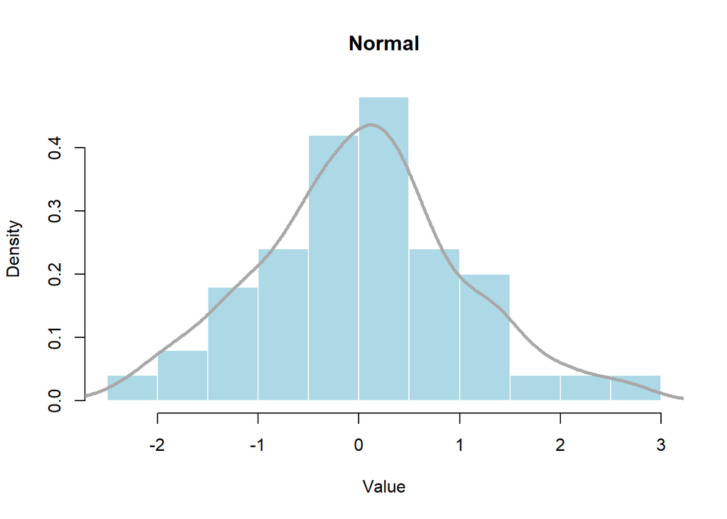

```r
hist(v_norm, probability = TRUE, col = "lightblue", border = "white", xlab = "Value", main = "Normal")
lines(density(v_norm), lwd = 3, col = "darkgrey")
```

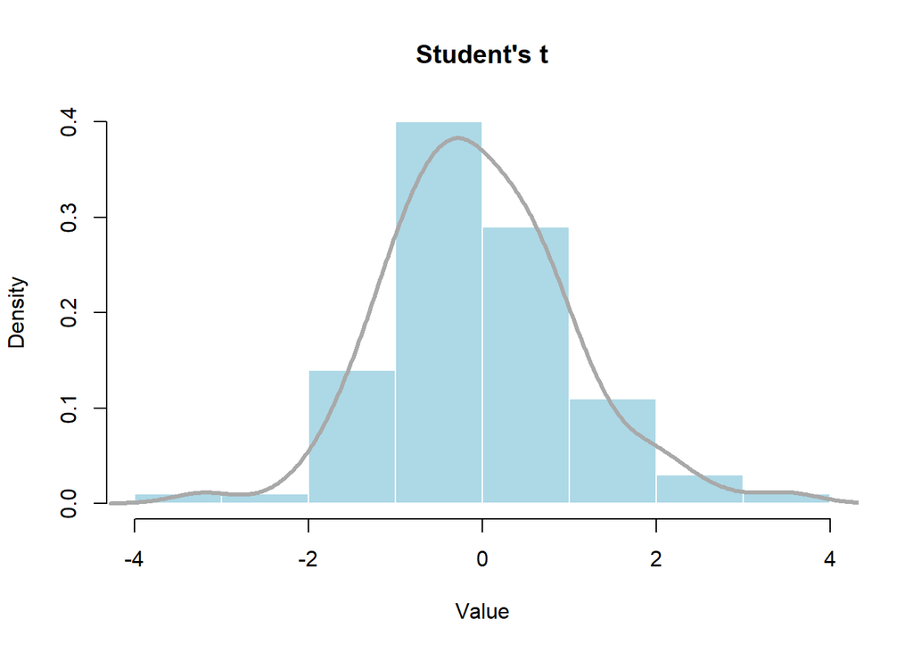

```r
hist(v_t, probability = TRUE, col = "lightblue", border = "white", xlab = "Value", main = "Student's t")
lines(density(v_t), lwd = 3, col = "darkgrey")
```

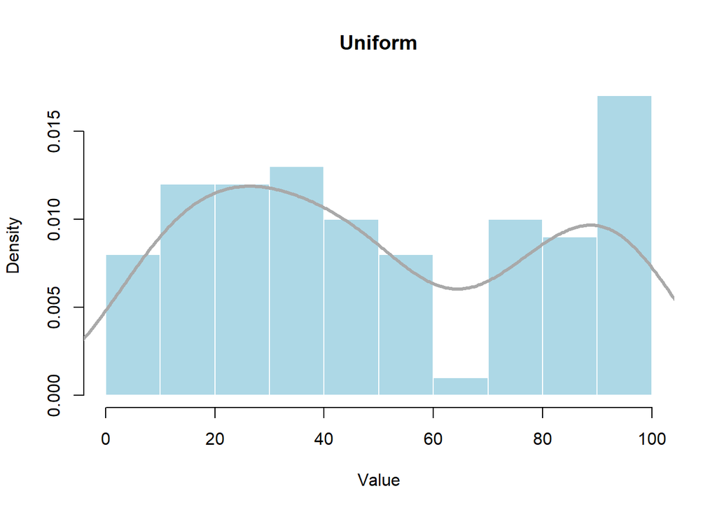

```r
hist(v_unif, probability = TRUE, col = "lightblue", border = "white", xlab = "Value", main = "Uniform")
lines(density(v_unif), lwd = 3, col = "darkgrey")
```

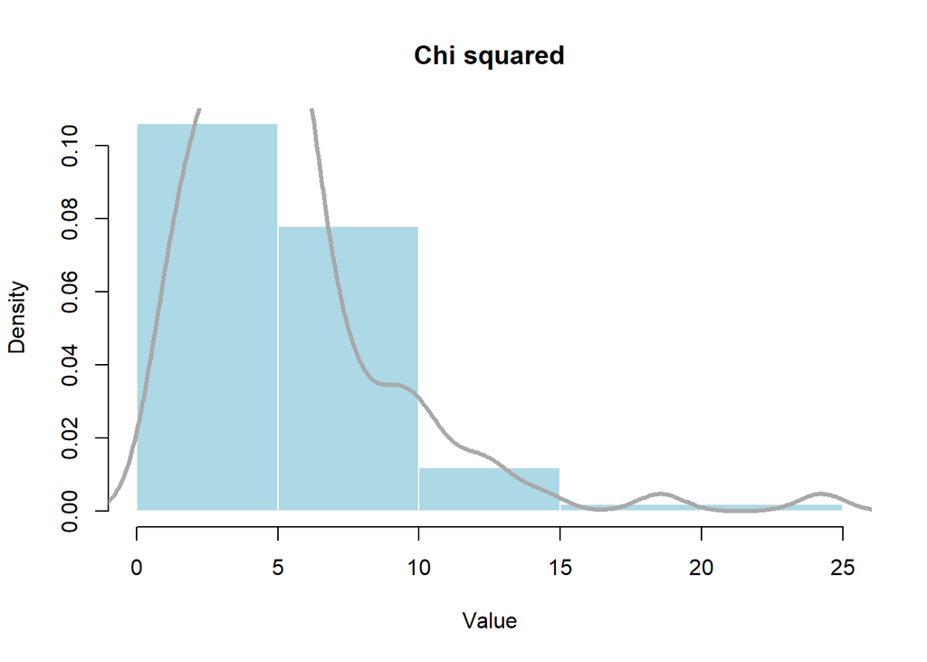

```r
hist(v_chi, probability = TRUE, col = "lightblue", border = "white", xlab = "Value", main = "Chi squared")
lines(density(v_chi), lwd = 3, col = "darkgrey")
```

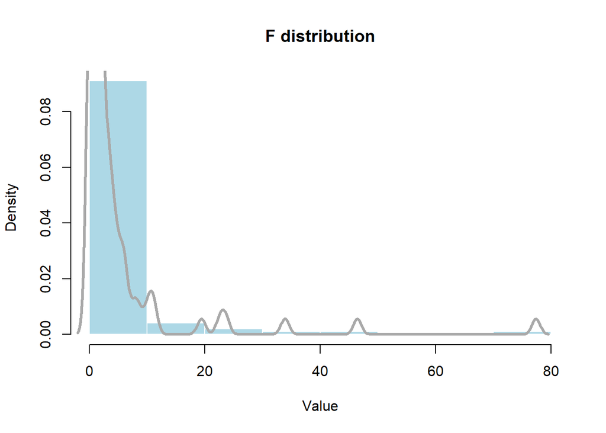

```r
hist(v_f, probability = TRUE, col = "lightblue", border = "white", xlab = "Value", main = "F distribution")
lines(density(v_f), lwd = 3, col = "darkgrey")
```

#### 4.1.4.3 Sampling

A sample refers to a subset of values from a vector that are drawn random. `sample(x, size, replace = FALSE, prob = NULL)` allows you to draw a random sample of size n, from a vector `x` . By default, sampling is done without replacement. In other words, an element can not appears twice in the sample unless it is included more than once in the vector x. In addition, all elements are equally likely to be drawn (`prop = NULL`). To illustrate this function, let’s use

```r
vec_1 <- seq(1:48)
```

and draw a sample, without replacement, of size = 10:

```r
sample(x = vec_1, size = 10)
```

```
 [1] 16 43 44 48 35 33 25 47 17 12
```

If you draw a sample with replacement (`replace = TRUE`), each draw is returned to the vector and could be drawn again.

```r
sample(x = vec_1, size = 10, replace = TRUE)
```

```
 [1] 26 10 47 10 37 42 46 27 23 33
```

Sampling is not limited to numeric vectors

```r
sample(x = c("a", "b", "c", "d", "e", "f", "g", "h"), size = 10, replace = TRUE)
```

```
 [1] "g" "d" "f" "e" "b" "c" "c" "g" "f" "d"
```

Without replacement, the sample size must be smaller than the length of the vector. With replacement, that is not the case. In the previous example for instance, the length of the vector was 8, while the size was 10. Without replacement, size = 8 would be equal to the vector and any size > 8 would not leave sufficient values to sample from. If some values in the sample need a higher probability of being drawn, you need to add a vector with probability weights.

As a special case, if you only include the vector `x`, R returns a random permutation of the vector’s values:

```r
x <- 1:10
sample(x)
```

```
 [1]  6  2  9  5  7  1  3 10  8  4
```

#### 4.1.4.4 Set operations

Using set operators, you determine if an element in one vector is also an element in another (`intersect`), if that is not the case (`setdiff`) or you merge the elements of both in one new vector (`union`)

Suppose you have two vectors,

```r
vec_1 <- c(10, 20, 30, 40)
vec_2 <- c(20, 30, 40, 40)
```

and you want to know if both share common elements. There are various ways to check if that is the case. The first uses the `intersect()` function. This function has two arguments: the vectors you want to compare. Note that if you load {dplyr}, the package masks this function. To instruct R to use base R’s intersect, you need to add ´base::`. The same holds for some other functions in this section.

```r
base::intersect(vec_1, vec_2)
```

```
[1] 20 30 40
```

The output shows the values that these two vectors have in common. If you want to store these values, out assign them to a new vector. Note that this also allows to see how many values both vectors have in common. Using the `length()` function, you can verify how many (unique) values are common to both vectors:

```r
length(base::intersect(vec_1, vec_2))
```

```
[1] 3
```

Here, we used numeric values, but it you can find common strings in character vectors in a similar way:

```r
friends <- c("Monica", "Phoebe", "Joey", "Chandler", "Ross", "Rachel")
collegues <- c("Taylor", "David", "Joey", "Sandra")
base::intersect(friends, collegues)
```

```
[1] "Joey"
```

This example also shows that the vectors don’t have to have the same length. If there are no common values, R will output the null vector:

```r
base::intersect(c(10, 20), c(50, 60))
```

```
numeric(0)
```

`is.element(x, y)` allows you to determine if elements of one vector, `x`, are included in the other `y`. The outcome is be a boolean vector whose values are TRUE if an element from `x` occurs in `y` and FALSE otherwise.

```r
is.element(vec_1, vec_2)
```

```
[1] FALSE  TRUE  TRUE  TRUE
```

The values in the last three columns in `vec_1` are also included in `vec_2`. Using the `%in%` operator has the same outcome as it checks which values on its left hand side vector are include in its right hand side vector:

```r
vec_1 %in% vec_2
```

```
[1] FALSE  TRUE  TRUE  TRUE
```

You can also use this result to see how many elements from the first vector are also in the second. Here, you use the fact that TRUE is also 1 and FALSE is 0:

```r
sum(is.element(vec_1, vec_2))
```

```
[1] 3
```

Note that the order of the vectors matters. If you use `is.element(x, y)` you check if the elements from `x` are included in `y`. With `is.element(y, x)` you determine the elements in `y` that are also in `x`. In the example, you can see that changing the order in the `is.element()` function shows a different output as 40 is included in `vec_2` twice, but is only once included in `vec_1`

```r
vec_1[is.element(vec_1, vec_2)]
```

```
[1] 20 30 40
```

```r
vec_2[is.element(vec_2, vec_1)]
```

```
[1] 20 30 40 40
```

Recall that using the “!” you can check if a condition is not met. Here, you can use this to see which elements of x are not in y

```r
!is.element(vec_1, vec_2)
```

```
[1]  TRUE FALSE FALSE FALSE
```

`base::setdiff(x y)` allows you to look for elements that are different, in other words, which elements from `x` are not included in `y`. While `!is.element(x, y)`’s output is a boolean vector, `base::setdiff()` shows the values of `x` that are not included in `y`.

```r
base::setdiff(vec_1, vec_2)
```

```
[1] 10
```

Note again that the order of the vectors matters.

If you want to know positions of the common elements, you can use the `which()` function:

```r
which(is.element(vec_1, vec_2))
```

```
[1] 2 3 4
```

The `unique(x, incomparables = FALSE)` function determines the unique values in a vector. Suppose that you have a vector

```r
vec_char <- c("jan", "jan", "feb", "mar", "mar", "apr")
```

This vector has 4 unique values: “jan”, “feb”, “mar” and “apr”. Using the `unique()` function, you can select the unique values:

```r
unique(x = vec_char)
```

```
[1] "jan" "feb" "mar" "apr"
```

If you want to exclude one value, you can add it to the `incomparables =` argument. For instance, suppose that you want to see all unique values, except January, you can add `incomparables = c("jan")`:

```r
unique(vec_char, incomparables = c("jan"))
```

```
[1] "jan" "jan" "feb" "mar" "apr"
```

R will now show all occurrences of “jan” as well as the unique values of all others.

To create a union of `x` and `y`, there is the `base::union(x, y)` function. This function shows the unique values after merging the values in `x` and `y`:

```r
base::union(vec_1, vec_2)
```

```
[1] 10 20 30 40
```

**CautionYour turn**

Generate a vector, `vec_rn` with 20 draws from a normal distribution with mean 5 and standard deviation 10

```r
 #| code-fold: true

vec_rn <- rnorm(20, mean = 5, sd = 10)
```

Generate a vector, `vec_ru` with 20 draws from a uniform distribution with minimum 5 and maximum 10. Write this code without naming the arguments.

```r
vec_ru <- runif(20, 5, 10)
```

Using `vec_rn` draw a sample of 6 observations with replacement and assign these to a vector `vec_rns`

```r
vec_rns <- sample(vec_rn, size = 6, replace = TRUE)
```

A lottery includes a weekly draw of 6 numbers, without replacement, from a bowl with all numbers from 1 to 40. To play, you buy a ticket with 6 numbers, from 1 to 40. You win something if at least two numbers on your ticket are drawn. Your numbers are 3, 9, 25, 36, 37, 39. Simulate this lottery. To do so, first sample the weekly draw. Second, determine how many of your numbers match the numbers of the draw. Use 3 ways to calculate the number of winning numbers.

```r
draw <- sample(1:40, 6, replace = FALSE)
ticket <- c(3, 9, 25, 36, 37, 39)

# Option 1: use intersect
win <- length(intersect(draw, ticket))
win
```

```
[1] 1
```

```r
# Option 2: use is.element
win <- sum(is.element(ticket, draw))
win
```

```
[1] 1
```

```r
# Option 3: use %in%
win <- sum(ticket %in% draw)
win
```

```
[1] 1
```

### 4.1.5 Special vectors

R includes a number of special vectors. For instance, the vectors “letters” and “LETTERS” include the letters of the alphabet. The first lowercase, the second uppercase

```r
letters
```

```
 [1] "a" "b" "c" "d" "e" "f" "g" "h" "i" "j" "k" "l" "m" "n" "o" "p" "q" "r" "s"
[20] "t" "u" "v" "w" "x" "y" "z"
```

```r
LETTERS
```

```
 [1] "A" "B" "C" "D" "E" "F" "G" "H" "I" "J" "K" "L" "M" "N" "O" "P" "Q" "R" "S"
[20] "T" "U" "V" "W" "X" "Y" "Z"
```

In addition to letters, the vectors “month.abb” and ’month.name” include the names of the month:

```r
month.abb
```

```
 [1] "Jan" "Feb" "Mar" "Apr" "May" "Jun" "Jul" "Aug" "Sep" "Oct" "Nov" "Dec"
```

```r
month.name
```

```
 [1] "January"   "February"  "March"     "April"     "May"       "June"
 [7] "July"      "August"    "September" "October"   "November"  "December"
```

### 4.1.6 Subsetting a vector

If you subset a vector, you select one or more columns of that vector (to possibly store them in a new one). We first start with the general case: an unnamed vector. We then continue with the special case of a named vector. Note that all methods for an unnamed vector can be used for named vectors.

#### 4.1.6.1 Subsetting an unnamed vector

Here, we will use the numeric vector `vec_num`:

```r
vec_num <- c(0, 1, 1, 2, 3, 5, 8, 13, 21, 34)
```

Note that you can apply most of these ways to subset to other vector types: character, data/time or logical vectors. The approach wouldn’t differ in case you would use any of these other vector types. There are two subset operators: `[]` and `[[ ]]`.

##### 4.1.6.1.1 Subsetting by position

To access an individual element of a vector, you include its position (or index number) between the square brackets of the subscript operator `[]` after the name of the vector. In R, vector indexing starts at 1. In other words, the first element of a 1x10 vector is at position 1, the second at position 2, … This is not always the case. In Python for instance, the first element of a vector is at position 0, the second at position 1, …

Let’s look at the element 5 of the element in the fifth column of `vec_num`:

```r
vec_num[5]
```

```
[1] 3
```

If you want to extract that element to use it in part of your code, you would assign it to a different vector using the `<-` operator:

```r
a <- vec_num[5]
a
```

```
[1] 3
```

Note that subsetting leaves the original vector intact. If you subset a vector, you copy the value in a new vector, but that value stays in the original vector.

You can subset more than one column. Suppose that you want to subset columns 1 to 4. To do so, you can use `1:4` within the subscript operator:

```r
vec_num[1:4]
```

```
[1] 0 1 1 2
```

Again, you could assign this new vector. Here, this new vector would have 1 row and 4 columns. These 4 columns would be equal to the first 4 columns of the original vector.

The third way to access elements in a vector using their position is to combine these position via the `c()` function within the subsetting operator. The `c()` function allows you to define the columns you need. The subscript operator will then access these columns and extract their value. Suppose that you want to extract the elements in columns 1 and 4. Note that here, you will extract to columns: 1 and 4. In the previous example you extracted 4 columns: 1 to 4 or column 1, 2, 3, and 4. To extract columns 1 and 4 you need to include those position in the `c()` function: `c(1, 4)` and use:

```r
vec_num[c(1, 4)]
```

```
[1] 0 2
```

Note that you can mix various ways to subset a vector. For instance, if you need the first to third, fifth and seventh to last element, you can combine the various way to subsetting the vector:

```r
vec_num[c(1:3, 5, 7:10)]
```

```
[1]  0  1  1  3  8 13 21 34
```

##### 4.1.6.1.2 Subsetting using negative positions

You can also use negative numbers for the index elements. In that case, R will show all elements, except those in the negative index (negative index range). For instance,

- Accessing all elements except for the first:

```r
vec_num[-1]
```

```
[1]  1  1  2  3  5  8 13 21 34
```

- Accessing all elements except for the first, second, third and fourth (all in that range):

```r
vec_num[-1:-4]
```

```
[1]  3  5  8 13 21 34
```

- Accessing all elements except for the second and fourth:

```r
vec_num[(c(-2, -4))]
```

```
[1]  0  1  3  5  8 13 21 34
```

```r
vec_num[-c(2, 4)]
```

```
[1]  0  1  3  5  8 13 21 34
```

##### 4.1.6.1.3 Subsetting by using a logical vector

The fourth way to subset columns of a vector uses a logical vector of the same length as the vector to subset. The logical vector’s elements are `TRUE` or `FALSE`. This logical vector will subset the elements of the other vector if its value if `TRUE`. To see how this works, let’s first define two vectors: one numeric and one logical:

```r
vec_1 <- c(1, 2, 3, 4, 5)
vec_log <- c(TRUE, FALSE, FALSE, FALSE, TRUE)
```

You can now subset `vec_1` using `vec_log`:

```r
vec_1[vec_log]
```

```
[1] 1 5
```

If the value on position x in `vec_log` is `TRUE`, the result of `vec_1[vec_log]` is equal to the value in the xth column of `vec_1`. This is the case for the first and last value. If `vec_log`’s yth element is `FALSE`, `vec_1`’s yth element is not extracted.

```r
cond <- vec_num > 5
cond
```

```
 [1] FALSE FALSE FALSE FALSE FALSE FALSE  TRUE  TRUE  TRUE  TRUE
```

Now we have a logical vector `cond` whose values are `TRUE` if the element in the same position in `vec_num` meets the condition (> 5) and `FALSE` otherwise. We can now use this vector to subset `vec_num`:

```r
vec_num[cond]
```

```
[1]  8 13 21 34
```

Here, the TRUE-FALSE elements of `cond` are used to subset `vec_num`. Is an element in `cond` is TRUE, `vec_num[cond]` extracts that element from `vec_num`. If the element in `cond` is FALSE, the element in the same position in `vec_num` is not extracted.

The second option to use a condition is shorter and uses the condition within the subscript operator:

```r
vec_num[vec_num > 5]
```

```
[1]  8 13 21 34
```

Note that you can use more than one boolean operator. For instance extracting all elements larger than 3 and not equal to 13 can be done using:

```r
cond <- vec_num > 3 & !(vec_num == 13)
vec_num[cond]
```

```
[1]  5  8 21 34
```

or

```r
vec_num[vec_num > 3 & !(vec_num == 13)]
```

```
[1]  5  8 21 34
```

Note that you can use these conditions also in the case of character vectors. For instance, to see if “cat” and “dog” are values in `vec_char`:

```r
vec_char[vec_char == "dog" | vec_char == "cat"]
```

```
character(0)
```

If you don’t know the exact location and you don’t have an explicit condition that you can use, but you know which values you want to extract, you can use the `%in%` operator. Here, you first define a vector with values, e.g. 1, 8 and 143 using `c(1, 8, 143)`. Using the `%in%` operator, you can now subset the vector `vec_num`:

```r
vec_num %in% c(1, 8, 143)
```

```
 [1] FALSE  TRUE  TRUE FALSE FALSE FALSE  TRUE FALSE FALSE FALSE
```

This code extract all elements from `vec_num` that are also in `c(1, 8, 143)`. The result of this operation is a logical vector with the same length as `vec_num` where the elements equal `TRUE` is an element in `vec_num` is included in `c(1, 8, 143)` and `FALSE` otherwise. This vector now allows you to extract these elements using, e.g.

```r
vec_num[vec_num %in% c(1, 8, 143)]
```

```
[1] 1 1 8
```

As an alternative, you can do so in two steps:

```r
cond <- vec_num %in% c(1, 8, 143)
vec_num[cond]
```

```
[1] 1 1 8
```

Here we included the elements to extract in a `c()` function. However, you can use any other vector.

```r
a <- c(1, 8, 143)
vec_num[vec_num %in% a]
```

```
[1] 1 1 8
```

Note that you can include values in `%in% c()` which are not part of the vector. If this is the case, R won’t find them. Hence, adding them wouldn’t change the outcome. If no element in the original vector matches the condition, R will output `numeric(0)` or a vector of length 0.

To illustrate this and the use of `%in%` for a character vector, suppose you want to extract “dog”, “fish” from `vec_char`:

```r
vec_char <- c("dog", "cat", "rabbit")
vec_char[vec_char %in% c("dog", "fish")]
```

```
[1] "dog"
```

As “fish” is not included in `vec_char` but “dog” is and “rabbit” is part of `vec_char` but isn’t in `c("dog", "fish")`, R outputs “dog”.

Using `is.element()`, you can subset a vector (the first) and extract all values that are both the the first and the second vector. To illustrate:

```r
vec_1 <- c(1:10)
vec_2 <- c(7:15)
vec_1[is.element(vec_1, vec_2)]
```

```
[1]  7  8  9 10
```

Boolean operators allow you define many conditions. For instance, if you have a vector that includes missing values, you can extract all non missing values using `!is.na()` or is not (`!`) NA:

```r
vec_1 <- c(1, 20, 20, NA, NA, 50)
vec_1[!is.na(vec_1)]
```

```
[1]  1 20 20 50
```

As a second example, suppose that you want to extract all even numbers. Recall that a number is even if the modulus after division by 2 is zero:

```r
10 %% 2
```

```
[1] 0
```

```r
11 %% 2
```

```
[1] 1
```

You can use this to create a condition

```r
10 %% 2 == 0
```

```
[1] TRUE
```

```r
11 %% 2 == 0
```

```
[1] FALSE
```

that you can use to subset elements of a vector:

```r
cond <- vec_num %% 2 == 0
vec_num[cond]
```

```
[1]  0  2  8 34
```

As a third example, recall that you can use `grepl()` or `stringr::string_detect()` if a pattern occurs in a string. If the is the case, these function output `TRUE` and `FALSE` otherwise. Suppose you have a character vectors

```r
vec_char <- c("sales_shoes", "sales_trousers", "sales_shirts", "sales_jackets")
```

and you want to extract the column which includes “shoes”. Using `grepl()` you can identify the elements in the character vector that include the word “shoes”:

```r
grepl(pattern = "shoes", x = vec_char)
```

```
[1]  TRUE FALSE FALSE FALSE
```

You can use this function to extract the element “sales_shoes” from `vec_char`.

```r
vec_char[grepl(pattern = "shoes", x = vec_char)]
```

```
[1] "sales_shoes"
```

##### 4.1.6.1.4 Index positions

In all examples we either used an exact index position or a logical vector to extract the values of a vector. What if you are not interested in a value but in an index position? To show an index position rather than its value or `TRUE` or `FALSE`, you can use the `which()` function. For instance, suppose you want to know the position of value 1 in `vec_num`. To find this position, you can use

```r
which(vec_num == 1)
```

```
[1] 2 3
```

The result shows the index positions where you can find 1 in `vec_num`. Note that you can save the output in a new vector with positions. You can now subset that vector to find the first occurrence. As an alternative, as `which()` outputs a vector, you can find the first occurrence by subsetting the `which()` function. For instance, to find the first 1 in `vec_num`:

```r
which(vec_num == 1)[1]
```

```
[1] 2
```

What if you want to find multiple values. Here, you can use the `%in%` operator. Suppose you want to know the position of the values 1, 2, 8 and 55. First you collect these values in a vector using `c(1, 2, 8, 55)`. You can now use that vector in the `which()` function:

```r
which(vec_num %in% c(1, 2, 8, 55))
```

```
[1] 2 3 4 7
```

`which()` shows every occurrence. Using `match()` you can find the first occurrence. For instance, the first occurrence of “1” in `vec_num` is in position

```r
match(1, vec_num)
```

```
[1] 2
```

Using `which()` allows you to extract the positions of e.g. missing values. Suppose you have a vector `vec_1` which includes missing values:

```r
vec_1 <- c(10, 10, 20, NA, 30, 40, NA, 50, 50)
```

To locate these missing value, you can use

```r
which(is.na(vec_1), vec_1)
```

```
[1] 4 7
```

There are two variants of the `which()` function that allow you to find the location of the (first) maximum or minimum values: `which.max()` and `which.min`:

```r
which.max(vec_1)
```

```
[1] 8
```

```r
which.min(vec_1)
```

```
[1] 1
```

Using locigal values, you can find the first occurrence of specific value. Here, `which.max()` uses the fact that `TRUE` = 1 and `FALSE` = 0. In other words, this function will show the first occurrence of `TRUE`:

```r
which.max(vec_1 > 30)
```

```
[1] 6
```

#### 4.1.6.2 Subsetting a named vector

With a named vector, you can also use the column names to subset. Suppose that you have a vector

```r
vec_1 <- c(A = 10, B = 30, C = 50, D = 70)
```

First you can use the ways you would use to subset an unnamed vector, e.g.

```r
vec_1[3]
vec_1[2:4]
vec_1[vec_1 < 50]
```

[output not shown]

As you can see using `[]` preserves the structure of the vector: the output shows both the column name as well as its value.

You can also use the name of the column to subset the vector using `vec_1["column name"]`:

```r
vec_1["A"]
```

```
 A
10
```

The output shows both the column name as well as the value. In other words, here too, the structure of the vector is preserved.

To subset more than one column, you can use

```r
vec_1[c("A", "D")]
```

```
 A  D
10 70
```

To extract the value, you have to refer to the column using subsetting operator `[[ ]]`. Recall from Chapter 2 that this subsetting operator does not preserve the data structure and tries to simplify as much as possible. With a vector, this will cause R to drop the column name from the output. You can use this operator with both the column name or number. These lines extract the value for the second column

```r
vec_1[["B"]]
```

```
[1] 30
```

```r
vec_1[[2]]
```

```
[1] 30
```

The output shows the value without the column. The `[[ ]]` operator simplifies the structure of the vector: it returns the simplest possible data structure: here this is the value of the column, i.e. an unnamed vector.

You can also subset columns whose name includes a pattern. Recall that `names()` allow you to extract the names of the columns in a named vector. Using `grepl()` you can check if these names include a pattern. For instance, let’s check if the names of `vec_1` include “A”. Using `grepl()`:

```r
grepl(pattern = "A", x = names(vec_1))
```

```
[1]  TRUE FALSE FALSE FALSE
```

To extract that column, you include that statement in `vec_1[]`:

```r
vec_1[grepl(pattern = "A", x = names(vec_1))]
```

```
 A
10
```

The result shows the name of the column and its value.

**CautionYour turn**

Generate a vector:

```r
vec <- c(21:30)
```

Extract the following elements from this vector:

- the 5th element

```r
vec[5]
```

```
[1] 25
```

- all elements from 1 to 5

```r
vec[1:5]
```

```
[1] 21 22 23 24 25
```

- elements in columns 1, 3 and 9

```r
vec[c(1, 3, 9)]
```

```
[1] 21 23 29
```

- all elements except columns 1, 3 and 9

```r
vec[-c(1, 3, 9)]
```

```
[1] 22 24 25 26 27 28 30
```

- all elements larger than 25

```r
vec[vec > 25]
```

```
[1] 26 27 28 29 30
```

Use this vector

```r
vecchar <- c("dog", "fish", "cat", "bird", "duck", "rabbit")
```

to extract all patterns animals that whose name includes an “a”

```r
vecchar[grepl(pattern = "a", vecchar)]
```

```
[1] "cat"    "rabbit"
```

### 4.1.7 Adding, removing and changing elements to a vector

#### 4.1.7.1 Adding elements to a vector

As in the previous section, I’ll use a numeric vector here, but you can apply the rules also to other types of vectors. Suppose that you have the 1x10 vector `vec_num` and you want to add a column with the value 55. The first way to do so is to use the `c()` function to create a new vector

```r
c(vec_num, 55)
```

```
 [1]  0  1  1  2  3  5  8 13 21 34 55
```

In this way you can add multiple columns and or multiple vectors:

```r
c(vec_num, c(55, 89, 144), c(233, 377, 610))
```

```
 [1]   0   1   1   2   3   5   8  13  21  34  55  89 144 233 377 610
```

`c()` adds all elements in the order in which they appear in the function:

```r
c(c(610, 377, 233), c(144, 89, 55), vec_num)
```

```
 [1] 610 377 233 144  89  55   0   1   1   2   3   5   8  13  21  34
```

Note that this doesn’t change the `vec_num`. `c()`creates a new vector. If you want to change `vec_num` you have to reassign it to the new vector. As an alternative, you can assign the new vector to a new object:

```r
vec_1 <- c(vec_num, c(55, 89, 144), c(233, 377, 610))
vec_1
```

```
 [1]   0   1   1   2   3   5   8  13  21  34  55  89 144 233 377 610
```

If you have a named vector, you can add a new named vector:

```r
vec_1 <- c(A = 10, B = 30, C = 50, D = 70)
c(vec_1, c(E = 90))
```

```
 A  B  C  D  E
10 30 50 70 90
```

You can also use the `append()` function to add new elements. By default, append will add an element after the last element in the existing vector. In other words, by default, `append()` is similar to `c()`. However, the arguments in the `append(vector, value, after = length(x))` allow you to change that default position. If you want to add the new element after position 3, you can add this by changing the default `length(x)` in 3. Note that `append()`doesn’t change the original vector:

```r
append(vec_num, 55)
```

```
 [1]  0  1  1  2  3  5  8 13 21 34 55
```

```r
vec_num
```

```
 [1]  0  1  1  2  3  5  8 13 21 34
```

If you want to change the original vector, you have to reassign it to its new values or assign the outcome to a new object:

```r
vec_1 <- append(vec_num, 144)
vec_1
```

```
 [1]   0   1   1   2   3   5   8  13  21  34 144
```

To add the value 88 as the first element or 143 after column 9, you can change the default location in `append()`’s `after =` argument:

```r
append(vec_num, 88, after = 0)
```

```
 [1] 88  0  1  1  2  3  5  8 13 21 34
```

```r
append(vec_num, 143, after = 9)
```

```
 [1]   0   1   1   2   3   5   8  13  21 143  34
```

Using the `c()` function, you can add multiple elements. For instance, if you want to add 88 and 143 as the first two columns of `vec_num` you combine these two values within `c()` and include them in the append statement:

```r
append(vec_num, c(88, 143), after = 0)
```

```
 [1]  88 143   0   1   1   2   3   5   8  13  21  34
```

Note that you can change the position where these new values are added. However, all elements are added after the same position and their position follows their position within the `c()` function. Note also that, if you add an element whose type of different from the vector type, R will change the vector type.

You can also add a named vector

```r
append(vec_1, c(E = 50), after = 0)
```

```
  E
 50   0   1   1   2   3   5   8  13  21  34 144
```

#### 4.1.7.2 Removing elements from a vector

There are multiple ways to remove elements from a vector. We already covered two. First, if you know the position of the elements you want to remove, you can use a negative index. Recall that a negative index allows you to extract the elements of a vector except those included in the negative index. For instance, if you want to remove the first 4 columns of `vec_num` you can do this using

```r
vec_num[-1:-4]
```

```
[1]  3  5  8 13 21 34
```

```r
vec_num[-c(1, length(vec_num))]
```

```
[1]  1  1  2  3  5  8 13 21
```

or

```r
vec_num[c(-1, -length(vec_num))]
```

```
[1]  1  1  2  3  5  8 13 21
```

You can use this approach if you know the exact location (i.e. the columns) who want to remove.

The second way to remove elements uses a condition. For instance, the code to remove all elements larger than 3 and not equal to 0 is

```r
vec_num[!vec_num > 3 & !(vec_num == 0)]
```

```
[1] 1 1 2 3
```

or, using a specific vector including the condition:

```r
cond <- !vec_num > 3 & !(vec_num == 0)
vec_num[cond]
```

```
[1] 1 1 2 3
```

You can use this approach if you know the condition that elements need to meet.

If you want to remove known values from a vector, e.g. 1, 8 and 143, you can use an approach which is very similar to the one you used to subset these elements. First, you collect them in a vector `c(1, 8, 143)`. Second, you use `%in%` and not (`!`) to remove these elements:

```r
cond <- vec_num %in% c(1, 8, 143)
vec_num[!cond]
```

```
[1]  0  2  3  5 13 21 34
```

or, in one line of code

```r
vec_num[!vec_num %in% c(1, 8, 143)]
```

```
[1]  0  2  3  5 13 21 34
```

In the last statement, 143 was included in the vector with values to remove but is not in `vec_num`. R doesn’t check if all values to be removed are also in the vector where they need to be removed.

#### 4.1.7.3 Changing elements in a vector

Suppose that you know which column you want to change in your vector, e.g. you want to change the value in 4th column. To do this, you first subset that element using `vec_num[4]` and your reassign its value. For instance, changing the fourth element to 250:

```r
vec_num[4] <- 250
vec_num
```

```
 [1]   0   1   1 250   3   5   8  13  21  34
```

As you can see, fourth element is now 250. Note that the new value needs to be of the same type as the vector. If that is not the case, you”ll change the type of all other elements in the vector. For instance

```r
vec_num[4] <- "250"
```

changes the type of the vector from double to character:

```r
typeof(vec_num)
```

```
[1] "character"
```

In that case, you have to change the vector’s type:

```r
vec_num <- as.numeric(vec_num)
```

Using `replace()` you can change many values in a vector. Suppose you want to change columns 1, 8 and 10 in 50, 100, 150. The first argument in the `replace()` function is the vector you want to change. Here, this is `vec_num`. The second argument is a vector with index position. Using `c(1, 8, 10)` you can fix these position. The last argument is a vector with the values that will be used to replace the values in the index positions. Here you would use `c(50, 100, 150)`. Using these in the `replace()` function:

```r
replace(vec_num, c(1, 8, 10), c(50, 100, 150))
```

```
 [1]  50   1   1 250   3   5   8 100  21 150
```

```r
replace(vec_num, c(1, 8, 10), c(50, 100, 150, 200))
```

```
 [1]  50   1   1 250   3   5   8 100  21 150
```

If you want to replace all values that meet a certain condition with one single value, you can use the `replace()` function as well. Suppose you want to change all values larger than 25 with 50. Using `recplace()` you could do this with:

```r
replace(vec_num, vec_num > 25, 50)
```

```
 [1]  0  1  1 50  3  5  8 13 21 50
```

Changing the vector’s type is another way to change a vector. Suppose you have a vector

```r
vec_dat_char <- c("01-01-2025", "02-01-2025", "03-01-2025")
```

This vector is a character vector:

```r
typeof(vec_dat_char)
```

```
[1] "character"
```

You can change this type to Date or POSIX using `as.Date()` or `as.POSIXct()`. Using the first:

```r
as.Date(vec_dat_char, format = "%d-%m-%Y")
```

```
[1] "2025-01-01" "2025-01-02" "2025-01-03"
```

In a similar way, you can change the typeof numeric variables in character, dates in numeric, … .

#### 4.1.7.4 Sorting vectors

To sort a vector, R includes the `sort(x, decreasing = FALSE, na.last = NA)` function. Here, x is the vector to sort. By default, R sorts in increasing order. The last argument includes the treatement of “NA” values. By default, they are removed. Using `TRUE` missing values are retained, but added last. `FALSE` shows these values first.

```r
sort(x = vec_num, decreasing = FALSE)
```

```
 [1]   0   1   1   3   5   8  13  21  34 250
```

Character vectors are sorted alphabetically by default:

```r
sort(x = c("zoo", "Zoo", "coast", "coAst", "cOAst", "lake"))
```

```
[1] "coast" "coAst" "cOAst" "lake"  "zoo"   "Zoo"
```

As you can see, if the strings include copies where one includes an uppercase letter and the other one doesn’t, R orders those with the lowest number of uppercase letters first.

**CautionYour turn**

Generate a vector:

```r
vec <- c(21:30)
```

Change the this vector

- add a `c(31, 32, 33, 34, 34)` after the vast position in `vec`. Use two methods to do so. Store the results in `vec_r`:

```r
# Option 1: use c()
vec_r <- c(vec, c(31, 32, 33, 34, 34))
vec_r
```

```
 [1] 21 22 23 24 25 26 27 28 29 30 31 32 33 34 34
```

```r
# Option 2: use append()
vec_r <- append(vec, c(31, 32, 33, 34, 34))
vec_r
```

```
 [1] 21 22 23 24 25 26 27 28 29 30 31 32 33 34 34
```

```r
# Option 1: use c()
vec_r <- c(c(31, 32, 33, 34), vec)
vec_r
```

```
 [1] 31 32 33 34 21 22 23 24 25 26 27 28 29 30
```

```r
# Option 2: use append() and add position
vec_r <- append(vec, c(31, 32, 33, 34), after = 0)
vec_r
```

```
 [1] 31 32 33 34 21 22 23 24 25 26 27 28 29 30
```

- add `c(31, 32, 33, 34, 34)` after the fifth element of `vec`. Store the results in `vec_r`:

```r
vec_r <- append(vec, c(31, 32, 33, 34, 34), after = 5)
vec_r
```

```
 [1] 21 22 23 24 25 31 32 33 34 34 26 27 28 29 30
```

Using `vec_r` you created in the last exercise:

- remove the columns 6 to 10

```r
vec_r <- vec_r[-6:-10]
vec_r
```

```
 [1] 21 22 23 24 25 26 27 28 29 30
```

- change the firth column to 250

```r
vec_r[5] <- 250
```

- replace the values on position 1, 2 and 3 with 210, 220 and 230, store the result in `vec_r`.

```r
vec_r <- replace(vec_r, c(1, 2, 3), c(210, 220, 230))
vec_r
```

```
 [1] 210 220 230  24 250  26  27  28  29  30
```

- replace all elements smaller than 100 with 100

```r
replace(vec_r, vec_r < 100, 100)
```

```
 [1] 210 220 230 100 250 100 100 100 100 100
```

Using `vec`, sort this vector in decreasing and increasing order.

```r
sort(vec, decreasing = TRUE)
```

```
 [1] 30 29 28 27 26 25 24 23 22 21
```

```r
sort(vec)
```

```
 [1] 21 22 23 24 25 26 27 28 29 30
```

### 4.1.8 Functions and vectors

Many operations in R are vectorized. This means that an operator works on a vector’s individual elements. For functions, that means that R, for most of them, applies them to every element of that vector.

#### 4.1.8.1 Numeric vectors

We introduced mathematical operators and function, statistical function and e.g. rounding in the previous chapter. Almost all these are vectorized. All operators and function generate output. In you want to store these results you have to assign them to a new object. Here this object is usually a vector. In the examples this assignment is left out to keep code short.

##### 4.1.8.1.1 Mathematical operators and functions

Let’s first create a vector, `vec_num1` and `vec_num2`

```r
vec_num1 <- c(10, 10, 20, 30, 50, 80, 130, 210, 340, 550)
vec_num2 <- c(1, 1, 2, 3, 5, 8, 13, 21, 34, 55)
```

If you add or subtract a numeric value to or from a vector or if you multiply that numeric vector with or divide it by a numeric value, R applies this operation to every element of the vector. For instance

- addition:

```r
vec_num1 + 100
```

```
 [1] 110 110 120 130 150 180 230 310 440 650
```

- subtraction:

```r
vec_num1 - 100
```

```
 [1] -90 -90 -80 -70 -50 -20  30 110 240 450
```

- multiplication:

```r
vec_num1 * 10
```

```
 [1]  100  100  200  300  500  800 1300 2100 3400 5500
```

- division:

```r
vec_num1 / 25
```

```
 [1]  0.4  0.4  0.8  1.2  2.0  3.2  5.2  8.4 13.6 22.0
```

- integer division:

```r
vec_num1 %/% 3
```

```
 [1]   3   3   6  10  16  26  43  70 113 183
```

- modulus:

```r
vec_num1 %% 3
```

```
 [1] 1 1 2 0 2 2 1 0 1 1
```

Applied to two vectors of the same length, R add, subtracts, multiplies or divides each element in one vector to/from/with the corresponding element in the other vector:

- addition:

```r
vec_num1 + vec_num2
```

```
 [1]  11  11  22  33  55  88 143 231 374 605
```

- subtraction:

```r
vec_num1 - vec_num2
```

```
 [1]   9   9  18  27  45  72 117 189 306 495
```

- multiplication:

```r
vec_num1 * vec_num2
```

```
 [1]    10    10    40    90   250   640  1690  4410 11560 30250
```

- division:

```r
vec_num1 / vec_num2
```

```
 [1] 10 10 10 10 10 10 10 10 10 10
```

- integer division:

```r
vec_num1 %/% vec_num2
```

```
 [1] 10 10 10 10 10 10 10 10 10 10
```

- modulus:

```r
vec_num1 %% vec_num2
```

```
 [1] 0 0 0 0 0 0 0 0 0 0
```

Note that this save a lot of work. Without vectorization, to add two vectors, you would have to write some code, e.g.:

```r
if (length(vec_num1) != length(vec_num2)) {
  print("Can not add vectors of a different length")
} else {
  vec_num4 <- vector("numeric", length = length(vec_num1))
  for (i in 1:length(vec_num1)) {
    vec_num4[i] <- vec_num1[i] + vec_num2[i]
   }
}
vec_num4
```

```
 [1]  11  11  22  33  55  88 143 231 374 605
```

For functions, let’s illustrate vectorisation using the of `vec_num1`. All functions where introduced in previous sections.

- absolute value:

```r
abs(-vec_num1)
```

```
 [1]  10  10  20  30  50  80 130 210 340 550
```

- logarithm base e (natural logarithm):

```r
log(vec_num1)
```

```
 [1] 2.302585 2.302585 2.995732 3.401197 3.912023 4.382027 4.867534 5.347108
 [9] 5.828946 6.309918
```

- logarithm base 10:

```r
log10(vec_num1)
```

```
 [1] 1.000000 1.000000 1.301030 1.477121 1.698970 1.903090 2.113943 2.322219
 [9] 2.531479 2.740363
```

```r
log(vec_num1, base = 10)
```

```
 [1] 1.000000 1.000000 1.301030 1.477121 1.698970 1.903090 2.113943 2.322219
 [9] 2.531479 2.740363
```

- square root:

```r
sqrt(vec_num1)
```

```
 [1]  3.162278  3.162278  4.472136  5.477226  7.071068  8.944272 11.401754
 [8] 14.491377 18.439089 23.452079
```

- power, e.g. 2:

```r
vec_num1^2
```

```
 [1]    100    100    400    900   2500   6400  16900  44100 115600 302500
```

- exponent (e to the power n (n = element of the vector):

```r
exp(vec_num1)
```

```
 [1]  2.202647e+04  2.202647e+04  4.851652e+08  1.068647e+13  5.184706e+21
 [6]  5.540622e+34  2.872650e+56  1.591627e+91 4.572186e+147 7.277212e+238
```

##### 4.1.8.1.2 Other usefull vector functions

Although R has many useful vector functions, I’ll introduce a couple of them here. To illustrate what they do, we’ll use

```r
vec_num1 <- c(1, 2, 3, 4, 3, 2, 1)
```

`cumsum(x)` shows the cumulative sum of a vector. It’s first element is the first element of x; its second element is the sum of its first element and the second element of x; the third equals its second element (or the sum of the first two elements in x) plus the third element of x, … . If one of the elements is a missing value (NA), the rest of the sum will be set to NA.

```r
cumsum(vec_num1)
```

```
[1]  1  3  6 10 13 15 16
```

As you can see, the second element is equal to 2 + 1, the first two elements in x. The third element, 6, is equal to the second element in the cumulative sum (3) and the third element in `vec_num1` … .

`cumprod(x)` is a similar function but calculates the cumulative product.

```r
cumprod(vec_num1)
```

```
[1]   1   2   6  24  72 144 144
```

`cummax(x)` and `cummin(x)` produce a vector with cumulative maximum and minimum values. The first starts with the first observation in x and use this as their first element. If the second elemen in x is larger than the first, the second element in the output vector for the `cummax()` function will equal that value; else is will equal its first value. The function then evaluates the third element in x. If that element is larger then the second element in the output vector for `cummax()` the third element in the `cummax()` vector will be that third element in the x vector; else the third element in the `cummax()` vector equals its second element. To see how this works:

```r
cummax(vec_num1)
```

```
[1] 1 2 3 4 4 4 4
```

As you can see, the first element is 1. As the second element in `vec_num1` is 2, this is a new maximum and the `cummax()` vector’s second element in 2? The same holds for the third element in `vec_num1`: it is larger than the second element in the `cummax()` vector, so this is a new maximum. The third element in the `cummax()` vector shows this. After the fourth element, all elements in `vec_num1` are smaller then its maximum value. In the `cummax()` vector, the maximum is now stable.

`cummin()` is similar, but sets the minimum:

```r
cummin(vec_num1)
```

```
[1] 1 1 1 1 1 1 1
```

The {purrr} package includes a function `reduce()` which is very useful with vectors. This function reduces elements of a vector in a single value using a 2-argument function that passes the accumulated value as this functions second argument. The `cumsum()` and `cumprod()` function’s last value equal the sum and product of all elements in the vector but also shows all intermediate cumulative sums. You can calculate that final value using `purrr::reduce(.x, .f, ..., .init, .dir = c("forward", "backward"))`. The first argument, `.x` is an atomic vector. The second argument `.f` is a function that will be used across elements. This function needs to arguments: the first is an element from the vector; the second is the accumulated values from the previous step. The arguments `.init` and `.dir = c("forward", "backward")` show the initial value and the direction of the reduction with “forward” being the default. The default value for the initial value is the first element of x. To calculate the cumulative sum using this function:

```r
purrr::reduce(vec_num1, .f = sum)
```

```
[1] 16
```

or even simpler:

```r
purrr::reduce(vec_num1, `+`)
```

```
[1] 16
```

and the cumulative product:

```r
purrr::reduce(vec_num1, `*`)
```

```
[1] 144
```

Note that this function is not limited to `+` or `-`, but can be used with, e.g. `/`

```r
purrr::reduce(vec_num1, `/`)
```

```
[1] 0.006944444
```

If you only need the total sum of all vector elements, you can use `sum(x, na.rm = FALSE)`:

```r
sum(vec_num1)
```

```
[1] 16
```

Likewise, the product of all elements in a vector can be computed using `prod(x, na.rm = FALSE)`:

```r
prod(vec_num1)
```

```
[1] 144
```

**CautionYour turn**

```r
vec_1 <- 1:10
```

Use this vector to

- take the log, base 10:

```r
log(vec_1, base = 10)
```

```
 [1] 0.0000000 0.3010300 0.4771213 0.6020600 0.6989700 0.7781513 0.8450980
 [8] 0.9030900 0.9542425 1.0000000
```

```r
log10(vec_1)
```

```
 [1] 0.0000000 0.3010300 0.4771213 0.6020600 0.6989700 0.7781513 0.8450980
 [8] 0.9030900 0.9542425 1.0000000
```

- multiply all elements with 2 and store the result in vec_2

```r
vec_2 <- vec_1 * 2
```

- subtract vec_1 from vec_2

```r
vec_2 - vec_1
```

```
 [1]  1  2  3  4  5  6  7  8  9 10
```

- calculate the cumulative sum and cumumative product of `vec_1`. Store the results in `vec_1s` and `vec_1p`:

```r
vec_1s = cumsum(vec_1)
vec_1p = cumprod(vec_1)
```

- using this results, show the total sum and total product (1 value each) of `vec_1`. To do so, assume that you don’t know the number of columns in this vector.

```r
vec_1s[length(vec_1)]
```

```
[1] 55
```

```r
vec_1p[length(vec_1)]
```

```
[1] 3628800
```

Calculate the total sum and total produce of `vec_1` in two other ways

- sum of `vec_1`

```r
# Option 1

sum(vec_1)
```

```
[1] 55
```

```r
# Option 2:

purrr::reduce(vec_1, sum)
```

```
[1] 55
```

- product of `vec_1`

```r
# Option 1

prod(vec_1)
```

```
[1] 3628800
```

```r
# Option 2:

purrr::reduce(vec_1, `*`)
```

```
[1] 3628800
```

##### 4.1.8.1.3 Statistical functions

###### 4.1.8.1.3.1 Distributions

The “r”-variants of the distribution functions such as `rnorm` were covered in a previous section. Here, we will (re-) introduce the other variants. Recall that we covered three. Applied to the normal distribution, these where `pnorm()`, `dnorm()` and `qnorm()`. We’ll use the vector `vec_stat` to illustrate these functions

```r
vec_stat <- c(-1.959964, -1.64448, -1.281552, 0, 1.281552, 1.64448, 1.959964)
```

- `pnorm(q, mean = 0, sd = 1, lower.tail = TRUE, log.p = FALSE)` shows the probability that a value is smaller than or equal to q, by default for a standard normal distribution. Changing the default value from `lower.tail = TRUE` to FALSE shows the probability that a value of larger than q. For `vec_stat`, these values are equal to

```r
pnorm(q = vec_stat, lower.tail = TRUE)
```

```
[1] 0.02500000 0.05003855 0.09999992 0.50000000 0.90000008 0.94996145 0.97500000
```

```r
pnorm(q = vec_stat, lower.tail = FALSE)
```

```
[1] 0.97500000 0.94996145 0.90000008 0.50000000 0.09999992 0.05003855 0.02500000
```

- `dnorm(x, mean = 0, sd = 1, log = FALSE)` shows the probability of x

```r
dnorm(x = vec_stat)
```

```
[1] 0.05844507 0.10319904 0.17549823 0.39894228 0.17549823 0.10319904 0.05844507
```

- `qnorm(p, mean = 0, sd = 1, lower.tail = TRUE, log.p = FALSE)` for which value the condition holds that its probability (probability that a value is smaller than or equal to) is equal to the values in p. Applied to `c(0.025, 0.05, 0.10, 0.90, 0.95, 0.975)`. The default `lower.tail = TRUE` has the same interpretation as in `pnorm()`:

```r
qnorm(p = c(0.025, 0.05, 0.10, 0.90, 0.95, 0.975), lower.tail = TRUE)
```

```
[1] -1.959964 -1.644854 -1.281552  1.281552  1.644854  1.959964
```

```r
qnorm(p = c(0.025, 0.05, 0.10, 0.90, 0.95, 0.975), lower.tail = FALSE)
```

```
[1]  1.959964  1.644854  1.281552 -1.281552 -1.644854 -1.959964
```

For all other function, Student’s t, Chi-square, uniform, F, you can apply similar functions.

In addition to these probability functions, there are many function that summarize a vector. These include function for central tendency and location (mean, median, …), for the level of dispersion and skewness. To illustrate these functions, we’ll use

```r
vec_norm <- rnorm(100, 5, 10)
```

###### 4.1.8.1.3.2 Central tendency and location

Here we will focus on functions that you can use to summarise the data: `mean(x, trim = 0, na.rm = FALSE)` calculates the mean of a vector. The second argument, `trim = 0` can be used to remove observations at each end before computing the mean. For instance, `trim = 0.10` would remove the smallest and largest 10% of all values and calculate the mean with the middle 80%. By default, this is 0. `na.rm = FALSE` tells are that it shouldn’t remove missing values. If the vector includes missing values, and the default `FALSE` is left, the result of this function will be NA.

```r
mean(x = vec_norm, na.rm = TRUE)
```

```
[1] 4.414747
```

```r
mean(x = vec_norm, trim = 0.10, na.rm = TRUE)
```

```
[1] 4.443764
```

The `median(x = , na.rm = FALSE)` function calculates the median. Here again, you need to specify how to handle missing observations.

```r
median(vec_norm, na.rm = TRUE)
```

```
[1] 3.787437
```

Note that the median is a special case of `quantile(x, probs = seq(0, 1, 0.25), na.rm = FALSE, names = TRUE)`. This function allows you to compute the quantiles of a distribution. By default, the function calculates the minimum, the 25th percentile, the median (50th percentile), the 75th percentile and the maximum. You can see this in the `probs = seq(0, 1, 0.25)`. Recall that `seq(0, 1, 0.25)` produces a vector (0, 0.25, 0.50, 0.75, 1). These probabilities correspond to default values. You can change this the default if you include your own values using, e.g. `c(0.10, 0.25, 0.50, 0.75, 0.90)`. This option would show the 1st, 2nd and 3rd quartile (25th, 50th and 75th percentile) in addition to the 10th and 90th percentile. To see all deciles, you can use `seq(0.10, 0.90, 0.10)` as the value for `probs`. The last options tells R it needs to add names to the values (e.g. Min, 1st Qu, Median, 10% …). If you set this value to FALSE, these names are dropped. If you save these results in a new vector, you can subset them using both the subsetting methods for named and unnamed vectors. To see the 10th and 90th percentile as well as the 1st, 2nd and 3th quartile of `vec_stat`:

```r
vec_quan <- quantile(x = vec_stat, probs = c(0.10, 0.25, 0.50, 0.75, 0.90), na.rm = TRUE, names = TRUE)
vec_quan
```

```
      10%       25%       50%       75%       90%
-1.770674 -1.463016  0.000000  1.463016  1.770674
```

You can now subset `vec_quan`:

```r
vec_quan[1]
```

```
      10%
-1.770674
```

```r
vec_quan["75%"]
```

```
     75%
1.463016
```

To see the minimum and maximum values, you can use `min()` and `max()`. Other than a vector, these functions allow you to set the default `na.rm` from false into TRUE as an additional argument:

```r
min(vec_norm, na.rm = TRUE)
```

```
[1] -15.86817
```

```r
max(vec_norm, na.rm = TRUE)
```

```
[1] 27.46498
```

The `summary()` function shows the mean and median as well as the minimum, maximum and the 1st and 3rd quartile. This function returns a table. If you save the results, you can subset this table using the traditional subsetting rules for named and unnamed vectors.

```r
tab_sum <- summary(vec_norm)
tab_sum
```

```
   Min. 1st Qu.  Median    Mean 3rd Qu.    Max.
-15.868  -3.233   3.787   4.415  12.944  27.465
```

If you use a name to subset, note that the name of some summary statistics include a ‘.’ at the end:

```r
tab_sum["3rd Qu."]
```

```
 3rd Qu.
12.94374
```

###### 4.1.8.1.3.3 Measures of dispersion

Often used measure of dispersion include the range, the minimum and maximum values; the interquartile range or the difference between the 3rd and 1st quartile, the variance and standard deviation. To use the `range()` function, you need to supply it with the a vector. The other argument is `na.rm = FALSE` by default. The function shows the minimum and maximum value. Note that these statistics are also includes in e.g. `summary()`, `min()` and `max()` and you can also select them using `quantiles()`.

```r
range(vec_norm, na.rm = TRUE)
```

```
[1] -15.86817  27.46498
```

To calculate the interquartile range of IQR, you can use `IQR()`. The most important arguments of this function include the vector and `na.rm`:

```r
IQR(x = vec_norm, na.rm = TRUE)
```

```
[1] 16.177
```

To compute the variance you can use `var(x, na.rm = FALSE)`. You can calculate the standard deviation either as the square root of the variance or using `sd(x, na.rm = FALSE)`. In both functions, x is the vector whose variance or standard deviation you need to compute:

```r
var(x = vec_norm, na.rm = TRUE)
```

```
[1] 104.2964
```

```r
sqrt(var(x = vec_norm, na.rm = TRUE))
```

```
[1] 10.21256
```

```r
sd(x = vec_norm, na.rm = TRUE)
```

```
[1] 10.21256
```

###### 4.1.8.1.3.4 Higher order moments: skewness and kurtosis

To calculate moments larger then 2, you can use the {moments} package. This package includes functions such as `skewness()` and `kurtosis()`. You can use these to calculate the third and fourth moment of the distribution. For higher order moments, you can use `moment(x, order = 1, central = FALSE, absolute = FALSE, na.rm = FALSE)`. The `order =` argument allows you to set the order (e.g. 2 for variance, 3 for skewness, …). To set moments around the mean (e.g. like you would do to calculate the variance), set `central = TRUE`. To use this package, you have to install it first.

**CautionYour turn**

Create a vector, `vec_rn` with 100 draws from a normal distribution with mean 5 and standard deviation 5 and `vec_rt` with 100 draws from Student’s t-distribution with 10 degree of freedom

```r
vec_rn <- rnorm(100, 5, 5)
vec_rt <- rt(100, 10)
```

Determine the probability that you find values larger than each of the elements in `c(1.65, 1.75, 2.10)` if these values follow a t-distribution with 5 degrees of freedom.

```r
pt(c(1.65, 1.75, 2.10), df = 5, lower.tail = FALSE)
```

```
[1] 0.07992788 0.07026118 0.04487662
```

For a Chi-square distribution with 10 degrees of freedom, determine the values for which holds that the probabilities that you find a value smaller than or equal to that value are equal to `c(0.025, 0.05, 0.10, 0.90, 0.95, 0.975)`

```r
qchisq(c(0.025, 0.05, 0.10, 0.90, 0.95, 0.975), df = 10)
```

```
[1]  3.246973  3.940299  4.865182 15.987179 18.307038 20.483177
```

Using `vec_rn` determine:

- the mean (include the possibility that there are missing values):

```r
mean(vec_rn, na.rm = TRUE)
```

```
[1] 5.310853
```

- the mean if you remove the 10% lowest and 10% highest values:

```r
mean(vec_rn, trim = 0.10, na.rm = TRUE)
```

```
[1] 5.312695
```

- the median:

```r
median(vec_rn, na.rm = TRUE)
```

```
[1] 5.104114
```

- quantiles:

```r
quantile(vec_rn, na.rm = TRUE)
```

```
       0%       25%       50%       75%      100%
-5.807568  1.486231  5.104114  8.714391 15.770025
```

- minimum and maximum:

```r
min(vec_rn)
```

```
[1] -5.807568
```

```r
max(vec_rn)
```

```
[1] 15.77002
```

- range:

```r
range(vec_rn, na.rm = TRUE)
```

```
[1] -5.807568 15.770025
```

- Interquartile distance:

```r
IQR(vec_rn, na.rm = TRUE)
```

```
[1] 7.228161
```

- standard deviation and variance:

```r
sd(vec_rn, na.rm = TRUE)
```

```
[1] 5.049125
```

```r
var(vec_rn, na.rm = TRUE)
```

```
[1] 25.49367
```

##### 4.1.8.1.4 Rounding

Rounding numeric values uses `round()`, `floor()`, `ceiling()`, `trunc()` or `signif()`. Applied to a numeric vector, these function output a vector with rounded data. To illustrate, let’s first take of natural logarithm of `vec_num1` and use this vector to show how these functions work.

```r
vec_num3 <- log(vec_num1)
```

- `round(x, digits = 0)`: rounds x to n decimal places. With n = 2

```r
round(vec_num3, digits = 2)
```

```
[1] 0.00 0.69 1.10 1.39 1.10 0.69 0.00
```

- `floor(x): rounds to the largest integer, not greater than the value in x:

```r
floor(vec_num3)
```

```
[1] 0 0 1 1 1 0 0
```

- `ceiling(x)`: rounds to the smallest integer not less than the value in x:

```r
ceiling(vec_num3)
```

```
[1] 0 1 2 2 2 1 0
```

- `trunc(x)`: removes all decimal places:

```r
trunc(vec_num3)
```

```
[1] 0 0 1 1 1 0 0
```

- `signif(x, digits = 6)` rounds values in x to the specified number of significant digits. Applied to `c(123456, 654321, 147258, 852147)`:

```r
signif(x = c(123456, 654321, 147258, 852147), digits = 4)
```

```
[1] 123500 654300 147300 852100
```

##### 4.1.8.1.5 Boolean operators

Boolean operators work element wise. For instance, to check if the values in `vec_num1` are larger than 50:

```r
vec_num1 > 50
```

```
[1] FALSE FALSE FALSE FALSE FALSE FALSE FALSE
```

Recall that we used this observation to subset a vector. There are two other useful function to apply to vectors: `any()`and `all()`. The first checks if at least one of the values is TRUE. The other is all values are TRUE. For instance, to check is any of the values in `vec_num` are larger than 450:

```r
any(vec_num1 > 450, na.rm = TRUE)
```

```
[1] FALSE
```

```r
all(vec_num1 > 1, na.rm = TRUE)
```

```
[1] FALSE
```

### 4.1.9 Functions operating on character vectors

In Chapter 2 and Chapter 3, we introduced character functions. Here, we will see how they can be used with character vectors. Note that most {stringr} function return a list. We will meet lists in this chapter and see how you can use them in your analysis. Here, we will only use their properties if needed. Most base R functions output a vector. Sometimes, this makes them easier to use.

We already looked at `paste()` and `paste0()`. You can use these functions to generate a series of numbers as characters:

```r
paste(1:5)
```

```
[1] "1" "2" "3" "4" "5"
```

If you apply these function to vectors including several character values, you can change the `collapse = NULL` to show these character values in 1 string. To see what these functions do, let’s use:

```r
vec_char1 <- c("dog", "cat", "fish")
```

Let’s first use `paste()`

```r
paste(vec_char1, collapse = " __ ")
```

```
[1] "dog __ cat __ fish"
```

As you can see, the three elements of the character vector are now one character, separated by “__”. If you use `paste0()` you have the same result:

```r
paste0(vec_char1, collapse = "**")
```

```
[1] "dog**cat**fish"
```

Both function also allow you to create variable names such as “var_1”, “var_2”, …

```r
paste("var", 1:5, sep = "_")
```

```
[1] "var_1" "var_2" "var_3" "var_4" "var_5"
```

```r
paste0("var", 1:5)
```

```
[1] "var1" "var2" "var3" "var4" "var5"
```

Note that here you leave the `collapse` default, as you want to keep the various character values as separate values in a character vector. For instance, because you will use them as names in a dataset.

When we introduced string variables, we introduced regular expressions. Recall that you can include these regular expressions in {stringr}’s function as well as in e.g. `grep()` or `grepl()`. These are especially useful if you have a character vector. Let’s define a character vector first. For instance, a list of product codes could look like

```r
vec_char3 <- c("25-78T", "25-98S", "45-97Q", "45-74Q", "45-72T", "55-10T", "55-48T", "55-69Q", "55+178T",
               "173+8W", "235+9W", "125+1W", "274+2Q", "274+5Q", "751+9Q", "274+1W", "274+4W", "274+5Q", "751+6Q")
```

Recall that regular expressions allow you to identify patterns using e.g. “[A-Z][a-z]+”, “\\d” or “[0-9]{4}”. The first searches for pattern in characters that start with a capital letter A to Z and are followed by one or more normal letters a to z. The second searches for numbers and the third for numbers with exact 4 repetitions. In the second, we use the backslash “\”. Recall that is is the escape operator for regular expressions. Using “d” in a regular expression would search for the occurrence of the letter “d”. To tell R it has to look for digits, we need to “escape” the usual meaning of “d”. To do so, we use “\” to escape the usual interpretation “d”. As “\” also has a specific meaning in R - it is the escape character - we need to tell R not to use the literal interpretation of “\” but interpret it as an escape character. This is where the second backslash enters. In other words the first backslash on the left “\\d” tells R to escape the literal interpretation of the second backslash from the left. The second backslash is now an escape character. With that escape character, the interpretation of “d” changes: we don’t want the literal interpretation of “d” but the “d” as referring to all digits interpretation. The same holds e.g. if you want to escape the literal interpretation of a dot “.”: you need to use “\\ .”. Doing so, R will not look for a “.” but will find any character.

If you want to avoid backslashes for special character such as `.`, `*`, `{`, `}`, `+`, `^`, `$`, `|`, `?`, `(`, `)`, you can include them between square brackets `[]` . For instance `[.]` or `[ ?]` will look for a literal “.” or “?”.

To show which pattern is matched by a regular expression, we’ll use the `stringr::str_view(vec, pattern)` function.

To search for a specific word or part of a word, you can use that word or its part. Suppose that you have a character vector

```r
vec_char1 <- c("pineapple", "strawberry", "blackberry", "apple", "banana", "grapefruit", "melon", "cranberry", "kiwi", "lemon")
```

To extract all elements including “berry”, you can use e.g. `grep()`. Recall that this function’s first argument is the pattern, the second the character vector where `grep()` will look to pattern matches, the option to set `ignore.case = FALSE` to TRUE and the option to show the value as opposed to the position by changing the default `value = FALSE` to TRUE. To show the pattern match, you’ll also see the output from {stringr}’s `str_view(x, pattern, match = NA)` function. This functions shows the matches in the character vector. Changing `match = NA` in `match = TRUE` limits the output from this function to the matched strings. Adding `html = TRUE` shows an html widget in the Viewer tab of the files pane.

```r
grep(pattern = "berry", x = vec_char1, value = TRUE)
```

```
[1] "strawberry" "blackberry" "cranberry"
```

```r
stringr::str_view(vec_char1, "berry", match = NA )
```

```
 [1] │ pineapple
 [2] │ straw<berry>
 [3] │ black<berry>
 [4] │ apple
 [5] │ banana
 [6] │ grapefruit
 [7] │ melon
 [8] │ cran<berry>
 [9] │ kiwi
[10] │ lemon
```

To see the position of these values:

```r
grep(pattern = "berry", x = vec_char1, value = FALSE)
```

```
[1] 2 3 8
```

```r
stringr::str_view(vec_char1, "berry", match = NA )
```

```
 [1] │ pineapple
 [2] │ straw<berry>
 [3] │ black<berry>
 [4] │ apple
 [5] │ banana
 [6] │ grapefruit
 [7] │ melon
 [8] │ cran<berry>
 [9] │ kiwi
[10] │ lemon
```

Including the pattern “an” shows all matches that include the letter “an”:

```r
grep(pattern = "an", x = vec_char1, value = TRUE)
```

```
[1] "banana"    "cranberry"
```

```r
stringr::str_view(vec_char1, "an", match = NA)
```

```
 [1] │ pineapple
 [2] │ strawberry
 [3] │ blackberry
 [4] │ apple
 [5] │ b<an><an>a
 [6] │ grapefruit
 [7] │ melon
 [8] │ cr<an>berry
 [9] │ kiwi
[10] │ lemon
```

Using “|” you can add various patterns. For instance, using “an|be” matches all elements in the string that include “an” or “be”.

```r
grep(pattern = "an|be", x = vec_char1, value = TRUE)
```

```
[1] "strawberry" "blackberry" "banana"     "cranberry"
```

```r
stringr::str_view(vec_char1, "an|be", match = NA)
```

```
 [1] │ pineapple
 [2] │ straw<be>rry
 [3] │ black<be>rry
 [4] │ apple
 [5] │ b<an><an>a
 [6] │ grapefruit
 [7] │ melon
 [8] │ cr<an><be>rry
 [9] │ kiwi
[10] │ lemon
```

In these examples, the pattern is fixed: “berry”. However, often the patterns are less clear. Regular expressions allow you to build more complex patterns.

First you can combine one or more characters (letter, numbers, symbols) sets with qualifiers to control for the number of occurrences and anchors that determine where a pattern occurs. Let’s start with the first. A character set is included between `[]`. For instance, [rst] matches lowercase “r”, “s”, or “t”; [aeiou] matches all lowercase vowels “a”, “e”, “i”, “o” or “u”, [IJK] matches all uppercase “I”, “J”, or “K” and [aBcD] matches lowercase “a” or “c” or uppercase “B” or “D”. In a similar way you can match numbers. For instance [0123] matches “0”, “1”, “2” or “3”. You can include letters and numbers in your set: [a1B2c] matches “a”, “1”, “B”, “2” or “c”. Note that you can combine character sets in one regular expression. For instance [aeiou]b[aeiou] searches for a pattern: a vowel, the letter b and another vowel. For instance, to search for the pattern: any letter from “m”, “n”, “o”, “p”, “q” or “r” followed by an “a” followed by any letter from “m”, “n”, “o”, “p”, “q” or “r”:

```r
grep("[mnopqr]a[mnopqr]", vec_char1, value = TRUE)
```

```
[1] "banana"     "grapefruit" "cranberry"
```

```r
stringr::str_view(vec_char1, "[mnoprq]a[mnopqr]", match = NA)
```

```
 [1] │ pineapple
 [2] │ strawberry
 [3] │ blackberry
 [4] │ apple
 [5] │ ba<nan>a
 [6] │ g<rap>efruit
 [7] │ melon
 [8] │ c<ran>berry
 [9] │ kiwi
[10] │ lemon
```

To include special characters in the set, you need the escape character. For instance [a-z\.] matches “a” to “z” as well as “.”, [$] matches “$” and [{}] matches “{” or “}”.

If you use `-` within your character set, you can define a range: [a-z] matches all lower case letters starting from a and running across the alphabet to z. If you change the “a” or “z” you can restrict the range, e.g. [k-n] matches “k”, “l”, “m”, or “n” Using uppercase allows you to define a range of uppercase letters: [B-E] matches “B”, “C”, “D” or “E”. Adding both, e.g. [a-zA-A] or [A-Za-Z] matches any character “a” to “z” or “A” to “Z”. Using numbers, [0-9] matches all numbers from 0 to 9 while [1-3] matches all numbers from 1 to 3. To see how these ranges work, let’s look for the pattern: any letter from “a” to “m” followed by an “e” followed by any letter from “n” to “z” in `vec_char1`:

```r
grep("[a-m]e[n-z]", vec_char1, value = TRUE)
```

```
[1] "strawberry" "blackberry" "cranberry"
```

```r
stringr::str_view(vec_char1, "[a-m]e[n-z]", match = NA)
```

```
 [1] │ pineapple
 [2] │ straw<ber>ry
 [3] │ black<ber>ry
 [4] │ apple
 [5] │ banana
 [6] │ grapefruit
 [7] │ melon
 [8] │ cran<ber>ry
 [9] │ kiwi
[10] │ lemon
```

Including the carat sign “^” within a character set works as a negation. For instance [^a-k] matches all lowercase letters except “a” to “k”, [^qrt] matches all letters except “q”, “r” or “t”. Used with digits, [^3-9] matches all except “3” to “9”. To see how this works, the use the carat sign in the previous regular expression: “[^a-m]e[^n-z]” a letter not from “a” to “m” followed by an “e” followed by a letter not from “n” to “z”:

```r
grep("[^a-m]e[^n-z]", vec_char1, value = TRUE)
```

```
[1] "pineapple"  "grapefruit"
```

```r
stringr::str_view(vec_char1, "[^a-m]e[^n-z]", match = NA)
```

```
 [1] │ pi<nea>pple
 [2] │ strawberry
 [3] │ blackberry
 [4] │ apple
 [5] │ banana
 [6] │ gra<pef>ruit
 [7] │ melon
 [8] │ cranberry
 [9] │ kiwi
[10] │ lemon
```

In addition to these character sets, there are meta characters and shortcuts that have their own meaning. With respect to the metacharacters, you can use “.” to refer to any single character. In other words “a..b” matches all patterns that start with a, and with b and have two characters between them. For instance if you want to find matches “a..e” in `vec_char1` R will look at all occurrences of “a” followed by 2 other characters and ending with “e”:

```r
grep("a..e", vec_char1, value = TRUE)
```

```
[1] "strawberry" "cranberry"
```

```r
stringr::str_view(vec_char1, "a..e", match = NA)
```

```
 [1] │ pineapple
 [2] │ str<awbe>rry
 [3] │ blackberry
 [4] │ apple
 [5] │ banana
 [6] │ grapefruit
 [7] │ melon
 [8] │ cr<anbe>rry
 [9] │ kiwi
[10] │ lemon
```

With respect to the shortcuts, they include:

- \d : any digit character, 0, 1, 2 …
- \D : any non digit character: letters, question marks, spaces, …
- \w : any alphanumeric character
- \W : any non-alphanumeric character (symbols, punctuation, …)
- \s : a whitespace including space and tab
- \S : any non-whitespace

Note that there you need the escape character. Using these shortcuts, you can replace [0-9] with \d, search for whitespaces using \s, … . As an example:

- matching a any digit:

```r
grep("\\d", c("125", "abc! ", " "), value = TRUE)
```

```
[1] "125"
```

```r
grep("[0-9]", c("125", "abc! ", " "), value = TRUE)
```

```
[1] "125"
```

```r
stringr::str_view(c("125", "abc! ", " "), "\\d", match = NA)
```

```
[1] │ <1><2><5>
[2] │ abc!
[3] │
```

- matching any non-digit:

```r
grep("\\D", c("125", "abc! ",  " "), value = TRUE)
```

```
[1] "abc! " " "
```

```r
stringr::str_view(c("125", "abc! ", " "), "\\D", match = NA)
```

```
[1] │ 125
[2] │ <a><b><c><!>< >
[3] │ < >
```

- matching any alfanumeric character:

```r
grep("\\w", c("125", "abc! ", " "), value = TRUE)
```

```
[1] "125"   "abc! "
```

```r
stringr::str_view(c("125", "abc! ", " "), "\\w", match = NA)
```

```
[1] │ <1><2><5>
[2] │ <a><b><c>!
[3] │
```

- matching any non-alfanumeric character:

```r
grep("\\W", c("125", "abc! "), value = TRUE)
```

```
[1] "abc! "
```

```r
stringr::str_view(c("125", "abc! ", " "), "\\W", match = NA)
```

```
[1] │ 125
[2] │ abc<!>< >
[3] │ < >
```

- matching a whitespace:

```r
grep("\\s", c("125", "abc! ",  " "), value = TRUE)
```

```
[1] "abc! " " "
```

```r
stringr::str_view(c("125", "abc! ", " "), "\\s", match = NA)
```

```
[1] │ 125
[2] │ abc!< >
[3] │ < >
```

- matching any non-whitespace:

```r
grep("\\S", c("125", "abc! ",  " "), value = TRUE)
```

```
[1] "125"   "abc! "
```

```r
stringr::str_view(c("125", "abc! ", " "), "\\S", match = NA)
```

```
[1] │ <1><2><5>
[2] │ <a><b><c><!>
[3] │
```

Anchors determine the location of a pattern. Using the carat \^ the pattern needs to be located at the start of the string. In other words ^r will match pattern starting with an “r”. Note here the difference in result if \^ is used withing [ ] and before a string. Within square brackets, it works to exclude the letters or numbers withing the square brackets. Starting a string with the carat sign, works to determine the position of a character. Ending a pattern with a \$ means that the pattern should be at the end of a string. In other words y$ matches a y at the end of the string. Using \b, you locate at pattern at the end of a word (e.g. before a space, dash, comma, semi colon, dot, …) while \B matches any non-word boundary:

- ^ : the string starts with the expression following ^,
- $ : the string ends with the expression before $
- \b : matches a word boundary (space, dash, comma, semi colon, …)
- \B : matches a non-word boundary (\w-\w or \W-\W)

For example:

- matching a pattern at the start of a string:

```r
grep("^b", vec_char1, value = TRUE)
```

```
[1] "blackberry" "banana"
```

```r
stringr::str_view(vec_char1, "^b", match = NA)
```

```
 [1] │ pineapple
 [2] │ strawberry
 [3] │ <b>lackberry
 [4] │ apple
 [5] │ <b>anana
 [6] │ grapefruit
 [7] │ melon
 [8] │ cranberry
 [9] │ kiwi
[10] │ lemon
```

- matching a pattern at the end of a string:

```r
grep("y$", vec_char1, value = TRUE)
```

```
[1] "strawberry" "blackberry" "cranberry"
```

```r
stringr::str_view(vec_char1, "y$", match = NA)
```

```
 [1] │ pineapple
 [2] │ strawberr<y>
 [3] │ blackberr<y>
 [4] │ apple
 [5] │ banana
 [6] │ grapefruit
 [7] │ melon
 [8] │ cranberr<y>
 [9] │ kiwi
[10] │ lemon
```

- matching a pattern at the end of a word boundary:

```r
grep("e\\b", c("average costs", "total sales", "total revenues"), value = TRUE)
```

```
[1] "average costs"
```

```r
stringr::str_view(c("average costs", "total sales", "total revenues"), "e\\b", match = NA)
```

```
[1] │ averag<e> costs
[2] │ total sales
[3] │ total revenues
```

- matching a pattern with a non-word boundary:

```r
grep("s\\B", c("average costs", "total sales"), value = TRUE)
```

```
[1] "average costs" "total sales"
```

```r
stringr::str_view(c("average cost", "total sales", "total revenues"), "s\\B", match = NA)
```

```
[1] │ average co<s>t
[2] │ total <s>ales
[3] │ total revenues
```

Using word boundaries, you can match occurrences of e.g. individual numbers not included in another one. For instance, to identify the number “2” as a number not included in e.g. “125” or “210” you can use

```r
grep("\\b2\\b", c("125", "2", "210"), value = TRUE)
```

```
[1] "2"
```

Quantifiers control the number of occurrences of a pattern. Using \+ at the end of a pattern means that this pattern can be repeated once or more times. These repetitions can occur throughout the string if they are not followed by another part of the regular expression. For instance “[a-z]\+” means that a letter from “a” to “z” can occur once but also multiple times. Using \* is used when a pattern doesn’t have to occur or could occur with one of multiple repetitions. With \? you need at most one repetition. In other words, the pattern before \? is optional. Using \{x\} fixed the number of repetitions to x while \{x, y\} sets the number of repetition between x or y.

- + : refers to one of more repetitions
- * : refers to zero or more repetitions (i.e. it doesn’t occur but it can also occur multiple times).
- ? : at most 1 repetitions
- {x} : in case you want to include the number of repetitions
- {x, } : at least x repetitions
- {x, y} : in case there are x to y repetitions.

Here are a couple of examples:

- matching one or more repetitions:

```r
grep("p+", vec_char1, value = TRUE)
```

```
[1] "pineapple"  "apple"      "grapefruit"
```

```r
stringr::str_view(vec_char1, "p+", match = NA)
```

```
 [1] │ <p>inea<pp>le
 [2] │ strawberry
 [3] │ blackberry
 [4] │ a<pp>le
 [5] │ banana
 [6] │ gra<p>efruit
 [7] │ melon
 [8] │ cranberry
 [9] │ kiwi
[10] │ lemon
```

- matching an optional character (here the Q is optional)

```r
grep("abcQ?abc", c("abcQabc", "abcabc", "abc_abc"), value = TRUE)
```

```
[1] "abcQabc" "abcabc"
```

```r
stringr::str_view(c("abcQabc", "abcabc", "abc_abc"), "abcQ?abc", match = NA)
```

```
[1] │ <abcQabc>
[2] │ <abcabc>
[3] │ abc_abc
```

- matching exact two repetitions

```r
grep("p{2}", vec_char1, value = TRUE)
```

```
[1] "pineapple" "apple"
```

```r
stringr::str_view(vec_char1, "p{2}", match = NA)
```

```
 [1] │ pinea<pp>le
 [2] │ strawberry
 [3] │ blackberry
 [4] │ a<pp>le
 [5] │ banana
 [6] │ grapefruit
 [7] │ melon
 [8] │ cranberry
 [9] │ kiwi
[10] │ lemon
```

If you have longer character vectors that include various lines, you can identify every new line or a tab using:

- \n : A new line
- \t : A tab

An expression between parentheses `()` forms a group. This allows you e.g. to apply a quantifiers to that group. For instance, let’s use the pattern “(na)+” to find matches in `vec_char1`:

```r
grep("(na)+", vec_char1, value = TRUE)
```

```
[1] "banana"
```

```r
stringr::str_view(vec_char1, "(na)+", match = NA)
```

```
 [1] │ pineapple
 [2] │ strawberry
 [3] │ blackberry
 [4] │ apple
 [5] │ ba<nana>
 [6] │ grapefruit
 [7] │ melon
 [8] │ cranberry
 [9] │ kiwi
[10] │ lemon
```

As you can see there is one match: in banana. This is useful because it allows you to shorten some regular expressions. For instance, suppose that you are looking for a pattern: “3 letters, a number, 3 letters, a number” e.g. abc1csb2 there are two ways to write this regular expression. The first “[a-z]{3}\d[a-z]{3}\d”. The second, using parenthesis: “([a-z]{3}\d){2}”. Using parenthesis, you repeat the part within the group twice.

Note that you can store regular expressions in an object. For instance,

```r
pat_1 <- "abc|def"
```

stores a regular expression you can re-use:

```r
grep(pat_1, c("abc", "def", "ghi"), value = TRUE)
```

```
[1] "abc" "def"
```

This allows you to generate patterns from code.

Let’s now use these regular expressions to extract characters from a character vector. Let’s first start with

```r
vec_char2 <- c("usd 25", "eur 35", "USD 36", "EUR 88", "Usd 4700", "Eur 18723", "$25522", "€140")
```

Here, you can see that all strings in the character vector refer to a currency, the usd or eur, but that these references are written in multiple ways. To work with the numbers, we need to extract the currency and the currency and store each is a separate variable. Let’s stick to regular expressions (you could e.g. `tolower()` to change of uppercase currency in lowercase and `gsub()` to replace all occurrences of \$ and € with “usd” or “eur”. Using {stringr}’s `str_extract_all()` to extract the currencies.

```r
stringr::str_extract_all(vec_char2, "[A-Za-z]{3}|€|\\$")
```

```
[[1]]
[1] "usd"

[[2]]
[1] "eur"

[[3]]
[1] "USD"

[[4]]
[1] "EUR"

[[5]]
[1] "Usd"

[[6]]
[1] "Eur"

[[7]]
[1] "$"

[[8]]
[1] "€"
```

Now use the same function to extract the numbers.

```r
stringr::str_extract_all(vec_char2, "\\d+")
```

```
[[1]]
[1] "25"

[[2]]
[1] "35"

[[3]]
[1] "36"

[[4]]
[1] "88"

[[5]]
[1] "4700"

[[6]]
[1] "18723"

[[7]]
[1] "25522"

[[8]]
[1] "140"
```

`str_extract_all()` returns a list. You can access the elements of that list using the subsetting operators for a list. For instance, to show the value for the second outcome and return a numeric value, you would use:

```r
outcome <- stringr::str_extract_all(vec_char2, "\\d+")
as.numeric(outcome[[2]][1])
```

```
[1] 35
```

As an alternative, you can simplify these results. To do so, you add `simplify = TRUE` as an argument to the `str_extract_all()` function

```r
outcomes <- stringr::str_extract_all(vec_char2, "\\d+", simplify = TRUE)
outcomes |> as.numeric()
```

```
[1]    25    35    36    88  4700 18723 25522   140
```

You can now subset these results using the usual subsetting operators.

Suppose that student numbers are written as “r2024-000125-B”. Here the pattern is “lowercase r; followed by academic year; followed by -; followed by 6 digits; followed by - and ends with a uppercase which can be any uppercase letter”. Write a regular expression that identifies these numbers in

```r
char_stud <- c("r2024-000125-B", "r2024-005524-L", "r2024-00014-5", "r2024-1000140-C")
```

Note that only the first two are correct.

```r
grep("r\\d{4}-\\d{6}-[A-Z]", char_stud, value = TRUE)
```

```
[1] "r2024-000125-B" "r2024-005524-L"
```

How would you change this regular expression if the part in the middle could be 6 or 7 digits? If that is the case, in addition to the first two, the last number should also match.

```r
grep("r\\d{4}-\\d{6,7}-[A-Z]", char_stud, value = TRUE)
```

```
[1] "r2024-000125-B"  "r2024-005524-L"  "r2024-1000140-C"
```

Recall that dates are written as “yyyy-mm-dd”. To identify the correct dates, we’ll use the character vector:

```r
vec_dat <- c("2025-03-20", "2025-03-08", "1998-11-11", "2025-24-33", "2025-54-54")
```

```r
grep("\\d{4}-[0-1][0-9]-[0-3][0-9]", vec_dat, value = TRUE)
```

```
[1] "2025-03-20" "2025-03-08" "1998-11-11"
```

Using {stringr}’s `str_count()` you can count the number of times a pattern occurs in a text. For instance, let’s find the number of times the letters “the” occur in words but excluding the word “the” (e.g. count the number of times “thesis”, “these”, “they” … occurs, but not “the” as a word) in the string:

```r
vec_quote <-c("The thesis was written by 2 students.",
              "These students were in the same group for mathematics.",
              "The first part of their work included their theory.",
              "They had to apply statistics to test their hypothesis.",
              "These tests were done in R.",
              "To collect their data, they had to visit a theater.")
```

First write the regular expression to match these words. The pattern must match e.g. “they”, “They” or “mathematics”. For the first two, the pattern is “(T|t)he[a-z]+”: the pattern starts with “T” or “t”, followed by “he” but needs at least one letter after the “he”. To allows for “mathematics”, we have to include the possibility that there are one or more letters before the “t”. To do so, we use “[A-Za-A]?)+”: a capital or lower case letter that could occur but doesn’t have to “?” with potentially more than one “+”. The regular expression:

```r
stringr::str_view(vec_quote, "(([A-Za-z]?)+(T|t)he)[a-z]+", match = NA)
```

```
[1] │ The <thesis> was written by 2 students.
[2] │ <These> students were in the same group for <mathematics>.
[3] │ The first part of <their> work included <their> <theory>.
[4] │ <They> had to apply statistics to test <their> <hypothesis>.
[5] │ <These> tests were done in R.
[6] │ To collect <their> data, <they> had to visit a <theater>.
```

Use `str_count()` to count the number of matches per sentence:

```r
stringr::str_count(vec_quote, "(([A-Za-z]?)+(T|t)he)[a-z]+")
```

```
[1] 1 2 3 3 1 3
```

```r
# Check the words: the is included in thesis, these, mathematics, their, theory
# hypothesis, they and theater. T can be both uppercase and lowercase
# ((T|t)he): a group of letters allowing for The as well as the
# part before this group: ([a-z]?)+: optional number of upper or lowercase
# letters: upper of lowercase: [A-Za-z], optional: ? can be repeated as a group
# part after ((T|t)he): any series of letters, lowercase: [a-z]+
```

Here, `str_count` shows the result in a vector

Let’s return to `vec_char3`

```r
vec_char3
```

```
 [1] "25-78T"  "25-98S"  "45-97Q"  "45-74Q"  "45-72T"  "55-10T"  "55-48T"
 [8] "55-69Q"  "55+178T" "173+8W"  "235+9W"  "125+1W"  "274+2Q"  "274+5Q"
[15] "751+9Q"  "274+1W"  "274+4W"  "274+5Q"  "751+6Q"
```

and try to write a regular expression that matches all product codes that start with 55 and end with T. To define the start, we can use the carat sign: “^55”. As you can see from the product codes, “55” is followed by other characters. Sometimes it 3 “e.g. ”-10” in another occasion there are 4 e.g. “+178”. To allow for this repetition of any sign, we will use \.: any character and allow for one or more repetitions `+`. The last part includes the “T”. In a regular expression, that is “T$” where the dollar sign is used to put the “T” at the end of the expression. With the regular expression, we can now extract the product codes:

```r
grep(pattern = "^55.+T$", vec_char3, value = TRUE)
```

```
[1] "55-10T"  "55-48T"  "55+178T"
```

```r
stringr::str_view(vec_char3, "^55.+T$", match = NA)
```

```
 [1] │ 25-78T
 [2] │ 25-98S
 [3] │ 45-97Q
 [4] │ 45-74Q
 [5] │ 45-72T
 [6] │ <55-10T>
 [7] │ <55-48T>
 [8] │ 55-69Q
 [9] │ <55+178T>
[10] │ 173+8W
[11] │ 235+9W
[12] │ 125+1W
[13] │ 274+2Q
[14] │ 274+5Q
[15] │ 751+9Q
[16] │ 274+1W
[17] │ 274+4W
[18] │ 274+5Q
[19] │ 751+6Q
```

**CautionYour turn**

Using the following vector, you will have to write regular expression to extract elements of that vector. You can use `stringr::str_view(vec, pattern)` to see if your regular expression is successful in matching the required outcome. In the folded code, this function is included to show the pattern matches. The folded code also assigns the patters to `pat` to use in the function calls.

```r
vec <- c("+32 123 456789", "0032 123 456798", "+32 012345679", "rqx_47-87+5", "rqx_47-87+6", "rqx_47-86+5", "rpts_47-86+5", "usd 25", "eur 36")
```

- using `grep()` extract all location where you can find a cell phone number. This numbers starts with +32 or 0032 and is followed by 3 digit a space and 6 digits. Some people forget to include that second space and add 9 digits after 32. In `vec`, the first three elements are correct numbers, the others aren’t.

```r
pat <- ".+32\\s[0-9]{3}\\s?[0-9]{6}"
stringr::str_view(vec, pat, match = NA)
```

```
[1] │ <+32 123 456789>
[2] │ <0032 123 456798>
[3] │ <+32 012345679>
[4] │ rqx_47-87+5
[5] │ rqx_47-87+6
[6] │ rqx_47-86+5
[7] │ rpts_47-86+5
[8] │ usd 25
[9] │ eur 36
```

```r
grep(pat, vec, value = TRUE)
```

```
[1] "+32 123 456789"  "0032 123 456798" "+32 012345679"
```

- Use this pattern to extract these values from `vec` and store the result in `vec_phone`:

```r
vec_phone <- vec[grepl(pat, vec)]
vec_phone
```

```
[1] "+32 123 456789"  "0032 123 456798" "+32 012345679"
```

```r
pat <- "usd|eur|yen|gdp|sec"
stringr::str_view(vec, pat, match = NA)
```

```
[1] │ +32 123 456789
[2] │ 0032 123 456798
[3] │ +32 012345679
[4] │ rqx_47-87+5
[5] │ rqx_47-87+6
[6] │ rqx_47-86+5
[7] │ rpts_47-86+5
[8] │ <usd> 25
[9] │ <eur> 36
```

```r
grep(pat, vec, value = TRUE)
```

```
[1] "usd 25" "eur 36"
```

- use this outcome to split the currency from the value. Start from the previous result and use the pipe operator in a {stringr} function and simplify the results:

```r
grep(pat, vec, value = TRUE) |> stringr::str_split(pattern = " ", simplify = TRUE)
```

```
     [,1]  [,2]
[1,] "usd" "25"
[2,] "eur" "36"
```

Here, you have a matrix. You can extract the values using matrix subsetting operators. These will be introduced in this chapter.

- use `vec` and extract all values that include include “47” after the initial letters and end with “+5”. Use `str_extract_all()` and simplify the results. Write your code using the pipe operator

```r
pat <- "([a-z]+)?_47.+\\+5"
stringr::str_view(vec, pat, match = NA)
```

```
[1] │ +32 123 456789
[2] │ 0032 123 456798
[3] │ +32 012345679
[4] │ <rqx_47-87+5>
[5] │ rqx_47-87+6
[6] │ <rqx_47-86+5>
[7] │ <rpts_47-86+5>
[8] │ usd 25
[9] │ eur 36
```

```r
vec |> stringr::str_extract_all(pat, simplify = TRUE)
```

```
      [,1]
 [1,] ""
 [2,] ""
 [3,] ""
 [4,] "rqx_47-87+5"
 [5,] ""
 [6,] "rqx_47-86+5"
 [7,] "rpts_47-86+5"
 [8,] ""
 [9,] ""
```

Using the following paragraph from a [reuters article](https://www.reuters.com/markets/currencies/pound-heads-worst-weekly-run-versus-euro-since-2023-2025-03-07/)

```r
reuters <- "The pound headed for its worst weekly performance against the euro in over two years on Friday, as a boost to European spending drove a broad rally in the single currency, while against the dollar, sterling rose ahead of U.S. jobs data. The euro has surged across the board this week, logging its best weekly performance against the dollar since March 2009. Against the pound, it was set for a weekly gain of 1.5%, the most since January 2023. It was last up 0.4% at 84.03 pence. The pound was up 0.4% against the dollar at $1.292."
```

- verify if this article includes references to “pound” or “sterling” (note that both could be with and without uppercase “P” or “S”). Use `str_detect()` to do so.

```r
pat <- "pound|Pound|sterling|Sterling"
stringr::str_view(reuters, pat, match = NA)
```

```
[1] │ The <pound> headed for its worst weekly performance against the euro in over two years on Friday, as a boost to European spending drove a broad rally in the single currency, while against the dollar, <sterling> rose ahead of U.S. jobs data. The euro has surged across the board this week, loggi…
```

```r
stringr::str_detect(reuters, pat)
```

```
[1] TRUE
```

- determine the position of the occurrences of “pound” or “sterling” (including uppercase “P” or “S”)

```r
stringr::str_locate_all(reuters, pat)
```

```
[[1]]
     start end
[1,]     5   9
[2,]   199 206
[3,]   371 375
[4,]   485 489
```

- how many times does the article refer to “pound” or “sterling” (including uppercase “P” or “S”)

```r
stringr::str_count(reuters, pat)
```

```
[1] 4
```

- break this article in sentences:

```r
stringr::str_split(reuters, stringr::boundary("sentence"))
```

```
[[1]]
[1] "The pound headed for its worst weekly performance against the euro in over two years on Friday, as a boost to European spending drove a broad rally in the single currency, while against the dollar, sterling rose ahead of U.S. jobs data. "
[2] "The euro has surged across the board this week, logging its best weekly performance against the dollar since March 2009. "
[3] "Against the pound, it was set for a weekly gain of 1.5%, the most since January 2023. "
[4] "It was last up 0.4% at 84.03 pence. "
[5] "The pound was up 0.4% against the dollar at $1.292."
```

- using your previous code, extract the fourth sentence from the list:

```r
stringr::str_split(reuters, stringr::boundary("sentence"))[[1]][4]
```

```
[1] "It was last up 0.4% at 84.03 pence. "
```

- use the pipe operator to: extract the fourth sentence from the text and split that sentence in words:

```r
stringr::str_split(reuters, stringr::boundary("sentence"))[[1]][4] |>
  stringr::str_split(stringr::boundary("word"))
```

```
[[1]]
[1] "It"    "was"   "last"  "up"    "0.4"   "at"    "84.03" "pence"
```

Create a character variable with “var_1”, … “var_5” that you could use to add names to a vector. Save this vector in `vec_names`.

```r
vec_names <- paste("var", 1:5, sep = "_")
vec_names
```

```
[1] "var_1" "var_2" "var_3" "var_4" "var_5"
```

What would happen is you use `collapse = "_"` and not `sep = "_"`?

```r
vec_namesc <- paste("var", 1:5, collapse = "_")
vec_namesc
```

```
[1] "var 1_var 2_var 3_var 4_var 5"
```

### 4.1.10 Factors

#### 4.1.10.1 Definition

Factors are a special vector and are used to represent categorical variables. Categorical variables can take a limited number of known values (often referred to as levels). Examples of categorical variables include nominal variables and ordinal variables. The first, nominal variables, have two or more categories but these have no intrinsic ordering. In other words, you can not take one value of a nominal variables and say that it is higher, lower, bigger, smaller … than another value. Hair color, the name of a city, country or continent, a yes/no reply in a questionnaire or the name of a month are examples of nominal variables. You can order them alphabetically, or, for months, as they appear in a year, but any other ordering wouldn’t affect they way you handle them. In other words, if you would recode city names as numeric variables (1 = Amsterdam, 2 = Brussels, 3 = Copenhagen, …) these numeric values wouldn’t have any meaning other than identifying the city.

Ordinal variables differ from nominal variables as they have an intrinsic ordering. Examples include e.g. educational experience (elementary school, high school, some college, bachelor’s degree, master’s degree, PhD) or price categories measured as “budget” or “premium”. If you would recode these variables as numeric variables, their level would matter. For instance, you would recode “elementary school” as “1”, “high school” as “2”, “some college” as “3”, “bachelor’s degree” as “4”, “master’s degree” as “5” and “PhD” as “6” or, for price categories, “budget” as “1” and “premium” as “2”. However, these categories are not equally spaced. In other words, the difference between the numeric values for “high school” and “elementary school” (2 - 1 = 1) isn’t the same as the difference between “PhD” and “master’s degree” (6 - 5 = 1). In other words, the categories are not equally spaced.

#### 4.1.10.2 Creating a factor

In addition to base R factor function, {forcats} - a package included in the {tidyverse} - includes a lot of functions to manipulate factor variables. As we did with {stringr} and {lubridate} function, I’ll include `forcats::` at the start of a function if that function is part of that package. If `forcats::` is not part of the function call, the function is a base R function. Recall that all {stringr} functions start with `str_`. In a similar way, all {forcats} function start with `fct_` and (most) are followed by a verb.

Suppose that you have a variable that records months:

```r
vec_month1 <- c("Sep", "Aug", "Oct", "Jan", "Nov", "Mar", "Dec", "Apr", "Jun", "May", "Feb", "Jul" )
```

These months don’t sort in a meaningful way. R shows them alfabetically while the months include a natural ordening: January, February, March, April:

```r
sort(vec_month1)
```

```
 [1] "Apr" "Aug" "Dec" "Feb" "Jan" "Jul" "Jun" "Mar" "May" "Nov" "Oct" "Sep"
```

To fix this, we can create a factor and include a vector of valid levels. These levels are ordered in a meaningful. For instance:

```r
vec_month_levels <- c("Jan", "Feb", "Mar", "Apr", "May", "Jun", "Jul", "Aug", "Sep", "Oct", "Nov", "Dec")
```

We can now encode `vec_month1` as a factor, including the levels using `factor(x = , levels, labels = levels, exclude = NA, ordered = is.ordered(x), nmax = NA)`. Here, `x` is the vector with the data you want to encode as a factor. The levels are optional, and are included in a vector of unique values that `x` might take and are included as character vector. R assumes by default that his vector with levels is sorted in increasing order of `x`. If these levels are not included, R uses `sort(unique(x))` to set levels. The argument `labels = levels` allows you to add labels to the levels. These labels allow you to include more descriptive terms for every level. This is especially useful if the levels are recorded as numeric. By default, R sets these labels equal to the levels. You can exclude some values. In that case, you include a vector with the values to exclude after `exclude =`. By default, all unique values in `x` are treated as a separate factor. For instance, if your data in `x` includes missing values, `exclude = NULL` will treat these missing values as a separate level. By default that level is the last level. `is.ordered(x)` is by default `FALSE`. If that is set to `TRUE`, R will treat the factors as ordinal variables. The last argument allows you to restrict the number of factors if `x` includes a lot of unique values.

Let’s see what these options do. First, let’s accept all default values:

```r
vec_fac1 <- factor(x = vec_month1)
vec_fac1
```

```
 [1] Sep Aug Oct Jan Nov Mar Dec Apr Jun May Feb Jul
Levels: Apr Aug Dec Feb Jan Jul Jun Mar May Nov Oct Sep
```

The output shows `vec_month1` first and all levels next. As the command didn’t include levels, R ordered the levels using `sort(unique())`:

```r
sort(unique(vec_month1))
```

```
 [1] "Apr" "Aug" "Dec" "Feb" "Jan" "Jul" "Jun" "Mar" "May" "Nov" "Oct" "Sep"
```

If you add levels, R will change the order and follow the order in the `levels` argument.

```r
vec_fac1 <- factor(x = vec_month1, levels = vec_month_levels)
vec_fac1
```

```
 [1] Sep Aug Oct Jan Nov Mar Dec Apr Jun May Feb Jul
Levels: Jan Feb Mar Apr May Jun Jul Aug Sep Oct Nov Dec
```

Adding labels allows you to add more descriptive terms. For the months, these labels could be the months written in full:

```r
vec_month_labels <- c("January", "February", "March", "April", "May", "June", "July", "August", "September", "October", "November", "December")
```

Using these labels:

```r
vec_fac1 <- factor(x = vec_month1, levels = vec_month_levels, labels = vec_month_labels)
vec_fac1
```

```
 [1] September August    October   January   November  March     December
 [8] April     June      May       February  July
12 Levels: January February March April May June July August ... December
```

All months are now written in full. Note that using these labels to set the levels is not possible. R tries to match every value in the vector it has to encode as factor with a level in the levels vector. In other words, if R encounters “Jan” in the vector it has to encode, it searches for “Jan” in the levels vector. If that value is missing as a level, is will report `NA` in the vector it had to encode. Here R silently converts any values in the vector to encode that it doesn’t find in the levels vector into `NA`’s.

The {forcats}’s `fct(x, levels = NULL, na = character())` function allows to create a vector, but avoids that missing values are silently encoded as `NA`. The first argument is the vector to encode as factor, the second the vector used for levels (`NULL` or none by default) and the third optional argument allows you to include the values in `x` that `fct()` should treat as `NA`. Let’s first show how you can use this function:

```r
vec_fac2 <- forcats::fct(x = c("Apr", "Feb", "Jan"), levels = c("Jan", "Feb", "Apr"))
vec_fac2
```

```
[1] Apr Feb Jan
Levels: Jan Feb Apr
```

New let’s add a typo and write “Apr” as “Arp”.

```r
vec_fac3 <- forcats::fct(x = c("Arp", "Feb", "Jan"), levels = c("Jan", "Feb", "Apr"))
```

```
Error in `forcats::fct()`:
! All values of `x` must appear in `levels` or `na`
ℹ Missing level: "Arp"
```

```r
vec_fac3
```

```
Error:
! object 'vec_fac3' not found
```

Here, R produces an error: `! All values of x must appear in levels or na. Missing level: "Arp"`. As you can see from the error, I warns that a value in the `x` vector was not included in the levels vector. If also shows its value: “Arp”. Using base R’s `factor` would add an `NA` without warning:

```r
vec_fac3 <- factor(c("Arp", "Feb", "Jan"), levels = c("Jan", "Feb", "Apr"))
vec_fac3
```

```
[1] <NA> Feb  Jan
Levels: Jan Feb Apr
```

Here, base R changes “Arp” into “NA”. If the typo is undetected, which is likely in large datasets, this would affect your analysis. In {forcats} you need to include “Arp” in the `na =` argument if you want to avoid an error. In other words, you have to instruct R to treat “Arp” as a missing value:

```r
vec_fac3 <- forcats::fct(x = c("Arp", "Feb", "Jan"), levels = c("Jan", "Feb", "Apr"), na = c("Arp"))
vec_fac3
```

```
[1] <NA> Feb  Jan
Levels: Jan Feb Apr
```

You can see from the output that “Arp” is now indeed recorded as a missing value: this is how you instructed R to treat “Arp”. There is a second difference between both functions. Base R’s `factor()` orders using `sort(unique(x))` in case the levels argument is missing. {forcats} `fct()` orders by first appearance. In other words, it uses the character vector to encode an including an implicit order.

Factors can include numeric values. Suppose you have a yes/no reply to an answer where “No” recorded as 0 and “Yes” as 1. You could encode that vector as a factor using:

```r
vec_fac2 <- factor(x = c(1, 1, 1, 0, 0, 1, 0), levels = c(0, 1), labels = c("No", "Yes"))
vec_fac2
```

```
[1] Yes Yes Yes No  No  Yes No
Levels: No Yes
```

{forcats} needs a character vector to encode as factor. Including a numeric factor causes an error.

```r
forcats::fct(x = c(1, 1, 1, 0, 0, 1, 0), levels = c(0, 1))
```

```
Error in `forcats::fct()`:
! `x` must be a character vector, not a double vector.
```

Using `as.character()` solves this:

```r
forcats::fct(x = as.character(c(1, 1, 1, 0, 0, 1, 0)), levels = as.character(c(0, 1)))
```

```
[1] 1 1 1 0 0 1 0
Levels: 0 1
```

To created an ordered factor, you need to change `ordered = is.ordered(x)` to `ordered = TRUE`. Doing so creates an ordinal factor. Suppose you have income levels from a survey recorded as low = 1, medium = 2 and high = 3. Creating an ordered factor:

```r
vec_ord1 <- factor(c(1, 2, 3, 3, 1, 1, 2, 2, 1), levels = c(1, 2, 3), labels = c("Low income", "Medium income", "High income"), ordered = TRUE)
vec_ord1
```

```
[1] Low income    Medium income High income   High income   Low income
[6] Low income    Medium income Medium income Low income
Levels: Low income < Medium income < High income
```

Here you see that the output shows the levels as well as their ordering: low income is lower than medium and medium income is lower than high income.

You can check if a vector is a factor using `is.factor()` and if it is an ordered factor using `is.ordered()`.

```r
is.factor(vec_ord1)
```

```
[1] TRUE
```

```r
is.ordered(vec_ord1)
```

```
[1] TRUE
```

You can coerce a vector into a factor or ordered factor using `as.factor()` or `as.ordered()`. Using `c(1, 2, 1, 3, 2, 1)` as an example

```r
as.factor(c(1, 2, 1, 3, 2, 1))
```

```
[1] 1 2 1 3 2 1
Levels: 1 2 3
```

```r
as.ordered(c(1, 2, 1, 3, 2, 1))
```

```
[1] 1 2 1 3 2 1
Levels: 1 < 2 < 3
```

you can see that both functions create a factor. The ordered factor is created from `sort(unique(x))`. In other words, `as.ordered()` assumes that the values in the vector to encode as factor are listed in the correct order.

#### 4.1.10.3 Usefull factor functions

To illustrate, let’s use a character vector with the first 4 letters of the alphabet and a numeric vector with values for these letters:

```r
city <- c("A", "B", "C", "D")
val <- c(100, 500, 200, 400)
```

To reorder the factors in `city` in terms of their values in `val`, we use `forcats::fct_reorder()`

```r
forcats::fct_reorder(.f = city, .x = val)
```

```
[1] A B C D
Levels: A C D B
```

The cities are now ordered in ascending order. To change that, you can use the argument `.desc = TRUE`:

```r
forcats::fct_reorder(.f = city, .x = val, .desc = TRUE)
```

```
[1] A B C D
Levels: B D C A
```

To illustrate the use of this function, consider a data frame with the vectors `city` and `val`:

```r
df <- data.frame(city = city, value = val)
```

We can plot the dataframe using {ggplot2}, a package that we will cover in Chapter 9. Using a column graph to show the data:

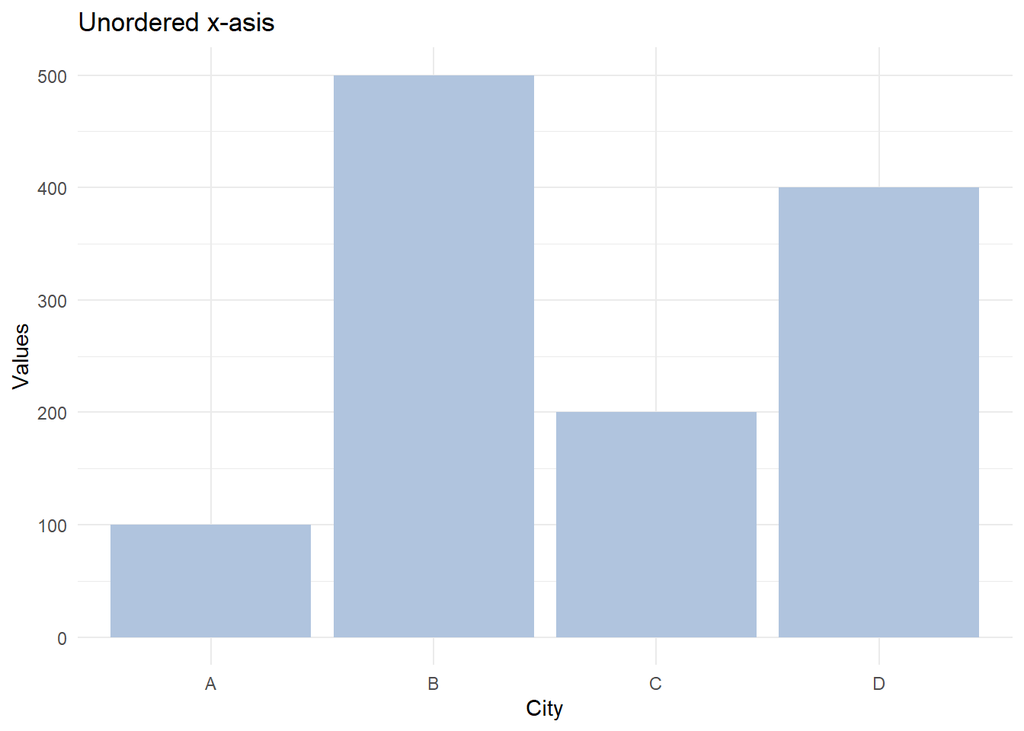

```r
library(ggplot2)

df |>
  ggplot(aes(x =  city, y = value)) +
  geom_col(fill = "lightsteelblue") +
  labs(title = "Unordered x-asis",
       x = "City",
       y = "Values") +
  theme_minimal()
```

The plot shows the data, but it might be difficult to see which of the labels on the horizontal axis is associated with the the largest value. Using `fct_reorder()`, you can change the order on the plot, without changing the order in the data frame:

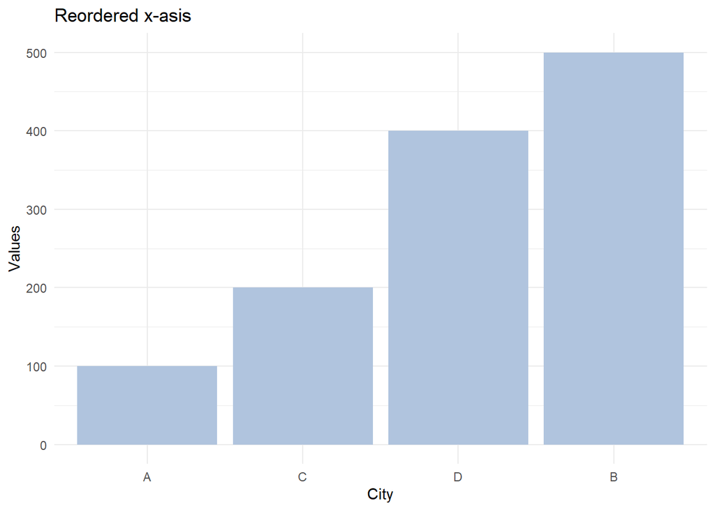

```r
df |>
  ggplot(aes(x =  forcats::fct_reorder(city, value), y = value)) +
  geom_col(fill = "lightsteelblue") +
  labs(title = "Reordered x-asis",
       x = "City",
       y = "Values") +
  theme_minimal()
```

{forcats} `fct_recode()` and `fct_collapse()` allow to modify the factor levels. `fct_recode()` allows you to recode factor levels. To do so, you need to use `fct_recode(x, "new value" = "old value")` where x is the factor and the statement “new value” = “old value” is entered every old factor level that you need to change. If an “old value” is not included, R assumes that it remains as is.

To illustrate, we first create a factor:

```r
vec_fac1 <- factor(x = c(1, 2, 3, 4), levels = c(1, 2, 3, 4), labels = c("small city", "large city", "small town", "large town"))
vec_fac1
```

```
[1] small city large city small town large town
Levels: small city large city small town large town
```

Let’s now recode to show levels “city, small”, “city, large”, “town, small” and “town, large”:

```r
forcats::fct_recode(vec_fac1,
                    "city, small" = "small city",
                    "city, large" = "large city",
                    "town, small" = "small town",
                    "town, large" = "large town")
```

```
[1] city, small city, large town, small town, large
Levels: city, small city, large town, small town, large
```

Note that you can use this function to reduce the number of levels. For instance, if you want to drop the difference between “small” and “large” and only keep “city” and “town”, you can recode all “small city” and “large city” to “city”:

```r
forcats::fct_recode(vec_fac1,
                    "city" = "small city",
                    "city" = "large city",
                    "town" = "small town",
                    "town" = "large town")
```

```
[1] city city town town
Levels: city town
```

Note that here you will loose these 4 factor levels if you recode and assign to the same factor.

{forcats}’ `fct_collapse()` function performs a similar task. It allows you to collapse various factor levels. The function’s argument is similar to those for recode. For instance, suppose you want to recode “small” and “large” in one level and you would use `fct_collapse()`:

```r
forcats::fct_collapse(vec_fac1,
                    "city" = c("small city", "large city"),
                    "town" = c("small town", "large town"))
```

```
[1] city city town town
Levels: city town
```

Here, you use `city" = c("small city", "large city")` to collapse the levels on the right hand side of the equality sign into the level on the left hand side.

**CautionYour turn**

Suppose that you have a variable with the values “Asi”, “Afr”, “Eur”, “Ame”, “Oce”. These values stand for “Asia”, “Africa”, “Europe”, “Americas” and “Oceania”. Create a factor that will show these contintents in alfabetical order and add labels. Use `cont` to store this variable.

```r
cont <- factor(c("Asi", "Afr", "Eur", "Ame", "Oce"), levels= c("Afr", "Ame", "Asi", "Eur", "Oce"), labels = c("Africa", "Americas", "Asia", "Europe", "Oceania"))
cont
```

```
[1] Asia     Africa   Europe   Americas Oceania
Levels: Africa Americas Asia Europe Oceania
```

Is `cont` a factor?

```r
is.ordered(cont)
```

```
[1] FALSE
```

Is `cont` an ordered factor?

```r
is.ordered(cont)
```

```
[1] FALSE
```

To measure an individual’s education, the following values are used in your dataset: “some high school”, “high school”, “some college”, “bachelor”, “master”, “PhD”. These values are including using numbers: 1 (some high school), 2 (high school), … 6 (PhD). `var_school` shows such a variable.

```r
var_school <- sample(1:6, 20, replace = TRUE)
```

Created an ordered factor including labels. Assign this factor to `school`.

```r
school <- factor(var_school, levels= c(1, 2, 3, 4, 5, 6), labels = c("some high school", "high school", "some college", "bachelor", "master", "PhD"), ordered = TRUE)
school
```

```
 [1] some college     bachelor         bachelor         PhD
 [5] some high school bachelor         master           master
 [9] master           PhD              some high school master
[13] PhD              high school      master           some college
[17] master           some high school PhD              master
6 Levels: some high school < high school < some college < ... < PhD
```

Use {forcats} to recode `school` and reduce the number of levels by merging “high school” and “some college” into “secondary” and merging “bachelor” and “master” into “tertiary”. There are two ways to do this:

- Option 1:

```r
forcats::fct_recode(school,
                    "secondary" = "high school",
                    "secondary" = "some college",
                    "tertiary" = "bachelor",
                    "tertiary" = "master")
```

```
 [1] secondary        tertiary         tertiary         PhD
 [5] some high school tertiary         tertiary         tertiary
 [9] tertiary         PhD              some high school tertiary
[13] PhD              secondary        tertiary         secondary
[17] tertiary         some high school PhD              tertiary
Levels: some high school < secondary < tertiary < PhD
```

- Option 2:

```r
forcats::fct_collapse(school,
                    "secondary" = c("high school", "some college"),
                    "tertiary" = c("bachelor", "master"))
```

```
 [1] secondary        tertiary         tertiary         PhD
 [5] some high school tertiary         tertiary         tertiary
 [9] tertiary         PhD              some high school tertiary
[13] PhD              secondary        tertiary         secondary
[17] tertiary         some high school PhD              tertiary
Levels: some high school < secondary < tertiary < PhD
```

## 4.2 Matrices

Matrices are two-dimensional objects that allow to store data in rows and columns. Recall that vectors stored data in one row and one or more columns. Like vectors, matrices are homogeneous. In other words, they store numeric or character or boolean or data/time values but not a combination of two or more datatypes. Most of what we discusses for vectors also applies to matrices. As a matter of fact, you can think of a vector as a special case of a matrix: it is a matrix with one row and one or more columns. However, if you want to use the vector as a matrix, you need to create a matrix with 1 row and n columns.

An “mxn” matrix has m rows and n columns. In general, the value on the ith row and jth column is referred to as matrix-name(i,j). We’ll see in the next section how you subset a matrix. A matrix with the same number of rows as there are columns, i.e. an nxn matrix is also called a square matrix. Here we will focus on numeric matrices. However, as long as all elements in a matrix are the same, a matric would also include characters, logical values, integers or data/time variables. As you will see here, most of what we learned for vectors also applies to matrices.

### 4.2.1 Creating a matrix

We will first show how to create a matrix in general. We then move to a couple of special matrices.

#### 4.2.1.1 The basics

To create a matrix, you use the `matrix(data = NA, nrow = 1, ncol = 1, byrow = FALSE, dimnames = NULL)` function. The first argument is optional and allows you to add a vector with data to fill the matrix. The second and third argument, `ncol = 1` and `nrow = 1` determine the size of the matrix: the desired number of rows and columns. If you add a vector that R needs to use to fill the data, `byrow = FALSE` instructs R to fill the matrix by column. In other words, if you have 4 rows and 5 columns, R first fills all rows of the first column, the all rows of the second, … to end with all 4 rows of the 5th column. Changing this default into `TRUE` tells R to first fill the rows. In other words, R will now first fill the 5 columns of the first row, then move to the second row and fill all columns in that row, … . The last argument allow you to add a name to the row and column dimensions. Let’s use a 2x3 matrix `mat_0`:

```r
mat_0 <- matrix(data = c(1, 2, 3, 4, 5, 6), nrow = 2, ncol = 3)
mat_0
```

```
     [,1] [,2] [,3]
[1,]    1    3    5
[2,]    2    4    6
```

As you can see, R creates a matrix with two rows [1, ] and [2, ] and three columns [,1], [,2], [,3]. R added the values in `c()` by column (default: `byrow = FALSE`). It took the first two values in `c()` (1 and 2) and used these to fill the first column. The next two values, 3 and 4, were added to the second column. The last two values in `c()` are shown in the last column.

The attributes of `mat_0` include the dimenions of the matrix: the number of rows and the number of columns:

```r
attributes(mat_0)
```

```
$dim
[1] 2 3
```

To create `mat_0` we included its elements via `c()`. The argument `data` can include vectors or functions. For instance, let’s use a 1x6 vector `vec_1` to illustrate this. We’ll fill `vec_1` with a sequence of 1 to 6 using the shorthand for `seq(from = 1, to = 6, by = 1)`:

```r
vec_1 <- 1:6
```

We can know create a matrix `mat_1` (accepting the default values for `byrow` and `dimnames`):

```r
mat_1 <- matrix(vec_1, nrow = 2, ncol = 3)
mat_1
```

```
     [,1] [,2] [,3]
[1,]    1    3    5
[2,]    2    4    6
```

As you can see, R filled this matrix in the same way as R did for `mat_0`. Note that we didn’t have to create a separate vector `vec_1`. We could have included `1:6` as the first argument.

In both examples, the length of `c()` or `vec_1` was equal to the number of cells in the matrix: the number of cells equals nrow * ncol = 6 and the length of `vec_1` or `c()` was also 6. If that is not the case, R reports an warning. If the number of cells in the matrix is larger than the length of the vector, R will use some of all values more than once. Suppose that you have a vector with 4 columns that needs to fill a matrix with 2 rows and 3 columns:

```r
matrix(1:4, nrow = 2, ncol = 3)
```

```
Warning in matrix(1:4, nrow = 2, ncol = 3): data length [4] is not a
sub-multiple or multiple of the number of columns [3]
```

```
     [,1] [,2] [,3]
[1,]    1    3    1
[2,]    2    4    2
```

R will use the first two observations of the vector two times. After having used all 4 columns of `1:4` to fill the first two columns, R uses the same vector again to fill the other cells. In this example, R used 1 and 2 of the sequence `1:4` twice. Note that R shows a warning that the dimensions of the vector and matrix didn’t fit.

If the length of the vector is longer than the number of cells in the matrix,

```r
matrix(1:9, 2, 3)
```

```
Warning in matrix(1:9, 2, 3): data length [9] is not a sub-multiple or multiple
of the number of rows [2]
```

```
     [,1] [,2] [,3]
[1,]    1    3    5
[2,]    2    4    6
```

R uses only the first nrow * ncol columns of the vector. Here R used the first 6 columns of the vector `1:9` to fill the matrix, and dropped the others. Again, R shows a warning message that the dimensions didn’t fit.

You can also create a matrix using the `dim()` function to a vector. The next examples shows how this works:

```r
vec_1 <- 1:6
dim(vec_1) = c(2, 3)
vec_1
```

```
     [,1] [,2] [,3]
[1,]    1    3    5
[2,]    2    4    6
```

You can use all others functions that generate a vector to fill a matrix. Examples include:

- a matrix with random numbers:

```r
matrix(rnorm(6), nrow = 2, ncol = 3)
```

```
           [,1]      [,2]       [,3]
[1,] 0.02905913  1.288859 -0.1529046
[2,] 0.46637676 -0.674857  0.2705640
```

- using letters:

```r
matrix(letters[1:6], nrow = 2, ncol = 3)
```

```
     [,1] [,2] [,3]
[1,] "a"  "c"  "e"
[2,] "b"  "d"  "f"
```

- as a sample:

```r
matrix(sample(1:1000, 6), nrow = 2, ncol = 3)
```

```
     [,1] [,2] [,3]
[1,]  817  426  412
[2,]  573  530  550
```

- using a set operator on two vectors generated as `1:12` and `7:18`:

```r
matrix(base::intersect(1:12, 7:18), nrow = 2, ncol = 3)
```

```
     [,1] [,2] [,3]
[1,]    7    9   11
[2,]    8   10   12
```

Let’s now see what `byrow = TRUE` changes to the outcome of `matrix()`:

```r
mat_1 <- matrix(1:6, nrow = 2, ncol = 3, byrow = TRUE)
mat_1
```

```
     [,1] [,2] [,3]
[1,]    1    2    3
[2,]    4    5    6
```

Recall that with the default for `byrow`, R first filled the first column, then the second and then the third. As you can see from the output now, R now filled the first row first putting the first value of `vec_1` in the first column, the second value in the second and the third value in the third column. As all columns in the first row were filled, R moved to the second row and used the fourth value of `vec_1` to fill the first column on the second row, the fifth value to fill the second column on the second row and the sixth value in the third column on the second row.

The last option allows you to specify row and column names. To do so, you need to collect them in a `list`. Here we need a list because the length of the vector with column names can be different from the length of the vector with rownames.

```r
mat_1 <- matrix(vec_1, nrow = 2, ncol = 3, byrow = TRUE, dimnames = list(c("row1", "row2"), c("var1", "var2", "var3")))
mat_1
```

```
     var1 var2 var3
row1    1    2    3
row2    4    5    6
```

The output now shows the row and column names. These names are added to the attributes of the matrix as `dimnames[[1]]` for the rows and `dimnames[[2]]` for the columns:

```r
attributes(mat_1)
```

```
$dim
[1] 2 3

$dimnames
$dimnames[[1]]
[1] "row1" "row2"

$dimnames[[2]]
[1] "var1" "var2" "var3"
```

As alternative to add row and column names are the functions `rownames()` and `colnames()`. Let’s first recreate `mat_1` without names:

```r
mat_1 <- matrix(1:6, nrow = 2, ncol = 3)
```

You can use `colnames()` in two ways. The argument of this function is a vector with column names. Suppose you want to add the following names to the columns of `mat_1`: `c("var1", "var2", "var3")`. The first way to do so is to use

```r
colnames(mat_1) <- c("var1", "var2", "var3")
mat_1
```

```
     var1 var2 var3
[1,]    1    3    5
[2,]    2    4    6
```

To add rownames, you can use `rownames()`. This function requires a vector with the names: `c("row1", "row2")`. To add these names:

```r
rownames(mat_1) <- c("row1", "row2")
mat_1
```

```
     var1 var2 var3
row1    1    3    5
row2    2    4    6
```

```r
colnames(mat_1) <- colnames(mat_1, do.NULL = FALSE, prefix = "var_")
mat_1
```

```
     var1 var2 var3
row1    1    3    5
row2    2    4    6
```

```r
rownames(mat_1) <- rownames(mat_1, do.NULL = FALSE, prefix = "obs_")
mat_1
```

```
     var1 var2 var3
row1    1    3    5
row2    2    4    6
```

Note that there are many ways you can use the character functions to automate the process of naming rows and columns. As an illustration, let’s rewrite

```r
rownames(mat_1) <- c("row1", "row2")
mat_1
```

```
     var1 var2 var3
row1    1    3    5
row2    2    4    6
```

using the `paste0()` function:

```r
rownames(mat_1) <- paste0("row", 1:2)
mat_1
```

```
     var1 var2 var3
row1    1    3    5
row2    2    4    6
```

and

```r
colnames(mat_1) <- c("var1", "var2", "var3")
mat_1
```

```
     var1 var2 var3
row1    1    3    5
row2    2    4    6
```

using the `paste()` function:

```r
colnames(mat_1) <- paste(1:3, c("st", "nd", "rd"), sep="")
mat_1
```

```
     1st 2nd 3rd
row1   1   3   5
row2   2   4   6
```

If your matrix has column or row names, you can show these using the same `colnames()` or `rownames()` function. For instance:

```r
colnames(mat_1)
```

```
[1] "1st" "2nd" "3rd"
```

```r
rownames(mat_1)
```

```
[1] "row1" "row2"
```

#### 4.2.1.2 Special matrices

Recall that vectors are data structures with 1 row and one or more columns. If you need to work with matrix algebra and use vectors, it is best to create a vector explicitly as a matrix. To do so, you need a matrix with 1 row and e.g. 3 columns:

```r
mat_vec <- matrix(1:3, 1, 3)
```

There are a couple of special matrices. Using the matrix function, we can create a mxn matrix with one constant value.

```r
mat_2 <- matrix(5, nrow = 2, ncol = 3)
mat_2
```

```
     [,1] [,2] [,3]
[1,]    5    5    5
[2,]    5    5    5
```

Here there are two special cases: a square matrix filled with ones;

```r
J <- matrix(1, nrow = 3, ncol = 3)
J
```

```
     [,1] [,2] [,3]
[1,]    1    1    1
[2,]    1    1    1
[3,]    1    1    1
```

and the zero matrix: a mxn matrix with zero’s:

```r
zeros <- matrix(0, nrow = 2, ncol = 3)
zeros
```

```
     [,1] [,2] [,3]
[1,]    0    0    0
[2,]    0    0    0
```

A diagonal matrix is a square matrix where all values are equal to zero except those on the diagonal:

```r
diag(c(10, 11, 12), nrow = 3, ncol = 3)
```

```
     [,1] [,2] [,3]
[1,]   10    0    0
[2,]    0   11    0
[3,]    0    0   12
```

A special case of this diagonal matrix is the identity matrix: a diagonal matrix whose diagonal elements are equal to 1:

```r
ident <- diag(1, nrow = 3, ncol = 3)
ident
```

```
     [,1] [,2] [,3]
[1,]    1    0    0
[2,]    0    1    0
[3,]    0    0    1
```

The last special case, is a vector (a 1xn matrix), whose elements are all 1:

```r
vec_ones <- matrix(1, 1, 3)
vec_ones
```

```
     [,1] [,2] [,3]
[1,]    1    1    1
```

Triangular matrices are square matrices where all elements below the diagonal are 0 (upper triangular) or all elements above the diagonal are 0 (lower triangular). If, in addition to these elements, the elements on the diagonal are also 0, the square matrix is strict triangular. The functions `upper.tri(x, diag = FALSE)` and `lower.tri(x, diag = FALSE)` can be used to create those matrices. These function return a logical matrix whose elements are TRUE if it above the diagonal (upper, with `diag = FALSE`) and FALSE is this is not the case. With `diag = TRUE`, the logical values on the diagonal will also be TRUE. The interpretation for the lower triangular function are identical, with the exception that TRUE in this case is for elements below or below and on the diagonal. To see how these function work, we’ll use:

```r
mat_1 <- matrix(1:25, 5, 5)
```

Using `upper.tri()` as an example to show the logical matrix:

```r
upper.tri(mat_1, diag = FALSE)
```

```
      [,1]  [,2]  [,3]  [,4]  [,5]
[1,] FALSE  TRUE  TRUE  TRUE  TRUE
[2,] FALSE FALSE  TRUE  TRUE  TRUE
[3,] FALSE FALSE FALSE  TRUE  TRUE
[4,] FALSE FALSE FALSE FALSE  TRUE
[5,] FALSE FALSE FALSE FALSE FALSE
```

We can now use this logical matrix to change `mat_1` into a lower triangular matrix whose elements on the diagonal differ from 0:

```r
mat_1[upper.tri(mat_1, diag = FALSE)] <- 0
mat_1
```

```
     [,1] [,2] [,3] [,4] [,5]
[1,]    1    0    0    0    0
[2,]    2    7    0    0    0
[3,]    3    8   13    0    0
[4,]    4    9   14   19    0
[5,]    5   10   15   20   25
```

Note that here, we use the function `upper.tri()` to create a lower triangular matrix. To create a strict lower diagonal matrix, you can change the default value `diag = FALSE` in `diag = TRUE`. Doing so allows you to create a strict lower triangular matrix:

```r
mat_1 <- matrix(1:25, 5, 5)
mat_1[upper.tri(mat_1, diag = TRUE)] <- 0
mat_1
```

```
     [,1] [,2] [,3] [,4] [,5]
[1,]    0    0    0    0    0
[2,]    2    0    0    0    0
[3,]    3    8    0    0    0
[4,]    4    9   14    0    0
[5,]    5   10   15   20    0
```

#### 4.2.1.3 Coercing objects to matrix class

```r
class(vec_1)
```

```
[1] "matrix" "array"
```

```r
class(mat_1)
```

```
[1] "matrix" "array"
```

```r
mat_1 <- as.matrix(vec_1)
mat_1
```

```
     [,1] [,2] [,3]
[1,]    1    3    5
[2,]    2    4    6
```

You can change a data frame into a matrix in a similar way. Recall from Chapter 1 that R includes a dataset `mtcars`. A data frame is a data structure we will discuss shortly:

```r
class(mtcars)
```

```
[1] "data.frame"
```

Recall that this data frame had 32 observations for 11 variables. This data frame includes variable names and identifies every observation:

```r
head(mtcars)
```

```
                   mpg cyl disp  hp drat    wt  qsec vs am gear carb
Mazda RX4         21.0   6  160 110 3.90 2.620 16.46  0  1    4    4
Mazda RX4 Wag     21.0   6  160 110 3.90 2.875 17.02  0  1    4    4
Datsun 710        22.8   4  108  93 3.85 2.320 18.61  1  1    4    1
Hornet 4 Drive    21.4   6  258 110 3.08 3.215 19.44  1  0    3    1
Hornet Sportabout 18.7   8  360 175 3.15 3.440 17.02  0  0    3    2
Valiant           18.1   6  225 105 2.76 3.460 20.22  1  0    3    1
```

With `as.matrix()` you can change this data frame into a matrix:

```r
mat_mtcars <- as.matrix(mtcars)
```

This matrix has column and row names.

```r
colnames(mat_mtcars)
```

```
 [1] "mpg"  "cyl"  "disp" "hp"   "drat" "wt"   "qsec" "vs"   "am"   "gear"
[11] "carb"
```

```r
rownames(mat_mtcars)
```

```
 [1] "Mazda RX4"           "Mazda RX4 Wag"       "Datsun 710"
 [4] "Hornet 4 Drive"      "Hornet Sportabout"   "Valiant"
 [7] "Duster 360"          "Merc 240D"           "Merc 230"
[10] "Merc 280"            "Merc 280C"           "Merc 450SE"
[13] "Merc 450SL"          "Merc 450SLC"         "Cadillac Fleetwood"
[16] "Lincoln Continental" "Chrysler Imperial"   "Fiat 128"
[19] "Honda Civic"         "Toyota Corolla"      "Toyota Corona"
[22] "Dodge Challenger"    "AMC Javelin"         "Camaro Z28"
[25] "Pontiac Firebird"    "Fiat X1-9"           "Porsche 914-2"
[28] "Lotus Europa"        "Ford Pantera L"      "Ferrari Dino"
[31] "Maserati Bora"       "Volvo 142E"
```

Recall that a matrix is homogeneous: all elements must be of the same type. Often data frames are heterogeneous: they include numeric, character, data/time, boolean of factor variables. Using the `data.matrix()` function, R will change this data frame in a numeric matrix by converting all variables to numeric first. For instance, suppose that you have a data.frame `df`:

```r
df <- data.frame(A = 1:3, B = letters[1:3], C = seq.Date(as.Date("2025-03-25"), by = "day", length.out = 3))
df
```

```
  A B          C
1 1 a 2025-03-25
2 2 b 2025-03-26
3 3 c 2025-03-27
```

If you would use `as.matrix()` R would convert this data frame into a character matrix:

```r
mat_df <- as.matrix(df)
typeof(mat_df)
```

```
[1] "character"
```

Using `data.matrix()` avoids this:

```r
mat_df <- data.matrix(df)
mat_df
```

```
     A B     C
[1,] 1 1 20172
[2,] 2 2 20173
[3,] 3 3 20174
```

As you can see, the second column, B, has been changed to numeric. R changed the value of “a” into 1, “b” into 2, … . Here, all unique values are given a different numeric value. In addition, R used the fact that dates are numeric to change the date into numeric.

### 4.2.2 Matrix type and attributes

#### 4.2.2.1 Matrix type

Here we first created the matrix using `matrix()`. However, it is also possible that you create a matrix within your code. To check is an object is a matrix, you can use the `is.matrix()` function.

```r
is.matrix(mat_1)
```

```
[1] TRUE
```

If an object is a matrix, this function show TRUE. If this is not the case, the function shows FALSE. If an object is a matrix, you can check its type using `typeof()`:

```r
typeof(mat_1)
```

```
[1] "integer"
```

Here, `mat_1` is an integer matrix. In other words, its values are of type “integer”. Recall that this matrix was creates from the sequence `1:6`. In other words, it was created as an integer value. The type of a matrix is determined is a similar way as a vector. To illustrate, let’s define 3 matrices

```r
mat_n <- matrix(rnorm(6), 2, 3)
mat_c <- matrix(letters[1:6], 2, 3)
mat_d <- matrix(seq(as.Date("2025-03-25"), by = "day", length.out = 6), 2, 3)
```

and check there type:

```r
typeof(mat_n)
```

```
[1] "double"
```

```r
typeof(mat_c)
```

```
[1] "character"
```

```r
typeof(mat_d)
```

```
[1] "integer"
```

As you can see, R stores the dates in `mat_d` as numeric variables with class “Matrix” “Array”. Recall that dates are stored as numbers. In other words you can turn these numbers into dates using one of the function we have covered, e.g. `as.Date()` or {lubridate}’s `ymd()`.

```r
mat_n[2,2] <- "10000"
mat_n
```

```
     [,1]                [,2]               [,3]
[1,] "0.982499218575708" "0.42216077988595" "0.22435607224835"
[2,] "-1.01112994823057" "10000"            "0.125027643014595"
```

The output suggest that R coerced all other elements into character variables. Indeed, the type of this matrix is

```r
typeof(mat_n)
```

```
[1] "character"
```

now a character matrix. We have seen similar behavior with vectors.

#### 4.2.2.2 Matrix attributes

A matrix has some attributes that you will often use in code. To check the attributes of an object, you can use R’s `attributes()` function. To illustrate this function, we’ll use

```r
mat_1 <- matrix(vec_1, nrow = 2, ncol = 3, byrow = TRUE, dimnames = list(c("row1", "row2"), c("var1", "var2", "var3")))
mat_1
```

```
     var1 var2 var3
row1    1    2    3
row2    4    5    6
```

The function shows which the attributes for the object:

```r
att_mat1 <- attributes(mat_1)
att_mat1
```

```
$dim
[1] 2 3

$dimnames
$dimnames[[1]]
[1] "row1" "row2"

$dimnames[[2]]
[1] "var1" "var2" "var3"
```

Here, you see the various attributes: the dimension `$dim`, the row names `dimnames[1]` and colum names `dimnames[2]`. There are multiple ways to access these attributes. For instance, the dimension of the matrix includes the number of rows (2) and the number of columns (3). To extract the number these dimensions you can use `dim()`. This function shows the number of rows and column in `mat_1`.

```r
dim(mat_1)
```

```
[1] 2 3
```

You can use these to extract the number of rows and columns. To do so, you assign the result of this function to an object.

```r
dim_mat1 <- dim(mat_1)
dim_mat1
```

```
[1] 2 3
```

You can now subset this result:

```r
nobs <- dim_mat1[1]
nvar <- dim_mat1[2]
```

These values now store the number of rows (`nobs`) and the number of columns (`nvar`).

If you are only interested in the number of rows or number of columns, you can extract these using `nrow()` or `ncol()`:

```r
nrow(mat_1)
```

```
[1] 2
```

```r
ncol(mat_1)
```

```
[1] 3
```

Note that in many cases, the number of rows will be equal to the number of observations in your dataset while the number of column is equal to the number of variables.

To see the total number of values in the matrix, or the product of the number of rows and the number of columns, you can use `length()`:

```r
length(mat_1)
```

```
[1] 6
```

```r
nrow(mat_1) * ncol(mat_1)
```

```
[1] 6
```

If you need the column or row names, you can use `colnames()` or `rownames()`:

```r
colnames(mat_1)
```

```
[1] "var1" "var2" "var3"
```

```r
rownames(mat_1)
```

```
[1] "row1" "row2"
```

If you store these names, you can use them in your code.

**CautionYour turn**

Create a 3x3 matrix, `mat_0` using a sequence from 21:29

```r
mat_0 <- matrix(21:29, 3, 3)
mat_0
```

```
     [,1] [,2] [,3]
[1,]   21   24   27
[2,]   22   25   28
[3,]   23   26   29
```

Using the same values, fill this matrix by row:

```r
mat_0 <- matrix(21:29, 3, 3, byrow = TRUE)
mat_0
```

```
     [,1] [,2] [,3]
[1,]   21   22   23
[2,]   24   25   26
[3,]   27   28   29
```

Store the numbers 21-29 in a vector `mat_0` and create a matrix using the `dim()` function

```r
mat_0 <- 21:29
dim(mat_0) <- c(3, 3)
mat_0
```

```
     [,1] [,2] [,3]
[1,]   21   24   27
[2,]   22   25   28
[3,]   23   26   29
```

What happens if you use 1:4 to create a 2x3 matrix `mat_0`, filled by column? Predict the value in `mat_0[2, 3]`.

```r
mat_0 <- matrix(1:4, 2, 3)
mat_0[2, 3]
```

```
[1] 2
```

What is the value in `mat_0[2, 3]` you fill the matrix with 1:9

```r
mat_0 <- matrix(1:9, 2, 3)
mat_0[2 ,3]
```

```
[1] 6
```

Create 3x3 a named matrix `mat_0` with elements 21-29 with row names “obs_1”, “obs_2”, … and column names “var_1”, “var_2”

```r
mat_0 <- matrix(21:29, 3, 3, dimnames = list(c("obs_1", "obs_2", "obs_3"), c("var_1",  "var_2", "var_3")))
mat_0
```

```
      var_1 var_2 var_3
obs_1    21    24    27
obs_2    22    25    28
obs_3    23    26    29
```

Here, you had to write down all names. First recreate `mat_0` without names and then use the `rownames` and `colnames` function to set the names. Using these function, try to avoid writing all names. There are two ways to do so.

- option 1:

```r
mat_0 <- matrix(21:29, 3, 3)
rownames(mat_0) <- paste("obs", 1:3, sep = "_")
colnames(mat_0) <- paste("var", 1:3, sep = "_")
mat_0
```

```
      var_1 var_2 var_3
obs_1    21    24    27
obs_2    22    25    28
obs_3    23    26    29
```

- Option 2

```r
mat_0 <- matrix(21:29, 3, 3)
rownames(mat_0) <- rownames(mat_0, do.NULL = FALSE, prefix = "obs_")
colnames(mat_0) <- colnames(mat_0, do.NULL = FALSE, prefix = "var_")
mat_0
```

```
      var_1 var_2 var_3
obs_1    21    24    27
obs_2    22    25    28
obs_3    23    26    29
```

Create a 4x4 identity matrix `ident`

```r
ident <- diag(1, 4, 4)
ident
```

```
     [,1] [,2] [,3] [,4]
[1,]    1    0    0    0
[2,]    0    1    0    0
[3,]    0    0    1    0
[4,]    0    0    0    1
```

Determine the number of rows and columns for this matrix:

```r
mat_0 <- matrix(rnorm(1000), 500, 2)
colnames(mat_0) <- c("var_1", "var_2")
rownames(mat_0) <- paste("obs", 1:500, sep = "_")
```

- Option 1:

```r
nrow(mat_0)
```

```
[1] 500
```

```r
ncol(mat_0)
```

```
[1] 2
```

- Option 2:

```r
attributes(mat_0)$dim[1]
```

```
[1] 500
```

```r
attributes(mat_0)$dim[2]
```

```
[1] 2
```

Determine the type of `mat_0`:

```r
typeof(mat_0)
```

```
[1] "double"
```

Fill a 3x3 matrix, `mat_1`, with the first 9 letters of the alfabet, lowercase

```r
mat_1 <- matrix(letters[1:9], 3, 3)
mat_1
```

```
     [,1] [,2] [,3]
[1,] "a"  "d"  "g"
[2,] "b"  "e"  "h"
[3,] "c"  "f"  "i"
```

Fill a 3x3 matrix, `mat_2` with a sequence of dates, starting 2025-04-01 and ending 2025-04-09.

```r
mat_2 <- matrix(seq.Date(from = as.Date("2025-04-01"), to = as.Date("2025-04-09"), by = "days"), 3, 3)
mat_2
```

```
      [,1]  [,2]  [,3]
[1,] 20179 20182 20185
[2,] 20180 20183 20186
[3,] 20181 20184 20187
```

Create a 3x3 boolean matrix, `mat_3`, using random sample from TRUE and FALSE

```r
mat_3 <- matrix(sample(c(TRUE, FALSE), 9, replace = TRUE), 3, 3)
mat_3
```

```
      [,1]  [,2]  [,3]
[1,] FALSE  TRUE FALSE
[2,]  TRUE FALSE FALSE
[3,] FALSE  TRUE FALSE
```

### 4.2.3 Subsetting a matrix

#### 4.2.3.1 Subsetting by position

Subsetting a matrix uses an approach which is very similar to the one used for a vector. However, with a matrix you have both rows as well as columns. This allows you to subset both individual elements, all rows on one of multiple columns, all columns on one or multiple rows or a range of elements spread over some columns and some rows. Matrix `mat` will be used to illustrate these approaches:

```r
mat <- matrix(c(11, 21, 31, 41, 12, 22, 32, 42, 13, 23, 33, 34, 41, 42, 43, 44), nrow = 4, ncol = 4)
mat
```

```
     [,1] [,2] [,3] [,4]
[1,]   11   12   13   41
[2,]   21   22   23   42
[3,]   31   32   33   43
[4,]   41   42   34   44
```

To subset an individual element, you can use `mat[m, n]` with `m` the row index and `n` the column index. For instance, extracting the element in the second row and the third column:

```r
mat[2, 3]
```

```
[1] 23
```

If you assign the outcome to a new variable, you can use it in your code.

You can extract an entire column using `mat[, n]`. For instance, extracting the 4th column of `mat`:

```r
mat[, 4]
```

```
[1] 41 42 43 44
```

Subsetting a specific row using a similar approach. To subset row m, you use `mat[m, ]`. For instance, subsetting the 3rd row of `mat`:

```r
mat[3, ]
```

```
[1] 31 32 33 43
```

Note that R shows the simplest possible data structure. Subsetting a row or column, results in a numeric vector. To see this, let’s use `is.vector()` and ask for the class of `mat[3, ]`:

```r
class(mat[3, ])
```

```
[1] "numeric"
```

```r
is.vector(mat[3, 1])
```

```
[1] TRUE
```

To preserve the structure, you need to add `drop = FALSE` within the subsetting operations. For instance,

```r
mat[3, , drop = FALSE]
```

```
     [,1] [,2] [,3] [,4]
[1,]   31   32   33   43
```

preserves the structure of the matrix. You can see this from the result, which is now shown as a matrix, as well as from the logical operators

```r
is.vector(mat[3, , drop = FALSE])
```

```
[1] FALSE
```

```r
is.matrix(mat[3, , drop = FALSE])
```

```
[1] TRUE
```

In programming, adding `drop = FALSE` is usually a good idea as it preserves the data structure. With vectors, the subsetting operator `[]` preserved the structure of the vector while `[[ ]]` acted as the simplifying operator. With matrices, `[]` act as the simplifying operator. To preserve the structure, you need to add `drop = FALSE`.

You can subset multiple columns or rows. Suppose you need columns n to k of `mat`. You can subset these using `mat[, n:k]`. For instance, subsetting the 2nd to 4th column:

```r
mat[, 2:4]
```

```
     [,1] [,2] [,3]
[1,]   12   13   41
[2,]   22   23   42
[3,]   32   33   43
[4,]   42   34   44
```

Note that in this case, the structure is preserved: the simplest possible data structure to show the result of the subsetting operation is a matrix.

Similarly, substteng row m to l, is done using `mat[m:l, ]`. For instance, with m = 2 and l = 4 you subset the 2nd to 4th row:

```r
mat[2:4, ]
```

```
     [,1] [,2] [,3] [,4]
[1,]   21   22   23   42
[2,]   31   32   33   43
[3,]   41   42   34   44
```

`mat[m:l, n:k]` subsets a range: the elements on row m to l and in columns n to k. For instance, if you need the elements in rows 2 to 4 and in columns 1 to 3:

```r
mat[2:4, 1:3]
```

```
     [,1] [,2] [,3]
[1,]   21   22   23
[2,]   31   32   33
[3,]   41   42   34
```

If you need a specific number of rows or columns who are not in a range, you can identify them within vector using `c(m, l, ...)`. For instance

- subsetting row 1 and 3 and column 2 and 4

```r
mat[c(1, 3), c(2, 4)]
```

```
     [,1] [,2]
[1,]   12   41
[2,]   32   43
```

- subsetting all elements on row 1 and 3

```r
mat[c(1, 3), ]
```

```
     [,1] [,2] [,3] [,4]
[1,]   11   12   13   41
[2,]   31   32   33   43
```

- subsetting all elements in column 2 and 4

```r
mat[, c(2, 4)]
```

```
     [,1] [,2]
[1,]   12   41
[2,]   22   42
[3,]   32   43
[4,]   42   44
```

Using negative index numbers, you tell R that you don’t want to extract those rows or columns. For instance, to show all elements in `mat` except those in the first row and first column, `mat[-1, -1]` shows:

```r
mat[-1, -1]
```

```
     [,1] [,2] [,3]
[1,]   22   23   42
[2,]   32   33   43
[3,]   42   34   44
```

You can use negative indices to extract one or more rows or columns or ranges:

- extracting all columns except columns 3 to 4

```r
mat[, -3:-4]
```

```
     [,1] [,2]
[1,]   11   12
[2,]   21   22
[3,]   31   32
[4,]   41   42
```

- extracting all rows except rows 1 to 3

```r
mat[-1:-3, ]
```

```
[1] 41 42 34 44
```

Note that in this case, R simplifies the output to a vector (`mat` has 4 rows can you extract all except the first three). Here you have an example where you would change the data structure by subsetting all rows except 1. To avoid that, you can use the preserving operator:

```r
mat[-1:-3, , drop = F]
```

```
     [,1] [,2] [,3] [,4]
[1,]   41   42   34   44
```

- extracting all elements except those in columns 1 to 2 and rows 1 to 2

```r
mat[-1:-2, -1:-2]
```

```
     [,1] [,2]
[1,]   33   43
[2,]   34   44
```

Note the you can select multiple columns or rows not in a range using `-c(k, l)`, e.g. extracting all columns except 1 and 3:

```r
mat[, -c(1, 3)]
```

```
     [,1] [,2]
[1,]   12   41
[2,]   22   42
[3,]   32   43
[4,]   42   44
```

#### 4.2.3.2 Subsetting a named matrix

With names matrices, you can also refer to the names of the columns and rows. Let’s add row and column names to `mat`:

```r
colnames(mat) <- colnames(mat, do.NULL = FALSE, prefix = "var_")
rownames(mat) <- rownames(mat, do.NULL = FALSE, prefix = "row_")
mat
```

```
      var_1 var_2 var_3 var_4
row_1    11    12    13    41
row_2    21    22    23    42
row_3    31    32    33    43
row_4    41    42    34    44
```

You can now subset this matrix using `mat[“rowname”, “columnname”]. For instance, extracting the element on row 2 and column 3:

```r
mat["row_2", "var_3"]
```

```
[1] 23
```

Subsetting all elements in column `var_3`:

```r
mat[, "var_3"]
```

```
row_1 row_2 row_3 row_4
   13    23    33    34
```

Note that R retains the row names in this case, however, you loose the structure of the matrix. To avoid this, add `drop = F`:

```r
mat[, "var_3", drop = F]
```

```
      var_3
row_1    13
row_2    23
row_3    33
row_4    34
```

R also shows the names if you subset a named matrix using indices:

```r
mat[, 3, drop = F]
```

```
      var_3
row_1    13
row_2    23
row_3    33
row_4    34
```

To extract all elements in row 2 and keep the structure:

```r
mat["row_2", , drop = F]
```

```
      var_1 var_2 var_3 var_4
row_2    21    22    23    42
```

You can also collect the names a vector and subset multiple rows:

```r
mat[c("row_1", "row_3"), ]
```

```
      var_1 var_2 var_3 var_4
row_1    11    12    13    41
row_3    31    32    33    43
```

or multiple columns:

```r
mat[, c("var_1", "var_3")]
```

```
      var_1 var_3
row_1    11    13
row_2    21    23
row_3    31    33
row_4    41    34
```

or both:

```r
mat[c("row_1", "row_3"), c("var_1", "var_3")]
```

```
      var_1 var_3
row_1    11    13
row_3    31    33
```

#### 4.2.3.3 Subsetting using a logical matrix

Recall that you can subset a vector using a logical vector. For a matrix, this is also true. However, in this case, the result is not a matrix but a vector. This vector includes all elements for which the condition returned TRUE. Let’s create a random logical matrix:

```r
cond = matrix(sample(c(TRUE, FALSE), 16, TRUE), nrow = 4, ncol = 4)
cond
```

```
      [,1]  [,2]  [,3]  [,4]
[1,] FALSE  TRUE FALSE FALSE
[2,]  TRUE FALSE FALSE FALSE
[3,] FALSE  TRUE  TRUE FALSE
[4,]  TRUE  TRUE FALSE FALSE
```

Here, we have a matrix whose elements are either TRUE or FALSE. We can use this matrix to extract the values in `mat` who are in the same position as the value TRUE in the matrix `cond`. To do so, we can use:

```r
mat[cond]
```

```
[1] 21 41 12 32 42 33
```

Withing the `[]` you can include various conditions, for instance, to extract all elements in `mat` larger than 25, you can use

```r
mat[mat > 25]
```

```
 [1] 31 41 32 42 33 34 41 42 43 44
```

```r
cond <- mat[, 1] > 25
cond
```

```
row_1 row_2 row_3 row_4
FALSE FALSE  TRUE  TRUE
```

If you include this condition in the subsetting operator for the rows, you’ll see all columns for the rows whose value in the first column in larger than 25:

```r
mat[cond, ]
```

```
      var_1 var_2 var_3 var_4
row_3    31    32    33    43
row_4    41    42    34    44
```

Collecting the elements in a vector, allows you to verify if they are also elements in the matrix. For instance, extracting the elements in `mat` who are equal to 12, 22, 33, 44 or 55, is done using

```r
mat[mat %in% c(12, 22, 33, 44, 55)]
```

```
[1] 12 22 33 44
```

Subsetting using logical conditions also allows you to subset a named matrix using regular expressions. Recall that the `grepl()` function outputs a logical vector. If a matrix has column or row names, you can use these in `grepl()` to extract observations (rows) or variables (columns) that match a regular expressions. Suppose that you want to extract all observations on `row_1`, `row_2` and `row_3`. Here, a simple regular expression would be “*[0-3]”. This regular expression matches all rows that include ”*” and one digit equal to 0, 1, 2 or 3. `grepl()` needs to find matches in the row names of `mat`:

```r
grepl(pattern = "_[0-3]", x = rownames(mat))
```

```
[1]  TRUE  TRUE  TRUE FALSE
```

We can now use this expression to extract the observations. To do so, you either create a vector `cond` to store the result of `grepl()` which you can then use to subset:

```r
cond <- grepl(pattern = "_[0-3]", x = rownames(mat))
mat[cond, ]
```

```
      var_1 var_2 var_3 var_4
row_1    11    12    13    41
row_2    21    22    23    42
row_3    31    32    33    43
```

As an alternative, you use the `grepl()` in the subsettig operation:

```r
mat[grepl(pattern = "_[0-3]", x = rownames(mat)), ]
```

```
      var_1 var_2 var_3 var_4
row_1    11    12    13    41
row_2    21    22    23    42
row_3    31    32    33    43
```

Using this last method is probably less likely to result in code that is easy to read. In other words, if the pattern is complex, it it in general a good idea to use the first method.

You can do the same with column names. For instance, extracting all variables `var_2`, `var_3` and `var_4` can be done through:

```r
mat[, grepl(pattern = "_[2-4]", x = colnames(mat))]
```

```
      var_2 var_3 var_4
row_1    12    13    41
row_2    22    23    42
row_3    32    33    43
row_4    42    34    44
```

Combining both subsets both rows as well as columns:

```r
mat[grepl(pattern = "_[0-3]", x = rownames(mat)), grepl(pattern = "_[2-4]", x = colnames(mat))]
```

```
      var_2 var_3 var_4
row_1    12    13    41
row_2    22    23    42
row_3    32    33    43
```

The `subset(x, subset, select, drop = FALSE, ...)` function allows you to extract columns, defined in `select` from the matrix `x` using a logical index defined in `subset`. Using this function, you can subset rows and select which columns R needs to return. For instance, to selects the rows in columns 1 and 4 of `mat` if the value in column 2 is larger than 20 `mat[, 2] > 20`, you would use:

```r
subset(mat, subset = mat[, 2] > 20, select = c(1, 4))
```

```
      var_1 var_4
row_2    21    42
row_3    31    43
row_4    41    44
```

In the select argument, you can use the usual subsetting methods:

- extracting all columns between 2 and 4

```r
subset(mat, subset = mat[, 2] > 20, select = 2:4)
```

```
      var_2 var_3 var_4
row_2    22    23    42
row_3    32    33    43
row_4    42    34    44
```

- extracting all but column 4:

```r
subset(mat, subset = mat[, 2] > 20, select = -4)
```

```
      var_1 var_2 var_3
row_2    21    22    23
row_3    31    32    33
row_4    41    42    34
```

Using the row names of the matrix, you can also use `grepl()`. For instance, selecting columns 1 and 4 and only rows whose name includes “3” or “4” uses:

```r
cond <- grepl(pattern = "row_[3-4]", rownames(mat))
subset(mat, cond, c(1, 4))
```

```
      var_1 var_4
row_3    31    43
row_4    41    44
```

If you don’t use `select =`, by default, R return all columns. Excluding the `subset` argument will return all selected columns.

#### 4.2.3.4 Diagonal and lower and upper triangular parts

If you have a square matrix, you can extract the diagonal elements using `diag(x)`. Extracting the diagonal elements from `mat:

```r
diag(mat, names = TRUE)
```

```
[1] 11 22 33 44
```

To extract the upper or lower triangular part of a square matrix, there are two functions: `upper.tri(x, diag = FALSE)` and `lower.tri(x, diag = FALSE)`. The first subsets the upper triangular part, excluding the diagonal. The second the lower triangular part. Both include the square matrix as the first argument. The second argument determines is the diagonal is included or not (default). The outcome is a logical vector that can be used to subset the matrix.

```r
uptri <- upper.tri(mat, diag = FALSE)
uptri
```

```
      [,1]  [,2]  [,3]  [,4]
[1,] FALSE  TRUE  TRUE  TRUE
[2,] FALSE FALSE  TRUE  TRUE
[3,] FALSE FALSE FALSE  TRUE
[4,] FALSE FALSE FALSE FALSE
```

Applying these two function to `mat`:

```r
mat[uptri]
```

```
[1] 12 13 23 41 42 43
```

Extracting the lower triangular part can be done is a similar way. If we add the diagonal,

```r
lotri <- lower.tri(mat, diag = TRUE)
mat[lotri]
```

```
 [1] 11 21 31 41 22 32 42 33 34 44
```

**CautionYour turn**

Create 3x3 matrix, `mat_0` as a sequence from 101-109.

```r
mat_0 <- matrix(101:109, 3, 3)
```

Using this matrix, extract

- element in row 2 and column 3:

```r
mat_0[2, 3]
```

```
[1] 108
```

- all values in column 2 and preserve the structure of the matrix in the result

```r
mat_0[, 2, drop = FALSE]
```

```
     [,1]
[1,]  104
[2,]  105
[3,]  106
```

- all values in row 1 and preserve the structure of the matrix in the result

```r
mat_0[1, , drop = FALSE]
```

```
     [,1] [,2] [,3]
[1,]  101  104  107
```

- all values except those in column 1:

```r
mat_0[, -1]
```

```
     [,1] [,2]
[1,]  104  107
[2,]  105  108
[3,]  106  109
```

- all values in columns 1 and 3:

```r
mat_0[, c(1, 3)]
```

```
     [,1] [,2]
[1,]  101  107
[2,]  102  108
[3,]  103  109
```

- alle values in rows 1 and 3:

```r
mat_0[c(1, 3), ]
```

```
     [,1] [,2] [,3]
[1,]  101  104  107
[2,]  103  106  109
```

```r
colnames(mat_0) <- colnames(mat_0, do.NULL = FALSE, prefix = "var_")
rownames(mat_0) <- rownames(mat_0, do.NULL = FALSE, prefix = "row_")
```

Using these names, extract

- all values for `var_1` preserving the matrix structure of the result:

```r
mat_0[, "var_1", drop = FALSE]
```

```
      var_1
row_1   101
row_2   102
row_3   103
```

- all values for `row_1` and `row`_3`

```r
mat_0[c("row_1", "row_3"), ]
```

```
      var_1 var_2 var_3
row_1   101   104   107
row_3   103   106   109
```

Extract all the values larger than 104:

```r
mat_0[mat_0 > 104]
```

```
[1] 105 106 107 108 109
```

Which values are on the diagonal of `mat_0`?

```r
diag(mat_0)
```

```
[1] 101 105 109
```

```r
mat_0[upper.tri(mat_0, diag = FALSE)]
```

```
[1] 104 107 108
```

### 4.2.4 Changing elements in a matrix

You can change individual elements of a matrix by reassigning them a new value. Suppose you want to change the value on row 2 and column 3 of `mat` from 23 into 123, you can use

```r
mat[2, 3] <- 123
mat
```

```
      var_1 var_2 var_3 var_4
row_1    11    12    13    41
row_2    21    22   123    42
row_3    31    32    33    43
row_4    41    42    34    44
```

If you want to change all values less than 25 into 0, you can subset using this condition and reassign the values of the elements where the condition is TRUE:

```r
mat[mat < 25] <- 0
mat
```

```
      var_1 var_2 var_3 var_4
row_1     0     0     0    41
row_2     0     0   123    42
row_3    31    32    33    43
row_4    41    42    34    44
```

### 4.2.5 Changing dimensions of a matrix

#### 4.2.5.1 Changing the number of rows or columns

Suppose that you have a matrix, `mat` with 6 rows and 20 columns:

```r
mat <- matrix(1:120, 6, 20)
```

You can change the dimensions of this matrix using `dim()`. For instance, if you want to change this matrix into a 3x40 matrix:

```r
dim(mat) <- c(3, 40)
```

Note that you can do this as long as the length of the matrix is unaffected. In other words, the number of elements in both matrices must be the same.

#### 4.2.5.2 Adding row/columns to matrices

Using `rbind()` (row bind) and `cbind()` (column bind) functions you can combine vectors and matrices. The first, `rbind()` combines by rows: it stacks on vector or matrix on top of the other. To do so, the vectors and matrices that will be combined need to have the same number of columns. `cbind()` adds adds the vectors and matrices next to each other. The vectors and matrices in this function need to have the same number of rows.

Suppose that you have two matrices, `mat_1` (filled with 1’s) and `mat_2` (filled with 2’s):

```r
mat_1 <- matrix(1, nrow = 3, ncol = 2)
mat_1
```

```
     [,1] [,2]
[1,]    1    1
[2,]    1    1
[3,]    1    1
```

```r
mat_2 <- matrix(2, nrow = 3, ncol = 1)
mat_2
```

```
     [,1]
[1,]    2
[2,]    2
[3,]    2
```

They both have the same number of rows. That means that you can bind both and add the columns of `mat_2` to those or `mat_1`

```r
mat_c12 <- cbind(mat_1, mat_2)
mat_c12
```

```
     [,1] [,2] [,3]
[1,]    1    1    2
[2,]    1    1    2
[3,]    1    1    2
```

Note that `cbind(mat2, mat1)` would add the columns of `mat_1` to those of `mat_2`:

```r
mat_c21 <- cbind(mat_2, mat_1)
mat_c21
```

```
     [,1] [,2] [,3]
[1,]    2    1    1
[2,]    2    1    1
[3,]    2    1    1
```

You can add a matrix `mat_3` (filled with 3’s) with the same number of columns as e.g. `mat_1`, you can add these rows to those of `mat_1` using `rbind()`:

```r
mat_3 = matrix(3, nrow = 2, ncol = 2)

mat_r13 <- rbind(mat_1, mat_3)
mat_r13
```

```
     [,1] [,2]
[1,]    1    1
[2,]    1    1
[3,]    1    1
[4,]    3    3
[5,]    3    3
```

If you reserve the order, you would add the rows of `mat_1` to those of `mat_3`:

```r
mat_r31 <- rbind(mat_3, mat_1)
mat_r31
```

```
     [,1] [,2]
[1,]    3    3
[2,]    3    3
[3,]    1    1
[4,]    1    1
[5,]    1    1
```

#### 4.2.5.3 Removing rows and columns

When we discussed subsetting a matrix, we introduced negative index positions to subset all but the rows/columns with a negative index. This is the first approach if you want to remove a row or a column. Suppose for instance that you want to remove the last two rows of `mat_r31`, you use their negative index positions and save the matrix as `mat_r31`. Note that you can specify the negative positions using a range or you can collect them in a vector and add a minus sign `c()`. Here, we wil use the last appraoch:

```r
mat_r31 <- mat_r31[-c(4, 5), ]
mat_r31
```

```
     [,1] [,2]
[1,]    3    3
[2,]    3    3
[3,]    1    1
```

You can remove the first two columns from `mat_c12` in a similar way:

```r
mat_c12 <- mat_c12[, -1:-2]
mat_c12
```

```
[1] 2 2 2
```

```r
mat_keep <- c(FALSE, TRUE, FALSE, TRUE)
mat[, mat_keep]
```

```
     [,1] [,2] [,3] [,4] [,5] [,6] [,7] [,8] [,9] [,10] [,11] [,12] [,13] [,14]
[1,]    4   10   16   22   28   34   40   46   52    58    64    70    76    82
[2,]    5   11   17   23   29   35   41   47   53    59    65    71    77    83
[3,]    6   12   18   24   30   36   42   48   54    60    66    72    78    84
     [,15] [,16] [,17] [,18] [,19] [,20]
[1,]    88    94   100   106   112   118
[2,]    89    95   101   107   113   119
[3,]    90    96   102   108   114   120
```

Note you don’t need to write the logical vector by hand. Usually, this vector will be the outcome of a condition.

#### 4.2.5.4 Deconstructing a matrix

Deconstructing a matrix refers to the operation where you change a matrix into a vector. To do so, you can use the `c()` function. This function takes the columns of a matrix and adds them to a vector. For instance, applying this function to `mat` results in a vector.

```r
c(mat)
```

```
  [1]   1   2   3   4   5   6   7   8   9  10  11  12  13  14  15  16  17  18
 [19]  19  20  21  22  23  24  25  26  27  28  29  30  31  32  33  34  35  36
 [37]  37  38  39  40  41  42  43  44  45  46  47  48  49  50  51  52  53  54
 [55]  55  56  57  58  59  60  61  62  63  64  65  66  67  68  69  70  71  72
 [73]  73  74  75  76  77  78  79  80  81  82  83  84  85  86  87  88  89  90
 [91]  91  92  93  94  95  96  97  98  99 100 101 102 103 104 105 106 107 108
[109] 109 110 111 112 113 114 115 116 117 118 119 120
```

**CautionYour turn**

Using the next three matrices:

```r
mat_1 <- matrix(1:12, 3, 4)
mat_2 <- matrix(11:22, 3, 4)
mat_3 <- matrix(31:42, 3, 4)
```

- add columns of `mat_3` to those of `mat_1`:

```r
cbind(mat_1, mat_3)
```

```
     [,1] [,2] [,3] [,4] [,5] [,6] [,7] [,8]
[1,]    1    4    7   10   31   34   37   40
[2,]    2    5    8   11   32   35   38   41
[3,]    3    6    9   12   33   36   39   42
```

- add the rows of `mat_2` to those of `mat_1`:

```r
rbind(mat_1, mat_2)
```

```
     [,1] [,2] [,3] [,4]
[1,]    1    4    7   10
[2,]    2    5    8   11
[3,]    3    6    9   12
[4,]   11   14   17   20
[5,]   12   15   18   21
[6,]   13   16   19   22
```

- remove the 2nd row of `mat_2`

```r
mat_2[-2, ]
```

```
     [,1] [,2] [,3] [,4]
[1,]   11   14   17   20
[2,]   13   16   19   22
```

- remove the 2nd row of `mat_2` using a logical vector

```r
mat_2[c(T, F, T), ]
```

```
     [,1] [,2] [,3] [,4]
[1,]   11   14   17   20
[2,]   13   16   19   22
```

- remove column 1 and 3 from `mat_1`. Do so in three ways:
- Option 1:

```r
mat_1[, -c(1, 3)]
```

```
     [,1] [,2]
[1,]    4   10
[2,]    5   11
[3,]    6   12
```

- Option 2:

```r
mat_1[, c(-1, -3)]
```

```
     [,1] [,2]
[1,]    4   10
[2,]    5   11
[3,]    6   12
```

- Option 3:

```r
mat_1[, c(F, T, F, T)]
```

```
     [,1] [,2]
[1,]    4   10
[2,]    5   11
[3,]    6   12
```

Change the values of `mat_1` on the upper triangular part, excluding the diagonal, to 0.

```r
mat_1[upper.tri(mat_1, diag = FALSE)] <- 0
mat_1
```

```
     [,1] [,2] [,3] [,4]
[1,]    1    0    0    0
[2,]    2    5    0    0
[3,]    3    6    9    0
```

Turn `mat_3` into a vector.

```r
c(mat_3)
```

```
 [1] 31 32 33 34 35 36 37 38 39 40 41 42
```

### 4.2.6 Applying functions to a matrix

Recall that many function in R are vectorized. For matrices, that means that they apply to the individual elements of a matrix. This holds for most operators: they work on an element by element basis. However, note that in this case, this requires that the dimensions of both matrices are the same.

#### 4.2.6.1 Operators

Operators such as addition, subtraction, division, multiplication, integer division or modulus can be used with matrices. Using

```r
mat_1 <- matrix(c(2, 4, 8, 10), 2, 2)
mat_2 <- matrix(c(1, 2, 3, 4), 2, 2)
```

we’ll illustrate these operators.

- addition:

```r
mat_1 + mat_2
```

```
     [,1] [,2]
[1,]    3   11
[2,]    6   14
```

- subtraction:

```r
mat_1 - mat_2
```

```
     [,1] [,2]
[1,]    1    5
[2,]    2    6
```

- multiplication:

```r
mat_1 * mat_2
```

```
     [,1] [,2]
[1,]    2   24
[2,]    8   40
```

- division

```r
mat_1 / mat_2
```

```
     [,1]     [,2]
[1,]    2 2.666667
[2,]    2 2.500000
```

- integer division

```r
mat_1 %/% mat_2
```

```
     [,1] [,2]
[1,]    2    2
[2,]    2    2
```

- modulus

```r
mat_1 %% mat_2
```

```
     [,1] [,2]
[1,]    0    2
[2,]    0    2
```

#### 4.2.6.2 Functions

Most functions are also vectorized and they work on an element by element basis if applied to a matrix. For instance

- absolute value

```r
abs(-1 * mat_1)
```

```
     [,1] [,2]
[1,]    2    8
[2,]    4   10
```

- natural logarithm:

```r
log(mat_1)
```

```
          [,1]     [,2]
[1,] 0.6931472 2.079442
[2,] 1.3862944 2.302585
```

- power, e.g. n

```r
mat_1^3
```

```
     [,1] [,2]
[1,]    8  512
[2,]   64 1000
```

- square root

```r
sqrt(mat_1)
```

```
         [,1]     [,2]
[1,] 1.414214 2.828427
[2,] 2.000000 3.162278
```

- exponential function

```r
exp(mat_1)
```

```
          [,1]      [,2]
[1,]  7.389056  2980.958
[2,] 54.598150 22026.466
```

Here, the functions are applied to all elements of the matrix `mat_1`. Note that this is not necessary. If you subset the column or rows of `mat_1`, R will apply a function only to the extracted rows or columns. This also holds for the mathematical operators. For instance:

- adding the first column of `mat_1` to the second column of `mat_2`:

```r
mat_1[, 1] + mat_2[, 2]
```

```
[1] 5 8
```

- natural logarithm of the first row of `mat_1`

```r
log(mat_1[1, ])
```

```
[1] 0.6931472 2.0794415
```

#### 4.2.6.3 Statistical functions

We covered a number of statistical function and discussed how they are applied to vectors. By extension, you can use these for matrices too. Subsetting a column, row or element allows you to apply these function to all elements in one or multiple rows, columns, elements or ranges. For instance,

- area under the Student-t density with 5 degrees of freedom for the values in the first column of `mat_2`:

```r
pt(mat_2[, 1], df = 5)
```

```
[1] 0.8183913 0.9490303
```

- the probability of the values in first and the second row of `mat_1`: if they are from an F-distribution 6 and 2 degrees of freedom equals

```r
df(mat_1[1:2, ], df1 = 6, df2 = 2)
```

```
           [,1]        [,2]
[1,] 0.13494377 0.013271040
[2,] 0.04537656 0.008770781
```

#### 4.2.6.4 Functions on multiple columns/rows

In the previous section, we applied all functions to all elements of the matrix or a subset of columns and or rows. R includes a number of functions that you can apply to every column or every row. In addition, you can use the `apply()` function apply a function per row or per column.

##### 4.2.6.4.1 Functions operating per row/column

R includes function that work per row or column of a matrix. To illustrate some these functions, we’ll use the following random matrix:

```r
set.seed(100)
n = 1000
m = 5
matr <- matrix(rnorm(n * m), n, m)
matu <- matrix(runif(n * m, min = 0, max = 1), n, m)
colnames(matr) <- colnames(matr, do.NULL = FALSE, prefix = "var_")
colnames(matu) <- colnames(matu, do.NULL = FALSE, prefix = "var_")
rownames(matr) <- rownames(matr, do.NULL = FALSE, prefix = "obs_")
rownames(matu) <- rownames(matu, do.NULL = FALSE, prefix = "obs_")
```

The mean of every column of the first matrix, `matr`, should be (close to) zero and its standard deviation (close to) one. For the second matrix, where each element is drawn from a uniform distribution with minimum zero and maximum one, the sum of each column should be close to 500 (the number of observations multiplied with the expected value 0.5), the minimum should be close to zero and the maximum should be (close to) one.

R includes functions to calculate the means per column or per row: `colMeans(x, na.rm = FALSE, dims = 1)` and `rowMeans(x, na.rm = FALSE, dims = 1)`. In both functions, `x` refers to the matrix. If your matrix includes missing values, you need to change the second argument from `FALSE` to `TRUE`. The arguments `dims = 1` allows you to specify which dimensions are regarded as row or column. You can leave this on its default value. Using these functions, you can calculate the mean per column:

```r
colMeans(matr, na.rm = TRUE)
```

```
       var_1        var_2        var_3        var_4        var_5
 0.016805094  0.004146771 -0.014909495  0.003523354 -0.002415291
```

or the mean per row: `rowMeans(matr, na.rm = TRUE)`. In this case, given the size of the matrix, the output would be very long.

To calculate the sum of all values in a column or row R includes `colSums(x, na.rm = FALSE)` and `rowSums(x, na.rm = FALSE)`. As with `colMeans()`, the first argument is the matrix while the second allows you to specify that missing values should be disregarded in the calculation or not. Using this function to calculate the sum of all values per column in `matu`:

```r
colSums(matu, na.rm = TRUE )
```

```
   var_1    var_2    var_3    var_4    var_5
495.1393 506.9629 486.5115 480.5927 492.7756
```

Note that you can use `colSums`, `rowSums`, `colMeans` or `rowMeans` to subset a matrix. Suppose that you want extract all rows where the row sum is less than 0.75. Using `rowSums() < 0.75` generates a logical vector with value TRUE is the row sum meets this conditions and FALSE otherwise. Using this condition to subset `matu`:

```r
matu[rowSums(matu) < 0.75, ]
```

```
      var_1       var_2       var_3       var_4       var_5
0.017525191 0.085276648 0.003809129 0.170773590 0.411145443
```

shows all rows that meet this condition. Adding, e.g. `colMeans(matu) > 0.49` subsets both rows and columns:

```r
matu[rowSums(matu) < 0.75, colMeans(matu) > 0.49]
```

```
     var_1      var_2      var_5
0.01752519 0.08527665 0.41114544
```

You can use `scale()` to standardize the values per column. Recall that a standardized value is calculated as

$$x_{stand} = {{(x - \overline{x})} \over{s}}$$

where $\overline{x}$ is the mean and $s$ is the standard deviation.

To illustrate this function, we’ll redefine `matr` and determine its values as draws from a normal distribution with mean 5 and standard deviation 10:

```r
matr <- matrix(rnorm(n * m, 5, 10), n, m)
```

If you check the column means, you’ll see that the are (close to) 5

```r
colMeans(matr)
```

```
[1] 5.032015 5.066659 5.308772 3.915810 4.817568
```

To standardize these values, you can use `scale(x, center = TRUE, scale = TRUE)`. The first argument equals the matrix you want to scale. The second and third argument determine if you want to subtract the mean (i.e. you want to center the columns in `matr`) and divide by the standard deviation of every column in `matr`. By default, both are the case. Applying that function to `matr`:

```r
matrs <- scale(matr, center = TRUE, scale = TRUE)
```

If you now look at the means per column,

```r
colMeans(matrs)
```

```
[1]  3.552020e-17  3.090627e-17 -2.384464e-17 -4.687223e-18 -2.172047e-17
```

you can verify that they are (close to) zero. The standard deviation is also (close to) one:

```r
sd(matrs[, 1])
```

```
[1] 1
```

```r
sd(matrs[, 2])
```

```
[1] 1
```

```r
sd(matrs[, 3])
```

```
[1] 1
```

```r
sd(matrs[, 4])
```

```
[1] 1
```

```r
sd(matrs[, 5])
```

```
[1] 1
```

If you set one of the arguments, `center` or `scale` to `FALSE`, R will not center (i.e. will not subtract the means) or will not scale (i.e. will not divide by the standard deviation). In addition, you can supply your own vector that R will use to both center and scale. Suppose that you don’t want to center, but want to scale by the sum of all values in a column, can can use:

```r
matrsum <- scale(matr, center = FALSE, scale = colSums(matr))
```

Using `colSums()`, you can verify this result:

```r
colSums(matrsum)
```

```
[1] 1 1 1 1 1
```

##### 4.2.6.4.2 The apply() function

The `apply()` function allows you to apply any function to each separate row or column of a matrix. The function includes a number of arguments: `apply(X, MARGIN, FUN, ..., simplify = TRUE)`. The first, `x` refers to the matrix. The second, `MARGIN =` is used to determine is the function is applied to all rows (`MARGIN = 1`), all columns (`MARGIN = 2`) or to a subset of rows or columns. To apply a function to both, you can use `MARGIN = c(1, 2)`. `FUN` refers to the function you want to apply to every column. The three dots `...` refer to optional arguments for `FUN`. For instance, you can add `na.rm = TRUE` as an optional argument if `FUN = sd`. The last argument tells R to simplify the output if possible. For matrices, apply simplifies to a vector or array. In case `simplify = FALSE` R will return a list.

This function allows you to avoid `for` loops. Although it is not always possible to avoid for loops, in general they are slower than the `apply()` function. In other words, it is generally a good idea to try to use `apply()` as opposed to writing a for loop. For small datasets, the difference might be small. However, for larger datasets, the difference in efficiency can be quite large.

Let’s use a couple of examples to illustrate how you can use `apply()`. Here, we will apply a function to the columns. For rows, the output would be too long. Note that here too, you can subset the matrix you include in the first argument. Let’s start with the two functions we already met: the mean and sum of the columns. Using apply, you can calculate the mean of every column in `matr`

```r
apply(matr, MARGIN = 2, FUN = mean, na.rm = TRUE, simplify = TRUE)
```

```
[1] 5.032015 5.066659 5.308772 3.915810 4.817568
```

For the sum of `matu`:

```r
apply(matu, MARGIN = 2, FUN = sum, simplify = TRUE)
```

```
   var_1    var_2    var_3    var_4    var_5
495.1393 506.9629 486.5115 480.5927 492.7756
```

Using a `for` loop would require you to write

```r
mat_mean <- matrix(0, 1, 5)
i = 1
for (i in 1:5) {
  mat_mean[i] <- mean(matr[, i])
}
mat_mean
```

```
         [,1]     [,2]     [,3]    [,4]     [,5]
[1,] 5.032015 5.066659 5.308772 3.91581 4.817568
```

The argument for `FUN` can include most functions that we have seen so far. A couple of examples to illustrate:

- the quantiles for every column of `matr`

```r
apply(matr, MARGIN = 2, FUN = quantile, simplify = TRUE)
```

```
           [,1]       [,2]       [,3]       [,4]       [,5]
0%   -23.247411 -26.812283 -30.146168 -34.641714 -27.881456
25%   -1.933966  -1.611149  -1.086821  -2.577631  -1.670581
50%    4.772509   5.138449   5.188852   4.138294   4.606418
75%   11.644226  12.062634  11.967663  10.527408  11.637957
100%  43.880426  35.167694  37.749503  44.793645  34.468822
```

- the standard deviation for every column of `matr`:

```r
apply(matr, MARGIN = 2, FUN = sd, simplify = TRUE)
```

```
[1]  9.702513 10.017745  9.847375 10.067462 10.173650
```

- finding the median value for every column in `matr`:

```r
apply(matr, MARGIN = 2, FUN = median, simplify = TRUE)
```

```
[1] 4.772509 5.138449 5.188852 4.138294 4.606418
```

- finding the minimum value for every column of `matu` (recall, should be (close to) 0)

```r
apply(matu, MARGIN = 2, FUN = min, simplify = TRUE)
```

```
       var_1        var_2        var_3        var_4        var_5
9.930893e-04 3.658298e-04 2.291144e-04 1.018634e-03 2.176617e-05
```

- or the location of the minimum value in every column:

```r
apply(matu, MARGIN = 2, FUN = which.min, simplify = TRUE)
```

```
var_1 var_2 var_3 var_4 var_5
  379   857   770   156   157
```

- finding the maximum value for every column of `matu` (recall, should be (close to) 1):

```r
apply(matu, MARGIN = 2, FUN = max, simplify = TRUE)
```

```
    var_1     var_2     var_3     var_4     var_5
0.9984073 0.9987544 0.9995202 0.9996503 0.9995536
```

- or the location of the maximum value in every column:

```r
apply(matu, MARGIN = 2, FUN = which.max, simplify = TRUE)
```

```
var_1 var_2 var_3 var_4 var_5
  183   180   275   142   654
```

- cumulative sum for the first 10 rows of every column of `matu`

```r
apply(matu[1:10, ], MARGIN = 2, FUN = cumsum, simplify = TRUE)
```

```
           var_1     var_2     var_3     var_4      var_5
obs_1  0.6653467 0.4879216 0.3178998 0.4357583 0.05306367
obs_2  0.6828719 0.5731983 0.3217089 0.6065318 0.46420911
obs_3  1.0913734 1.4996198 0.8321636 1.2127290 1.21875692
obs_4  1.5069623 1.7549482 0.8341844 1.4915409 2.21318616
obs_5  2.1638533 2.0333230 1.1537037 2.4226216 2.45691709
obs_6  3.0290902 2.9927981 1.9196862 2.5844727 2.58036758
obs_7  3.3202768 3.7777904 2.0461913 3.5086162 2.83771420
obs_8  4.0104872 4.1285079 2.7192001 4.2778886 3.67994063
obs_9  4.2545979 4.3380876 3.3995179 4.3289234 4.04299887
obs_10 5.0605740 5.2534158 3.4190206 4.5978633 4.41016429
```

- cumulative product for the first 10 rows of every column of `matu`

```r
apply(matu[1:10, ], MARGIN = 2, FUN = cumprod, simplify = TRUE)
```

```
              var_1        var_2        var_3        var_4        var_5
obs_1  6.653467e-01 0.4879216463 3.178998e-01 4.357583e-01 5.306367e-02
obs_2  1.166033e-02 0.0416083226 1.210921e-03 7.441600e-02 2.181689e-02
obs_3  4.763261e-03 0.0385468437 6.181205e-04 4.511077e-02 1.646188e-02
obs_4  1.979558e-03 0.0098421060 1.249066e-06 1.257742e-02 1.637018e-02
obs_5  1.300354e-03 0.0027397941 3.991009e-07 1.171059e-02 3.989919e-03
obs_6  1.125114e-03 0.0026287641 3.057042e-07 1.895371e-03 4.925574e-04
obs_7  3.276182e-04 0.0020635598 3.867317e-08 1.751595e-03 1.267580e-04
obs_8  2.261255e-04 0.0007237264 2.602738e-08 1.347454e-03 1.067589e-04
obs_9  5.519966e-05 0.0001516784 1.770689e-08 6.876709e-05 3.875971e-05
obs_10 4.448961e-05 0.0001388355 3.453334e-10 1.849421e-05 1.423122e-05
```

- draw a sample from every column with size 100 and without replacement:

```r
apply(matu, MARGIN = 2, FUN = sample, size = 100, replace = FALSE, simplify = TRUE)
```

```
             var_1      var_2      var_3      var_4        var_5
  [1,] 0.734673421 0.04147901 0.72826305 0.38227363 5.751710e-01
  [2,] 0.326041297 0.41091035 0.79869294 0.58870502 5.516750e-01
  [3,] 0.709584020 0.63234428 0.74953172 0.66544647 7.196100e-01
  [4,] 0.258442702 0.08359904 0.49298997 0.43575826 7.163822e-01
  [5,] 0.708879819 0.71336356 0.16027550 0.23795483 7.595429e-01
  [6,] 0.321194249 0.71275390 0.29640040 0.12180203 8.251804e-01
  [7,] 0.099251263 0.90482376 0.01202971 0.24961854 8.002588e-01
  [8,] 0.667909713 0.83836862 0.09084974 0.87133396 5.511234e-01
  [9,] 0.822368016 0.97124969 0.49906635 0.80911318 8.426884e-02
 [10,] 0.920999995 0.33498455 0.73778157 0.24522348 2.615983e-01
 [11,] 0.574336145 0.55967878 0.77124325 0.11350614 6.710133e-01
 [12,] 0.618693851 0.69152441 0.09406886 0.10901152 6.955458e-01
 [13,] 0.835982885 0.64435550 0.18856103 0.69816162 8.914983e-01
 [14,] 0.158060368 0.48269608 0.41600527 0.67496144 4.246166e-01
```

[output cut: 86 more lines]

Note that in this case, the `...` in apply are used to include specify the sample size and replacement method: `size = 100, replace = FALSE`.

- order each column in `matr` in decreasing order (here the first 10 rows):

```r
apply(matr[1:10, ], 2, sort, decreasing = TRUE, TRUE )
```

```
           [,1]       [,2]       [,3]        [,4]       [,5]
 [1,] 29.795719  29.300791  18.170632 11.89723088 22.7473526
 [2,] 18.933928  22.022169   8.144085 10.85036433 19.9809872
 [3,] 16.253841  15.945264   4.876706  5.93581098 13.7767936
 [4,] 15.685001  12.339030   4.512490  4.78830461 10.4245712
 [5,] 12.566922  10.275277   2.533281  4.35412062  9.1822720
 [6,]  8.717155   8.991607   1.133393  3.30236838  7.4713994
 [7,]  4.953550   5.787155  -2.229553  0.07526706  5.5041964
 [8,]  4.041101   4.979444  -2.520878 -0.14235304  5.3638519
 [9,]  1.953987   4.046534  -7.511310 -0.97908341  4.6573404
[10,] -2.676905 -10.412274 -13.457656 -2.20049049  0.9578525
```

Note that in this case, the `...` in apply are used to include specify the order `decreasing = TRUE`.

You are not limited to these predefined functions. In the `FUN` argument, you can define your own function. As we will saw in Chapter 2, R allows you to build your own function. In addition, you can add so called anonymous functions or lambda function in the `FUN` argument of apply. Recall from Chapter 2 that you can write your own function in R. In Chapter 2 we gave those functions a name. If you want to use your function in various parts of your code, you have to assign your function to an object (i.e. name your function). However, this is not always the case. If you don’t plan to use your function in other parts of your work, you can use an anonymous function. These are also referred to as lambda function.

To use anonymous functions, you first write `function(x)` or use the shorthand `\(x)` and add the body of your function, e.g. `mean(x)/sd(x)`. With `apply()`, `x` refers to a column if `MARGIN = 2` and to the row if `MARGIN = 1`. Note that there is no comma between `function(x)` and the body of your function. Adding all these into `apply()`: `apply(mat, 1/2, function(x) mean(x)/sd(x))`. This statement could be read as: for each row (if `MARGIN = 1`) or each column (is `MARGIN = 2`), substitute that row/column for `x` in the function `function(x)`. In other words, and assuming that `MARGIN = 2`, R applies the function `function(x)` to mat[, 1], then to mat[, 2], … until is reaches the last column. Each time, R stores the outcome in a vector, matrix or list and adds, where possible, the name of that column to that vector, matrix or list. In the previous examples, `FUN = mean` was actually shorthand for `function(x) mean(x)`. As `mean` is a known function in R, you don’t need to use `function(x)`. As this function is the third argument after `mat` and `MARGIN`, you can further shorten the `apply()` code to `apply(mat, 2, mean)`

For instance, to standardize all columns in a matrix, you can define `function(x) (x - mean(x))/sd(x)` or `\(x) (x - mean(x))/sd(x)`. These functions are anonymous because they don’t have a name. Other functions, such as `mean()` or functions that you will write yourself have a name. This allows you to use these function throughout your code. Anonymous functions or lambda function only exist when used within code, but can not be called in subsequent parts of your code.

To illustrate, let’s standardize the first 10 rows of all columns in `matr` after adding 5 and multiplying with 10. Although we could include this restriction in the `apply()` function, we will first create a matrix with the first 10 rows:

```r
matr10 <- 5 + 10 * matr[1:10, ]
matr10
```

```
           [,1]      [,2]       [,3]       [,4]      [,5]
 [1,] 161.85001 225.22169   16.33393  48.541206 232.47353
 [2,]  92.17155 164.45264  186.70632 123.972309 142.76794
 [3,]  54.53550  54.79444   30.33281 113.503643  96.82272
 [4,] 130.66922  45.46534   53.76706  38.023684  14.57853
 [5,]  45.41101  94.91607  -17.29553   5.752671  58.63852
 [6,] -21.76905 107.75277   86.44085   3.576470 204.80987
 [7,] 194.33928  62.87155  -70.11310 -17.004905  79.71399
 [8,]  24.53987 298.00791 -129.57656  64.358110  51.57340
 [9,] 302.95719 128.39030   50.12490  52.883046  60.04196
[10,] 167.53841 -99.12274  -20.20878  -4.790834 109.24571
```

Using `matr10`, we can now write the `apply()` command to standardize:

```r
apply(matr10, 2, function(x) (x - mean(x))/sd(x))
```

```
            [,1]         [,2]        [,3]       [,4]        [,5]
 [1,]  0.4863082  1.081198654 -0.02668703  0.1172708  1.83127796
 [2,] -0.2404412  0.519375068  1.93543150  1.6802360  0.54189836
 [3,] -0.6329868 -0.494439852  0.13453308  1.4633207 -0.11849332
 [4,]  0.1610912 -0.580689549  0.40441706 -0.1006569 -1.30062687
 [5,] -0.7281556 -0.123506273 -0.41398569 -0.7693263 -0.66733237
 [6,] -1.4288465 -0.004828128  0.78070951 -0.8144182  1.43365558
 [7,]  0.8251727 -0.419765123 -1.02226694 -1.2408732 -0.36440488
 [8,] -0.9458425  1.754123779 -1.70708657  0.4450039 -0.76888251
 [9,]  1.9580621  0.185970534  0.36247163  0.2072356 -0.64716000
[10,]  0.5456384 -1.917439112 -0.44753655 -0.9877923  0.06006805
```

or

```r
apply(matr10, 2, \(x) (x - mean(x))/sd(x))
```

```
            [,1]         [,2]        [,3]       [,4]        [,5]
 [1,]  0.4863082  1.081198654 -0.02668703  0.1172708  1.83127796
 [2,] -0.2404412  0.519375068  1.93543150  1.6802360  0.54189836
 [3,] -0.6329868 -0.494439852  0.13453308  1.4633207 -0.11849332
 [4,]  0.1610912 -0.580689549  0.40441706 -0.1006569 -1.30062687
 [5,] -0.7281556 -0.123506273 -0.41398569 -0.7693263 -0.66733237
 [6,] -1.4288465 -0.004828128  0.78070951 -0.8144182  1.43365558
 [7,]  0.8251727 -0.419765123 -1.02226694 -1.2408732 -0.36440488
 [8,] -0.9458425  1.754123779 -1.70708657  0.4450039 -0.76888251
 [9,]  1.9580621  0.185970534  0.36247163  0.2072356 -0.64716000
[10,]  0.5456384 -1.917439112 -0.44753655 -0.9877923  0.06006805
```

Here, we used “()” as shorthand for “function(x)”.

Let’s now use the `apply()` function to

- transform the values in `mart10` using the min-max transformation (x - min(x))/(max(x) - min(x)). The outcome of this function rescales the values in every column to a 0-1 range:

```r
apply(matr10, 2, \(x) (x - min(x))/(max(x) - min(x)))
```

```
           [,1]      [,2]      [,3]       [,4]      [,5]
 [1,] 0.5654580 0.8167197 0.4613291 0.46494117 1.0000000
 [2,] 0.3508820 0.6636994 1.0000000 1.00000000 0.5883082
 [3,] 0.2349812 0.3875732 0.5055897 0.92574215 0.3774487
 [4,] 0.4694363 0.3640819 0.5796824 0.39033676 0.0000000
 [5,] 0.2068821 0.4886020 0.3550019 0.16142733 0.2022075
 [6,] 0.0000000 0.5209256 0.6829880 0.14599079 0.8730414
 [7,] 0.6655093 0.4079118 0.1880072 0.00000000 0.2989305
 [8,] 0.1426091 1.0000000 0.0000000 0.57713593 0.1697831
 [9,] 1.0000000 0.5728922 0.5681669 0.49573934 0.2086484
[10,] 0.5829756 0.0000000 0.3457910 0.08663862 0.4344624
```

- determine the number of values that are positive:

```r
apply(matr10, 2, function(x) sum(x > 0))
```

```
[1]  9  9  6  8 10
```

- add to every value in every column the absolute value of the difference between 0 and the minimum value (i.e. make every value at least equal to 0 or larger than 0)

```r
apply(matr10, 2, \(x) x + abs(min(x) - 0))
```

```
           [,1]     [,2]      [,3]      [,4]      [,5]
 [1,] 183.61906 324.3444 145.91050  65.54611 247.05205
 [2,] 113.94060 263.5754 316.28289 140.97721 157.34646
 [3,]  76.30455 153.9172 159.90937 130.50855 111.40125
 [4,] 152.43827 144.5881 183.34362  55.02859  29.15705
 [5,]  67.18006 194.0388 112.28103  22.75758  73.21704
 [6,]   0.00000 206.8755 216.01741  20.58137 219.38840
 [7,] 216.10833 161.9943  59.46346   0.00000  94.29252
 [8,]  46.30891 397.1307   0.00000  81.36301  66.15193
 [9,] 324.72624 227.5130 179.70147  69.88795  74.62049
[10,] 189.30746   0.0000 109.36778  12.21407 123.82424
```

- calculate the probability that you find a value for a mean for each column in `matr10` which is larger 5 using a t-distribution with 9 degrees of freedom:

```r
apply(matr10, 2, function(x) pt(mean(x)-5, df = 9, lower.tail = FALSE))
```

```
[1] 1.056888e-15 1.898390e-15 1.274919e-07 1.544841e-11 2.521400e-15
```

**TipDigging deeper: Matrix Algebra**

Using `*` R calculates the product of two matrices element-wise. You can also calculate the product of two matrices. In addition, R allows you to calculate e.g. the determinant of a (square) matrix. To illustrate we’ll use one square matrix `A`

```r
A <- matrix(c(147, 258, 369, 123, 456, 789, 159, 483, 267), 3, 3)
A
```

```
     [,1] [,2] [,3]
[1,]  147  123  159
[2,]  258  456  483
[3,]  369  789  267
```

and a column vectors with 3 rows `x`:

```r
x <- matrix(c(5, 10, 15), 3, 1)
x
```

```
     [,1]
[1,]    5
[2,]   10
[3,]   15
```

Using these two matrices, you can now do matrix algebra. For instance:

- transpose of a matrix (change rows into columns), you can use `t()`. For the square matrix `A` the element in position (i, j) changes position to (j, i).

```r
t(A)
```

```
     [,1] [,2] [,3]
[1,]  147  258  369
[2,]  123  456  789
[3,]  159  483  267
```

As you can see, 258, which is in position (2, 1) in `A` is now located in position (1, 2). Applying the transpose to `x` changes this vector from a column vector into a row vector:

```r
t(x)
```

```
     [,1] [,2] [,3]
[1,]    5   10   15
```

- matrix multiplication. Recall that matrix multiplication requires that the number of columns in the first matrix equals the number of rows in the second and that the outcome is a matrix with dimension (`nrow(first)`, `ncol(second)`). Here, `A` is a 3x3 matrix and `x` is a 3x1. Using `%*%` you can multiply both. The outcome is a 3x1 matrix.

```r
A %*% x
```

```
      [,1]
[1,]  4350
[2,] 13095
[3,] 13740
```

The element in position (1, 1) is equal to 147 * 5 + 123 * 10 + 159 * 15, the element in position (2, 1) is equal to 285 * 5 + 456 * 10 + 483 * 15 and the element in (3, 1) is equal to 369 * 5 + 789 * 10 + 267 * 15.

- determinant of a matrix is only defined for square matrices. Here, `A` is a square matrix so we can use `det(A)` to calculate the determinant;

```r
det(A)
```

```
[1] -19060920
```

Here, `det(A)` = 147 * 456 * 267 + 123 * 483 * 369 + 258 * 789 * 159 - 159 * 456 * 369 - 123 * 258 * 267 - 147 * 789 * 483. Here, the determinant is different from zero. In other words, the columns in `A` are linearly independent.

- trace if a matrix is only defined for square matrices. The trace equals the sum of the elements on the diagonal of the matrix:

```r
sum(diag(A))
```

```
[1] 870
```

- inverse of a matrix. To determine the inverse of a matrix, you can use the `solve(a, b)` function. In general, this function solves a system of equations ax = b. If there is no value, b is set equal to the identity matrix. In that case, solve calculates the inverse:

```r
solve(A)
```

```
             [,1]         [,2]          [,3]
[1,]  0.013605587 -0.004858632  0.0006870078
[2,] -0.005736397  0.001018943  0.0015727992
[3,] -0.001851852  0.003703704 -0.0018518519
```

- eigenvalues of a matrix

```r
eigen(A)$values
```

```
[1] 1079.22223 -273.74185   64.51962
```

- eigenvectors of a matrix

```r
eigen(A)$vectors
```

```
           [,1]       [,2]       [,3]
[1,] -0.2102804 -0.1744814 -0.9081183
[2,] -0.6517779 -0.4998281  0.3790710
[3,] -0.7286753  0.8483679  0.1778379
```

From you mathematics class, you may recall that the solution of a system of equations

$$Ax = B$$

equals

$$x = BA^{-1}.$$

Let’s first define `B`:

```r
B <- A %*% x
```

In R, you can find the solution as `solve(A, B)`:

```r
solve(A, B)
```

```
     [,1]
[1,]    5
[2,]   10
[3,]   15
```

Recall that we used this function to calculate the inverse. There, this function sets B equal to the identity matrix, in other words

$$x = BA^{-1} = IA^{-1} = A^{-1}$$

**TipDigging deeper: Other matrix functions**

There are many other packages available that you can install and use to do matrix calculations. For instance, {matrixStats} is a package that includes many functions that apply to rows and columns of a matrix. To use the package, you need to install if first. To do so, use `install.packages("matrixStats")`. The functions in this package are faster and more memory efficient than using `apply`. You can find all the functions in that package in Bengtsson (2025).

**CautionYour turn**

Using matA and matB,

```r
matA <- matrix(1:16, 4, 4)
matB <- matrix(101:116, 4, 4)
```

- add `matA` to `matB`:

```r
matA + matB
```

```
     [,1] [,2] [,3] [,4]
[1,]  102  110  118  126
[2,]  104  112  120  128
[3,]  106  114  122  130
[4,]  108  116  124  132
```

- multiply `matA` with `matB`:

```r
matA * matB
```

```
     [,1] [,2] [,3] [,4]
[1,]  101  525  981 1469
[2,]  204  636 1100 1596
[3,]  309  749 1221 1725
[4,]  416  864 1344 1856
```

- take the natural logarithm of the 2nd column of `matB`:

```r
log(matB[, 2])
```

```
[1] 4.653960 4.663439 4.672829 4.682131
```

- determine the probability that the you will have a value less than or equal to those in the 1st column of `matA` if these values follow a normal distribution with mean 2 and standard deviation 1.5. What do you expect for the value `matA[2, 1] = 2`?

```r
pnorm(matA[, 1], 2, 1.5)
```

```
[1] 0.2524925 0.5000000 0.7475075 0.9087888
```

- determine the means and the sum of every column in `matB`:

```r
colMeans(matB)
```

```
[1] 102.5 106.5 110.5 114.5
```

```r
colSums(matB)
```

```
[1] 410 426 442 458
```

- determine the mean and the sum of every row in `matA`

```r
rowMeans(matA)
```

```
[1]  7  8  9 10
```

```r
rowSums(matA)
```

```
[1] 28 32 36 40
```

- standardize the values of `matB`:

```r
scale(matB, center = TRUE, scale = TRUE)
```

```
           [,1]       [,2]       [,3]       [,4]
[1,] -1.1618950 -1.1618950 -1.1618950 -1.1618950
[2,] -0.3872983 -0.3872983 -0.3872983 -0.3872983
[3,]  0.3872983  0.3872983  0.3872983  0.3872983
[4,]  1.1618950  1.1618950  1.1618950  1.1618950
attr(,"scaled:center")
[1] 102.5 106.5 110.5 114.5
attr(,"scaled:scale")
[1] 1.290994 1.290994 1.290994 1.290994
```

- subtract from the mean of column i from the values in that column of `matA`:

```r
scale(matA, center = TRUE, scale = FALSE)
```

```
     [,1] [,2] [,3] [,4]
[1,] -1.5 -1.5 -1.5 -1.5
[2,] -0.5 -0.5 -0.5 -0.5
[3,]  0.5  0.5  0.5  0.5
[4,]  1.5  1.5  1.5  1.5
attr(,"scaled:center")
[1]  2.5  6.5 10.5 14.5
```

Using the `apply()` function and simplifying your results:

- determine the quantiles for every column of `matB`:

```r
apply(matB, MARGIN = 2, FUN = quantile, simplify = TRUE)
```

```
       [,1]   [,2]   [,3]   [,4]
0%   101.00 105.00 109.00 113.00
25%  101.75 105.75 109.75 113.75
50%  102.50 106.50 110.50 114.50
75%  103.25 107.25 111.25 115.25
100% 104.00 108.00 112.00 116.00
```

- determine the quantiles for every row of `matB`:

```r
apply(matB, MARGIN = 1, FUN = quantile, simplify = TRUE)
```

```
     [,1] [,2] [,3] [,4]
0%    101  102  103  104
25%   104  105  106  107
50%   107  108  109  110
75%   110  111  112  113
100%  113  114  115  116
```

- find the location of the minimum for every column of `matA` (what do you expect?)

```r
apply(matA, MARGIN = 2, FUN = which.min, simplify = TRUE)
```

```
[1] 1 1 1 1
```

```r
apply(matA, 1, function(x) (x - mean(x))/(max(x) - min(x)), simplify = TRUE)
```

```
           [,1]       [,2]       [,3]       [,4]
[1,] -0.5000000 -0.5000000 -0.5000000 -0.5000000
[2,] -0.1666667 -0.1666667 -0.1666667 -0.1666667
[3,]  0.1666667  0.1666667  0.1666667  0.1666667
[4,]  0.5000000  0.5000000  0.5000000  0.5000000
```

```r
apply(matB, 2, \(x) (x - median(x)/sd(x)), simplify = TRUE)
```

```
         [,1]     [,2]     [,3]     [,4]
[1,] 21.60384 22.50545 23.40707 24.30868
[2,] 22.60384 23.50545 24.40707 25.30868
[3,] 23.60384 24.50545 25.40707 26.30868
[4,] 24.60384 25.50545 26.40707 27.30868
```

- determine for every column of `matB` if its mean is different from 101 at the 5% level using Student’s t-distribution with 3 degree of freedom. Show the resuls as TRUE is the mean is different and FALSE otherwise. Do so in one line of code within the `apply()` function.

```r
apply(matB, 2, function(x) (pt(mean(x)-101, df = 3, lower.tail = FALSE)) <= 0.05)
```

```
[1] FALSE  TRUE  TRUE  TRUE
```

Using `matC`

```r
vec1 <- sample(c(letters, LETTERS), 16)
vec2 <- sample(c(letters, LETTERS), 16)
matC <- matrix(paste(vec1, vec2, sep = "_"), 8, 2)
matC
```

```
     [,1]  [,2]
[1,] "b_R" "v_r"
[2,] "k_e" "N_s"
[3,] "H_i" "i_F"
[4,] "u_D" "D_E"
[5,] "l_O" "x_y"
[6,] "Z_S" "t_L"
[7,] "K_W" "f_J"
[8,] "Y_g" "m_G"
```

- determine for each column how many times the pattern “uppercase.lowercase” (e.g. A.b) occurs:

```r
apply(matC, 2, function(x) sum(grepl(pattern = "[A-Z]_[a-z]", x)), simplify = TRUE)
```

```
[1] 2 1
```

- determine for each row how many times the patterns “lowercase.lowercase” or “lowercase.uppercase” (e.g. n_k or n_K) occurs:

```r
apply(matC, 1, function(x) sum(grepl(pattern = "[a-z]_[a-zA-Z]", x)), simplify = TRUE)
```

```
[1] 2 1 1 1 2 1 1 1
```

Using `matD` and `matE`

```r
matD <- matrix(rnorm(5, 5, 10), 5, 1)
matE <- matrix(rnorm(5, 5, 10), 5, 1)
```

- calculate the transpose of `matD`:

```r
t(matD)
```

```
          [,1]     [,2]     [,3]    [,4]     [,5]
[1,] -3.212015 12.35011 20.09873 4.05852 19.16544
```

- calculate the matrix product of the transpose of `matD` and `matE`

```r
t(matD) %*% matE
```

```
         [,1]
[1,] 62.43845
```

- subtract from `matD`, multiply the transpose of this matrix with itself, divide by the number of rows - 1 and take the square root:

```r
matDscale <- scale(matD, center = TRUE, scale = FALSE)
sqrt((t(matDscale) %*% matDscale)/(nrow(matD) - 1))
```

```
       [,1]
[1,] 10.002
```

- calculate the standard deviation of `matD`:

```r
sd(matD)
```

```
[1] 10.002
```

What do you see if you compare the outcome of the last two calculation? Do you know why that is the case?

**TipDigging deeper: Arrays**

Vectors are uni-dimensional. Matrices are two-dimensional. Arrays allow you to store data in more than two dimensions. You can think of arrays as a series of matrices of the same dimensions. Like matrices, they are homogeneous: all values in an array have the same type. In other words, matrices are a special case of arrays: they are arrays with 1 matrix.

### 4.2.7 Creating a array

To create an array, you can use the `array()` function. This function needs the data to be stored in a array and the dimensions of the array stored in a vector. Here, you need three: `nrow`, `ncol` and `nmat`. The `array()` function read the data and determines the dimension from `c(nrow, ncol, nmat)`. For stance, to create an array with 2 3x3 matrices, you can use

```r
arr <- array(1:18, c(3, 3, 2))
arr
```

```
, , 1

     [,1] [,2] [,3]
[1,]    1    4    7
[2,]    2    5    8
[3,]    3    6    9

, , 2

     [,1] [,2] [,3]
[1,]   10   13   16
[2,]   11   14   17
[3,]   12   15   18
```

The array `arr` included 2 matrices. Both are 3x3 matrices. The first includes the values 1 to 9 and the second the values 10 to 18. Note that R stores the values first by matrix and then by column within a matrix.

To see if `arr` is an array, you check its class

```r
class(arr)
```

```
[1] "array"
```

In addition, to see the type of values of an array, you can use

```r
typeof(arr)
```

```
[1] "integer"
```

In this case, R read the values as integers. As an alternative, you can verify if `arr` is an array using:

```r
is.array(arr)
```

```
[1] TRUE
```

You can check the dimensions of an array using

```r
dim(arr)
```

```
[1] 3 3 2
```

Let’s see what happens if the data in the `array()` function has less values than the number of elements in the array:

```r
arr <- array(1:6, c(3, 3, 2))
arr
```

```
, , 1

     [,1] [,2] [,3]
[1,]    1    4    1
[2,]    2    5    2
[3,]    3    6    3

, , 2

     [,1] [,2] [,3]
[1,]    4    1    4
[2,]    5    2    5
[3,]    6    3    6
```

As was the case with matrices, R uses some values in the data more than once. Here, the first matrix is filled by column. As the data only includes numeric values from 1 to 6, uses the first three values of the data, 1 to 3, again to fill the last column of the first matrix. To fill the second matrix, R continues with the values 4 to 6 to store the first column of the second matrix. To fill the last 2 columns of the second matrix, R uses the data a third time.

If the data include more values then there are elements in the array, e.g.

```r
arr <- array(1:24, c(3, 3, 2))
arr
```

```
, , 1

     [,1] [,2] [,3]
[1,]    1    4    7
[2,]    2    5    8
[3,]    3    6    9

, , 2

     [,1] [,2] [,3]
[1,]   10   13   16
[2,]   11   14   17
[3,]   12   15   18
```

R uses the values it needs to store the array and leave all other out. Here, there are 24 values to store in an 18 element array. R uses only the first 18.

Suppose you have two matrices, `matc1` and `matc2`

```r
matc1 <- matrix(1:9, 3, 3)
matc2 <- matrix(11:19, 3, 3)
```

You can collect these into an array using `cbind()`. The function creates a new matrix adding the columns of `matc2` to those of `matc1`. To fill the array when the data is a matrix, R starts to fill the array with the elements in all rows on the first column, then moves to all rows of the second column, … .

```r
cbind(matc1, matc2)
```

```
     [,1] [,2] [,3] [,4] [,5] [,6]
[1,]    1    4    7   11   14   17
[2,]    2    5    8   12   15   18
[3,]    3    6    9   13   16   19
```

In other words, to fill array from 2 3x3 matrices, you can use:

```r
arrc <- array(cbind(matc1, matc2), c(3, 3, 2))
arrc
```

```
, , 1

     [,1] [,2] [,3]
[1,]    1    4    7
[2,]    2    5    8
[3,]    3    6    9

, , 2

     [,1] [,2] [,3]
[1,]   11   14   17
[2,]   12   15   18
[3,]   13   16   19
```

You can add names to the rows, columns and matrices in an array. You can do so in a number of ways. First you can include the names in a list in the the `array()` function. This lists first show the row names, than the column names followed by the matrix names:

```r
arr <- array(1:18, c(3, 3, 2),
             dimnames = list(c("year_1", "year_2", "year_3"),
                             c("var_1", "var_2", "var_3"),
                             c("firm_1", "firm_2")))
arr
```

```
, , firm_1

       var_1 var_2 var_3
year_1     1     4     7
year_2     2     5     8
year_3     3     6     9

, , firm_2

       var_1 var_2 var_3
year_1    10    13    16
year_2    11    14    17
year_3    12    15    18
```

To verify the names of an array, you can use `dimnames(arr)`:

```r
dimnames(arr)
```

```
[[1]]
[1] "year_1" "year_2" "year_3"

[[2]]
[1] "var_1" "var_2" "var_3"

[[3]]
[1] "firm_1" "firm_2"
```

Here, R returns a list. To extract the names for the rows, columns or matrices, you add [1], [2] or [3]. Doing so, you extract list with their names. For instance, for the rows:

```r
dimnames(arr)[1]
```

```
[[1]]
[1] "year_1" "year_2" "year_3"
```

Second, you can add the names to an existing array. To do so for `arrc`, you can use

```r
dimnames(arrc) <- list(c("year_1", "year_2", "year_3"),
                             c("var_1", "var_2", "var_3"),
                             c("firm_1", "firm_2"))
```

You can verify these names in a similar way

```r
dimnames(arrc)
```

```
[[1]]
[1] "year_1" "year_2" "year_3"

[[2]]
[1] "var_1" "var_2" "var_3"

[[3]]
[1] "firm_1" "firm_2"
```

The dimensions of an array and the dimnames are attributes of an array. To see this, we can ask R to show the attributes of `arrc`:

```r
attributes(arrc)
```

```
$dim
[1] 3 3 2

$dimnames
$dimnames[[1]]
[1] "year_1" "year_2" "year_3"

$dimnames[[2]]
[1] "var_1" "var_2" "var_3"

$dimnames[[3]]
[1] "firm_1" "firm_2"
```

R returns a list. To access these values, you can use, e.g.

```r
attributes(arrc)$dim
```

```
[1] 3 3 2
```

```r
attributes(arrc)$dimnames[1]
```

```
[[1]]
[1] "year_1" "year_2" "year_3"
```

### 4.2.8 Subsetting an array

To subset and array, you can use an approach which is very similar to the approach for matrices and vectors: subsetting by position, by name of by logical condition.

#### 4.2.8.1 Subsetting by position

To illustrate, we will use the following array:

```r
vec1 <- c(111, 211, 311, 121, 221, 321, 131, 231, 331, 112, 212, 312, 122, 222, 322, 132, 232, 332)
rown <- paste("year", 1:3, sep = "_")
coln <- paste("var", 1:3, sep = "_")
matn <- paste("firm", 1:2, sep = "_")
arr <- array(vec1, c(3, 3, 2), dimnames = list(rown, coln, matn))
arr
```

```
, , firm_1

       var_1 var_2 var_3
year_1   111   121   131
year_2   211   221   231
year_3   311   321   331

, , firm_2

       var_1 var_2 var_3
year_1   112   122   132
year_2   212   222   232
year_3   312   322   332
```

The values are equal to the row number, column number and matrix number. To subset an array using index positions, you include them in `[i, j, k]`. The first index position refers to the row, the second to the column and the third to the matrix. For instance, to extract the value in the third row of the second column in the first matrix:

```r
arr[3, 2, 1]
```

```
[1] 321
```

Note that R simplifies the result. In other words, `[]` acts as a simplifying subsetting operator. To preserve the structure, you need to add `drop = FALSE`. Doing so, R will keep the structure of the data:

```r
arr[3, 2, 1, drop = FALSE]
```

```
, , firm_1

       var_2
year_3   321
```

To subset one value from both matrices, you can use `[i, j, ]`. Here, you leave the third dimension (the matrix) open. R will show the results in a simplified way unless you add `drop = FALSE`. For instance, the element on the first row and first column of both matrices equals:

```r
arr[1, 1, ]
```

```
firm_1 firm_2
   111    112
```

As you can see, R simplifies to result to a vector. Adding `drop = FALSE` preserves the structure of the data:

```r
arr[1, 1, , drop = FALSE]
```

```
, , firm_1

       var_1
year_1   111

, , firm_2

       var_1
year_1   112
```

```r
arr[1, , 1]
```

```
var_1 var_2 var_3
  111   121   131
```

`[, j, k]` subsets the values on all rows in column j of matrix k. For instance, to see the values for the second column of the second matrix:

```r
arr[, 2, 2]
```

```
year_1 year_2 year_3
   122    222    322
```

If you leave two positions open, you extract

- one matrix (e.g. the second matrix)

```r
arr[, , 2, drop = FALSE]
```

```
, , firm_2

       var_1 var_2 var_3
year_1   112   122   132
year_2   212   222   232
year_3   312   322   332
```

- one column in all matrices (e.g. he second column)

```r
arr[, 2, , drop = FALSE]
```

```
, , firm_1

       var_2
year_1   121
year_2   221
year_3   321

, , firm_2

       var_2
year_1   122
year_2   222
year_3   322
```

- one row in all matrices (e.g. the thrid row)

```r
arr[3, , ]
```

```
      firm_1 firm_2
var_1    311    312
var_2    321    322
var_3    331    332
```

There are two ways to subset multiple row, columns or matrices from an array. The first uses the colon and subsets a range from x to y: `x:y`. For instance, rows 1 to 2 from column 1 and matrix 1 to 2:

```r
arr[1:2, 1, 1:2]
```

```
       firm_1 firm_2
year_1    111    112
year_2    211    212
```

Collecting all rows, columns or matrixes you want to subset in a vector using `c()` allows you to subset these row, columns and matrices individually. For instance, subsetting rows 1 and 3 and columns 1 and 3 from matrices 1 and 2:

```r
arr[c(1, 3), c(1, 3), c(1, 2)]
```

```
, , firm_1

       var_1 var_3
year_1   111   131
year_3   311   331

, , firm_2

       var_1 var_3
year_1   112   132
year_3   312   332
```

Using negative indices, you can subset all rows/columns/matrices except those with a negative index number. In the previous example, we extracted all values except row and column 2 from all matrices. You would do the same using negative index positions using:

```r
arr[-2, -2, ]
```

```
, , firm_1

       var_1 var_3
year_1   111   131
year_3   311   331

, , firm_2

       var_1 var_3
year_1   112   132
year_3   312   332
```

#### 4.2.8.2 Subsetting by name

You can also use the names of the row, columns and matrices to subset. To do so, you include the names in quotation marks within the subsetting operator. For instance:

- subset one element:

```r
arr["year_1", "var_1", "firm_1"]
```

```
[1] 111
```

```r
arr[, "var_1", "firm_1"]
```

```
year_1 year_2 year_3
   111    211    311
```

```r
arr["year_3", , "firm_2"]
```

```
var_1 var_2 var_3
  312   322   332
```

- subset one row and one column in all matrices

```r
arr["year_3", "var_2", ]
```

```
firm_1 firm_2
   321    322
```

- subset one row for all columns and matrices

```r
arr["year_3", , ]
```

```
      firm_1 firm_2
var_1    311    312
var_2    321    322
var_3    331    332
```

- subset one column for all rows and matrices

```r
arr[, "var_3", ]
```

```
       firm_1 firm_2
year_1    131    132
year_2    231    232
year_3    331    332
```

- subset one matrix

```r
arr[, , "firm_2"]
```

```
       var_1 var_2 var_3
year_1   112   122   132
year_2   212   222   232
year_3   312   322   332
```